# Capstone Project: Create a Customer Segmentation Report for Arvato Financial Services

In this project, you will analyze demographics data for customers of a mail-order sales company in Germany, comparing it against demographics information for the general population. You'll use unsupervised learning techniques to perform customer segmentation, identifying the parts of the population that best describe the core customer base of the company. Then, you'll apply what you've learned on a third dataset with demographics information for targets of a marketing campaign for the company, and use a model to predict which individuals are most likely to convert into becoming customers for the company. The data that you will use has been provided by our partners at Bertelsmann Arvato Analytics, and represents a real-life data science task.

If you completed the first term of this program, you will be familiar with the first part of this project, from the unsupervised learning project. The versions of those two datasets used in this project will include many more features and has not been pre-cleaned. You are also free to choose whatever approach you'd like to analyzing the data rather than follow pre-determined steps. In your work on this project, make sure that you carefully document your steps and decisions, since your main deliverable for this project will be a blog post reporting your findings.

```python
# import libraries here; add more as necessary
import math
import numpy as np
import pandas as pd
import math
import matplotlib.pyplot as plt
import seaborn as sns
import time
from sklearn import metrics
from sklearn.metrics import roc_curve, auc
from sklearn.model_selection import GridSearchCV
from sklearn.linear_model import LogisticRegression,SGDClassifier
from sklearn.model_selection import train_test_split
from sklearn.ensemble import RandomForestClassifier
from sklearn.ensemble import AdaBoostClassifier
from sklearn.ensemble import GradientBoostingClassifier
from sklearn.svm import SVC,LinearSVC
import xgboost as xgb
from IPython.display import Image
from sklearn.preprocessing import Imputer, StandardScaler
from sklearn.decomposition import PCA
from sklearn.cluster import KMeans
# magic word for producing visualizations in notebook
%matplotlib inline
```

## Part 0: Get to Know the Data

There are four data files associated with this project:

- `Udacity_AZDIAS_052018.csv`: Demographics data for the general population of Germany; 891 211 persons (rows) x 366 features (columns).
- `Udacity_CUSTOMERS_052018.csv`: Demographics data for customers of a mail-order company; 191 652 persons (rows) x 369 features (columns).
- `Udacity_MAILOUT_052018_TRAIN.csv`: Demographics data for individuals who were targets of a marketing campaign; 42 982 persons (rows) x 367 (columns).
- `Udacity_MAILOUT_052018_TEST.csv`: Demographics data for individuals who were targets of a marketing campaign; 42 833 persons (rows) x 366 (columns).

Each row of the demographics files represents a single person, but also includes information outside of individuals, including information about their household, building, and neighborhood. Use the information from the first two files to figure out how customers ("CUSTOMERS") are similar to or differ from the general population at large ("AZDIAS"), then use your analysis to make predictions on the other two files ("MAILOUT"), predicting which recipients are most likely to become a customer for the mail-order company.

The "CUSTOMERS" file contains three extra columns ('CUSTOMER_GROUP', 'ONLINE_PURCHASE', and 'PRODUCT_GROUP'), which provide broad information about the customers depicted in the file. The original "MAILOUT" file included one additional column, "RESPONSE", which indicated whether or not each recipient became a customer of the company. For the "TRAIN" subset, this column has been retained, but in the "TEST" subset it has been removed; it is against that withheld column that your final predictions will be assessed in the Kaggle competition.

Otherwise, all of the remaining columns are the same between the three data files. For more information about the columns depicted in the files, you can refer to two Excel spreadsheets provided in the workspace. One of them is a top-level list of attributes and descriptions, organized by informational category. The other is a detailed mapping of data values for each feature in alphabetical order.

In the below cell, we've provided some initial code to load in the first two datasets. Note for all of the `.csv` data files in this project that they're semicolon (`;`) delimited, so an additional argument in the [`read_csv()`](https://pandas.pydata.org/pandas-docs/stable/generated/pandas.read_csv.html) call has been included to read in the data properly. Also, considering the size of the datasets, it may take some time for them to load completely.

You'll notice when the data is loaded in that a warning message will immediately pop up. Before you really start digging into the modeling and analysis, you're going to need to perform some cleaning. Take some time to browse the structure of the data and look over the informational spreadsheets to understand the data values. Make some decisions on which features to keep, which features to drop, and if any revisions need to be made on data formats. It'll be a good idea to create a function with pre-processing steps, since you'll need to clean all of the datasets before you work with them.

```python
# load in the data
"""
We get warnings because Columns 18 and 19 are mixed type. To solve this problem we add we force
theses columns types to str by adding dtype={18:'str',19:'str'} in the read_csv statement

"""
azdias = pd.read_csv('../../data/Term2/capstone/arvato_data/Udacity_AZDIAS_052018.csv', sep=';',dtype={18:'str',19:'str'})
customers = pd.read_csv('../../data/Term2/capstone/arvato_data/Udacity_CUSTOMERS_052018.csv', sep=';',dtype={18:'str',19:'str'})
```

```python
# Be sure to add in a lot more cells (both markdown and code) to document your
# approach and findings!
```

```python
pd.set_option('display.max_column',400)
```

```python
azdias.head()
```

|  | LNR | AGER_TYP | AKT_DAT_KL | ALTER_HH | ALTER_KIND1 | ALTER_KIND2 | ALTER_KIND3 | ALTER_KIND4 | ALTERSKATEGORIE_FEIN | ANZ_HAUSHALTE_AKTIV | ANZ_HH_TITEL | ANZ_KINDER | ANZ_PERSONEN | ANZ_STATISTISCHE_HAUSHALTE | ANZ_TITEL | ARBEIT | BALLRAUM | CAMEO_DEU_2015 | CAMEO_DEUG_2015 | CAMEO_INTL_2015 | CJT_GESAMTTYP | CJT_KATALOGNUTZER | CJT_TYP_1 | CJT_TYP_2 | CJT_TYP_3 | CJT_TYP_4 | CJT_TYP_5 | CJT_TYP_6 | D19_BANKEN_ANZ_12 | … |
| --- | --- | --- | --- | --- | --- | --- | --- | --- | --- | --- | --- | --- | --- | --- | --- | --- | --- | --- | --- | --- | --- | --- | --- | --- | --- | --- | --- | --- | --- | --- |
| 0 | 910215 | -1 | NaN | NaN | NaN | NaN | NaN | NaN | NaN | NaN | NaN | NaN | NaN | NaN | NaN | NaN | NaN | NaN | NaN | NaN | 2.0 | 5.0 | 1.0 | 1.0 | 5.0 | 5.0 | 5.0 | 5.0 | 0 | … |
| 1 | 910220 | -1 | 9.0 | 0.0 | NaN | NaN | NaN | NaN | 21.0 | 11.0 | 0.0 | 0.0 | 2.0 | 12.0 | 0.0 | 3.0 | 6.0 | 8A | 8 | 51 | 5.0 | 1.0 | 5.0 | 5.0 | 2.0 | 3.0 | 1.0 | 1.0 | 0 | … |
| 2 | 910225 | -1 | 9.0 | 17.0 | NaN | NaN | NaN | NaN | 17.0 | 10.0 | 0.0 | 0.0 | 1.0 | 7.0 | 0.0 | 3.0 | 2.0 | 4C | 4 | 24 | 3.0 | 2.0 | 4.0 | 4.0 | 1.0 | 3.0 | 2.0 | 2.0 | 0 | … |
| 3 | 910226 | 2 | 1.0 | 13.0 | NaN | NaN | NaN | NaN | 13.0 | 1.0 | 0.0 | 0.0 | 0.0 | 2.0 | 0.0 | 2.0 | 4.0 | 2A | 2 | 12 | 2.0 | 3.0 | 2.0 | 2.0 | 4.0 | 4.0 | 5.0 | 3.0 | 0 | … |
| 4 | 910241 | -1 | 1.0 | 20.0 | NaN | NaN | NaN | NaN | 14.0 | 3.0 | 0.0 | 0.0 | 4.0 | 3.0 | 0.0 | 4.0 | 2.0 | 6B | 6 | 43 | 5.0 | 3.0 | 3.0 | 3.0 | 3.0 | 4.0 | 3.0 | 3.0 | 3 | … |

```python
customers.head()
```

|  | LNR | AGER_TYP | AKT_DAT_KL | ALTER_HH | ALTER_KIND1 | ALTER_KIND2 | ALTER_KIND3 | ALTER_KIND4 | ALTERSKATEGORIE_FEIN | ANZ_HAUSHALTE_AKTIV | ANZ_HH_TITEL | ANZ_KINDER | ANZ_PERSONEN | ANZ_STATISTISCHE_HAUSHALTE | ANZ_TITEL | ARBEIT | BALLRAUM | CAMEO_DEU_2015 | CAMEO_DEUG_2015 | CAMEO_INTL_2015 | CJT_GESAMTTYP | CJT_KATALOGNUTZER | CJT_TYP_1 | CJT_TYP_2 | CJT_TYP_3 | CJT_TYP_4 | CJT_TYP_5 | CJT_TYP_6 | D19_BANKEN_ANZ_12 | … |
| --- | --- | --- | --- | --- | --- | --- | --- | --- | --- | --- | --- | --- | --- | --- | --- | --- | --- | --- | --- | --- | --- | --- | --- | --- | --- | --- | --- | --- | --- | --- |
| 0 | 9626 | 2 | 1.0 | 10.0 | NaN | NaN | NaN | NaN | 10.0 | 1.0 | 0.0 | 0.0 | 2.0 | 1.0 | 0.0 | 1.0 | 3.0 | 1A | 1 | 13 | 5.0 | 4.0 | 1.0 | 1.0 | 5.0 | 5.0 | 5.0 | 5.0 | 0 | … |
| 1 | 9628 | -1 | 9.0 | 11.0 | NaN | NaN | NaN | NaN | NaN | NaN | NaN | 0.0 | 3.0 | NaN | 0.0 | NaN | NaN | NaN | NaN | NaN | NaN | NaN | NaN | NaN | NaN | NaN | NaN | NaN | 0 | … |
| 2 | 143872 | -1 | 1.0 | 6.0 | NaN | NaN | NaN | NaN | 0.0 | 1.0 | 0.0 | 0.0 | 1.0 | 1.0 | 0.0 | 3.0 | 7.0 | 5D | 5 | 34 | 2.0 | 5.0 | 2.0 | 2.0 | 5.0 | 5.0 | 5.0 | 5.0 | 0 | … |
| 3 | 143873 | 1 | 1.0 | 8.0 | NaN | NaN | NaN | NaN | 8.0 | 0.0 | NaN | 0.0 | 0.0 | 1.0 | 0.0 | 1.0 | 7.0 | 4C | 4 | 24 | 2.0 | 5.0 | 1.0 | 1.0 | 5.0 | 5.0 | 5.0 | 5.0 | 0 | … |
| 4 | 143874 | -1 | 1.0 | 20.0 | NaN | NaN | NaN | NaN | 14.0 | 7.0 | 0.0 | 0.0 | 4.0 | 7.0 | 0.0 | 3.0 | 3.0 | 7B | 7 | 41 | 6.0 | 4.0 | 3.0 | 3.0 | 3.0 | 4.0 | 3.0 | 3.0 | 1 | … |

### Data preprocessing and data preparation.

In this section we will deal with data preparation. Let first read the metada xlsx files

```python
vars_infos=pd.read_excel('DIAS Attributes_Values 2017.xlsx')
levels_infos =pd.read_excel('DIAS_Information_Levels_Attributes_2017.xlsx')
```

```python
levels_infos.drop(['Unnamed: 0'], axis=1)
```

|  | Information level | Attribute | Description | Additional notes |
| --- | --- | --- | --- | --- |
| 0 | NaN | AGER_TYP | best-ager typology | in cooperation with Kantar TNS; the informatio... |
| 1 | Person | ALTERSKATEGORIE_GROB | age through prename analysis | modelled on millions of first name-age-referen... |
| 2 | NaN | ANREDE_KZ | gender | NaN |
| 3 | NaN | CJT_GESAMTTYP | Customer-Journey-Typology relating to the pref... | relating to the preferred information, marketi... |
| 4 | NaN | FINANZ_MINIMALIST | financial typology: low financial interest | Gfk-Typology based on a representative househo... |
| 5 | NaN | FINANZ_SPARER | financial typology: money saver | NaN |
| 6 | NaN | FINANZ_VORSORGER | financial typology: be prepared | NaN |
| 7 | NaN | FINANZ_ANLEGER | financial typology: investor | NaN |
| 8 | NaN | FINANZ_UNAUFFAELLIGER | financial typology: unremarkable | NaN |
| 9 | NaN | FINANZ_HAUSBAUER | financial typology: main focus is the own house | NaN |
| 10 | NaN | FINANZTYP | best descirbing financial type for the peron | NaN |
| 11 | NaN | GEBURTSJAHR | year of birth | NaN |
| 12 | NaN | GFK_URLAUBERTYP | vacation habits | NaN |
| 13 | NaN | GREEN_AVANTGARDE | the environmental sustainability is the domina... | own typology based on modelled on different AZ... |
| 14 | NaN | HEALTH_TYP | health typology | in cooperation with Kantar TNS; the informatio... |
| 15 | NaN | LP_LEBENSPHASE_FEIN | lifestage fine | modelled on different AZ DIAS data |
| 16 | NaN | LP_LEBENSPHASE_GROB | lifestage rough | modelled on different AZ DIAS data |
| 17 | NaN | LP_FAMILIE_FEIN | family type fine | NaN |
| 18 | NaN | LP_FAMILIE_GROB | family type rough | NaN |
| 19 | NaN | LP_STATUS_FEIN | social status fine | NaN |
| 20 | NaN | LP_STATUS_GROB | social status rough | NaN |
| 21 | NaN | NATIONALITAET_KZ | nationaltity | based on analysis of the first name |
| 22 | NaN | PRAEGENDE_JUGENDJAHRE | dominating movement in the person's youth (ava... | own typology modelled on different AZ DIAS data |
| 23 | NaN | RETOURTYP_BK_S | return type | NaN |
| 24 | NaN | SEMIO_SOZ | affinity indicating in what way the person is ... | attributes in cooperation with Kantar TNS; the... |
| 25 | NaN | SEMIO_FAM | affinity indicating in what way the person is ... | NaN |
| 26 | NaN | SEMIO_REL | affinity indicating in what way the person is ... | NaN |
| 27 | NaN | SEMIO_MAT | affinity indicating in what way the person is ... | NaN |
| 28 | NaN | SEMIO_VERT | affinity indicating in what way the person is ... | NaN |
| 29 | NaN | SEMIO_LUST | affinity indicating in what way the person is ... | NaN |
| ... | ... | ... | ... | ... |
| 283 | NaN | KBA13_SEG_OBEREMITTELKLASSE | share of upper middle class cars and upper cla... | NaN |
| 284 | NaN | KBA13_SEG_OBERKLASSE | share of upper class cars (BMW 7er etc.) in th... | NaN |
| 285 | NaN | KBA13_SEG_SONSTIGE | share of other cars within the PLZ8 | NaN |
| 286 | NaN | KBA13_SEG_SPORTWAGEN | share of sportscars within the PLZ8 | NaN |
| 287 | NaN | KBA13_SEG_UTILITIES | share of MUVs/SUVs within the PLZ8 | NaN |
| 288 | NaN | KBA13_SEG_VAN | share of vans within the PLZ8 | NaN |
| 289 | NaN | KBA13_SEG_WOHNMOBILE | share of roadmobiles within the PLZ8 | NaN |
| 290 | NaN | KBA13_SITZE_4 | number of cars with less than 5 seats in the PLZ8 | NaN |
| 291 | NaN | KBA13_SITZE_5 | number of cars with 5 seats in the PLZ8 | NaN |
| 292 | NaN | KBA13_SITZE_6 | number of cars with more than 5 seats in the PLZ8 | NaN |
| 293 | NaN | KBA13_TOYOTA | share of TOYOTA within the PLZ8 | NaN |
| 294 | NaN | KBA13_VORB_0 | share of cars with no preowner - PLZ8 | NaN |
| 295 | NaN | KBA13_VORB_1 | share of cars with 1 preowner - PLZ8 | NaN |
| 296 | NaN | KBA13_VORB_1_2 | share of cars with 1 or 2 preowner - PLZ8 | NaN |
| 297 | NaN | KBA13_VORB_2 | share of cars with 2 preowner - PLZ8 | NaN |
| 298 | NaN | KBA13_VORB_3 | share of cars with more than 2 preowner - PLZ8 | NaN |
| 299 | NaN | KBA13_VW | share of VOLKSWAGEN within the PLZ8 | NaN |
| 300 | NaN | PLZ8 | sub-postcode (about 8 PLZ8 make up one PLZ) an... | NaN |
| 301 | NaN | PLZ8_ANTG1 | number of 1-2 family houses in the PLZ8 | NaN |
| 302 | NaN | PLZ8_ANTG2 | number of 3-5 family houses in the PLZ8 | NaN |
| 303 | NaN | PLZ8_ANTG3 | number of 6-10 family houses in the PLZ8 | NaN |
| 304 | NaN | PLZ8_ANTG4 | number of >10 family houses in the PLZ8 | NaN |
| 305 | NaN | PLZ8_BAUMAX | most common building-type within the PLZ8 | NaN |
| 306 | NaN | PLZ8_HHZ | number of households within the PLZ8 | NaN |
| 307 | NaN | PLZ8_GBZ | number of buildings within the PLZ8 | NaN |
| 308 | Community | ARBEIT | share of unemployed person in the community | NaN |
| 309 | NaN | EINWOHNER | inhabitants | NaN |
| 310 | NaN | GKZ | standardized community-code | NaN |
| 311 | NaN | ORTSGR_KLS9 | classified number of inhabitants | NaN |
| 312 | NaN | RELAT_AB | share of unemployed in relation to the county ... | NaN |

313 rows × 4 columns

```python
# Let investigate the variables attributes
vars_infos=vars_infos.drop(['Unnamed: 0'], axis=1)
vars_infos.head(25)
```

|  | Attribute | Description | Value | Meaning |
| --- | --- | --- | --- | --- |
| 0 | AGER_TYP | best-ager typology | -1 | unknown |
| 1 | NaN | NaN | 0 | no classification possible |
| 2 | NaN | NaN | 1 | passive elderly |
| 3 | NaN | NaN | 2 | cultural elderly |
| 4 | NaN | NaN | 3 | experience-driven elderly |
| 5 | ALTERSKATEGORIE_GROB | age classification through prename analysis | -1, 0 | unknown |
| 6 | NaN | NaN | 1 | < 30 years |
| 7 | NaN | NaN | 2 | 30 - 45 years |
| 8 | NaN | NaN | 3 | 46 - 60 years |
| 9 | NaN | NaN | 4 | > 60 years |
| 10 | NaN | NaN | 9 | uniformly distributed |
| 11 | ALTER_HH | main age within the household | 0 | unknown / no main age detectable |
| 12 | NaN | NaN | 1 | 01.01.1895 bis 31.12.1899 |
| 13 | NaN | NaN | 2 | 01.01.1900 bis 31.12.1904 |
| 14 | NaN | NaN | 3 | 01.01.1905 bis 31.12.1909 |
| 15 | NaN | NaN | 4 | 01.01.1910 bis 31.12.1914 |
| 16 | NaN | NaN | 5 | 01.01.1915 bis 31.12.1919 |
| 17 | NaN | NaN | 6 | 01.01.1920 bis 31.12.1924 |
| 18 | NaN | NaN | 7 | 01.01.1925 bis 31.12.1929 |
| 19 | NaN | NaN | 8 | 01.01.1930 bis 31.12.1934 |
| 20 | NaN | NaN | 9 | 01.01.1935 bis 31.12.1939 |
| 21 | NaN | NaN | 10 | 01.01.1940 bis 31.12.1944 |
| 22 | NaN | NaN | 11 | 01.01.1945 bis 31.12.1949 |
| 23 | NaN | NaN | 12 | 01.01.1950 bis 31.12.1954 |
| 24 | NaN | NaN | 13 | 01.01.1955 bis 31.12.1959 |

In the output above, when looking at the **`Attribute`** column we can notice that the table is organized by groups of modalities of the different variables. The first five rows correspond to the modalities of the variable **`AGER_TYP`** for example. For each variable only the first row of the attribute column is filled in. The other rows are at **`NaN`** up to the first row of the following variable.

```python
# Replace the NaN in the Attribute column with the name of the corresponding variable.
attribute_feat = vars_infos['Attribute'].fillna(method='ffill')
vars_infos['Attribute'] = attribute_feat

#Replace the NaN in the Attribute column with the name of the corresponding variable.
Description_feat = vars_infos['Description'].fillna(method='ffill')
vars_infos['Description'] = Description_feat
vars_infos.head(30)
```

|  | Attribute | Description | Value | Meaning |
| --- | --- | --- | --- | --- |
| 0 | AGER_TYP | best-ager typology | -1 | unknown |
| 1 | AGER_TYP | best-ager typology | 0 | no classification possible |
| 2 | AGER_TYP | best-ager typology | 1 | passive elderly |
| 3 | AGER_TYP | best-ager typology | 2 | cultural elderly |
| 4 | AGER_TYP | best-ager typology | 3 | experience-driven elderly |
| 5 | ALTERSKATEGORIE_GROB | age classification through prename analysis | -1, 0 | unknown |
| 6 | ALTERSKATEGORIE_GROB | age classification through prename analysis | 1 | < 30 years |
| 7 | ALTERSKATEGORIE_GROB | age classification through prename analysis | 2 | 30 - 45 years |
| 8 | ALTERSKATEGORIE_GROB | age classification through prename analysis | 3 | 46 - 60 years |
| 9 | ALTERSKATEGORIE_GROB | age classification through prename analysis | 4 | > 60 years |
| 10 | ALTERSKATEGORIE_GROB | age classification through prename analysis | 9 | uniformly distributed |
| 11 | ALTER_HH | main age within the household | 0 | unknown / no main age detectable |
| 12 | ALTER_HH | main age within the household | 1 | 01.01.1895 bis 31.12.1899 |
| 13 | ALTER_HH | main age within the household | 2 | 01.01.1900 bis 31.12.1904 |
| 14 | ALTER_HH | main age within the household | 3 | 01.01.1905 bis 31.12.1909 |
| 15 | ALTER_HH | main age within the household | 4 | 01.01.1910 bis 31.12.1914 |
| 16 | ALTER_HH | main age within the household | 5 | 01.01.1915 bis 31.12.1919 |
| 17 | ALTER_HH | main age within the household | 6 | 01.01.1920 bis 31.12.1924 |
| 18 | ALTER_HH | main age within the household | 7 | 01.01.1925 bis 31.12.1929 |
| 19 | ALTER_HH | main age within the household | 8 | 01.01.1930 bis 31.12.1934 |
| 20 | ALTER_HH | main age within the household | 9 | 01.01.1935 bis 31.12.1939 |
| 21 | ALTER_HH | main age within the household | 10 | 01.01.1940 bis 31.12.1944 |
| 22 | ALTER_HH | main age within the household | 11 | 01.01.1945 bis 31.12.1949 |
| 23 | ALTER_HH | main age within the household | 12 | 01.01.1950 bis 31.12.1954 |
| 24 | ALTER_HH | main age within the household | 13 | 01.01.1955 bis 31.12.1959 |
| 25 | ALTER_HH | main age within the household | 14 | 01.01.1960 bis 31.12.1964 |
| 26 | ALTER_HH | main age within the household | 15 | 01.01.1965 bis 31.12.1969 |
| 27 | ALTER_HH | main age within the household | 16 | 01.01.1970 bis 31.12.1974 |
| 28 | ALTER_HH | main age within the household | 17 | 01.01.1975 bis 31.12.1979 |
| 29 | ALTER_HH | main age within the household | 18 | 01.01.1980 bis 31.12.1984 |

Some variable modalities are missing values but coded in a particular way. This is the case of cells containing **`unkwnon`** or **`no`** in the column **`meaning`**. I'm going to find these values and transform them into **`NaN`**

```python
unknown_and_no=vars_infos[(vars_infos['Meaning'].str.contains('unknown')|vars_infos['Meaning'].str.contains('no '))]
df_unknowns=[]
for attribute in unknown_and_no['Attribute'].unique():
    uniq = unknown_and_no.loc[unknown_and_no['Attribute'] == attribute, 'Value'].astype(str).str.cat(sep=',').split(',')
    df_unknowns.append(uniq)
df_unknowns = pd.concat([pd.Series(unknown_and_no['Attribute'].unique()), pd.Series(df_unknowns)], axis=1)
df_unknowns.columns = ['Attribute', 'Unknown']
df_unknowns = pd.DataFrame(df_unknowns)
df_unknowns.head()
```

|  | Attribute | Unknown |
| --- | --- | --- |
| 0 | AGER_TYP | [-1, 0] |
| 1 | ALTERSKATEGORIE_GROB | [-1, 0] |
| 2 | ALTER_HH | [0] |
| 3 | ANREDE_KZ | [-1, 0] |
| 4 | BALLRAUM | [-1] |

Now that we have identified the unknown values of the different variables contained in the data, we will be able to replace them with NaN in the `demographics data`

```python
import time
start = time.time()
for row in df_unknowns['Attribute']:
    print(row)
    if row in azdias.columns:
        map_na = df_unknowns.loc[df_unknowns['Attribute'] == row, 'Unknown'].iloc[0]
        idx_na = azdias.loc[:, row].isin(map_na )
        azdias.loc[idx_na, row] = np.NaN
    else:
        continue
print("######------------  ",time.time()-start,"   -----------#######")
```

[output not shown]

[output cut: 238 more lines]

```
SEMIO_RAT
SEMIO_REL
SEMIO_SOZ
SEMIO_TRADV
SEMIO_VERT
SHOPPER_TYP
SOHO_FLAG
TITEL_KZ
VERS_TYP
WOHNDAUER_2008
WOHNLAGE
WACHSTUMSGEBIET_NB
W_KEIT_KIND_HH
ZABEOTYP
######------------   9477.391729593277    -----------#######
```

> The above task take too much time to run. So I save the result in a new DataFrame

```python
# assement of percentage of missing values for each column and each row
percent_missing_columns =(azdias.isna().sum(axis=0)/azdias.shape[0])*100
percent_missing_rows =(azdias.isna().sum(axis=1)/azdias.shape[1])*100
```

```
Text(20,135.24,'  Threshold: 20.0%')
```

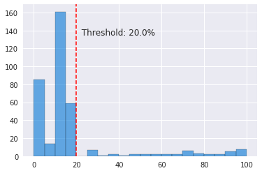

```python
#Histogram of the proportion of missing values per column
sns.set(style="darkgrid")
fig, ax = plt.subplots()
ax.hist(percent_missing_columns, bins=20, color='#1781D9', edgecolor='k', alpha=0.65)
ax.axvline(20, color='r', linestyle='dashed', linewidth=1.5)
vline=20
min_ylim, max_ylim = plt.ylim()
ax.text(vline, max_ylim*0.8, '  Threshold: {:.1f}%'.format(vline))
```

> As can be seen, the distribution of the percentages of missing values by columns indicates a preponderance of the number of variables with less than **`20 %`** missing values. Conversely, the number of variables with more than **`20 %`** missing values is negligible. I will therefore in the following project remove the variables with more than **`20 %`** missing values in the azdias and customers datasets.

```
Text(18,299407,'  Threshold: 18.0%')
```

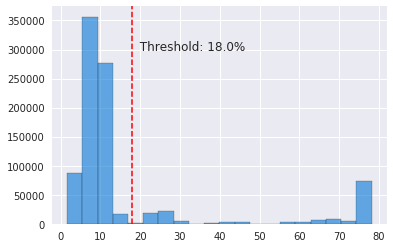

```python
#Histogram of the proportion of missing values per column
sns.set(style="darkgrid")
fig, ax = plt.subplots()
ax.hist(percent_missing_rows, bins=20, color='#1781D9', edgecolor='k', alpha=0.65)
ax.axvline(18, color='r', linestyle='dashed', linewidth=1.5)
vline=18
min_ylim, max_ylim = plt.ylim()
ax.text(vline, max_ylim*0.8, '  Threshold: {:.1f}%'.format(vline))
```

```python
# Let see which columns will be remove
columns_missing_to_drop=azdias.columns[percent_missing_columns > 20]
print(f'There are {len(list(columns_missing_to_drop))} variables with more that 20 % missing values')
print()
list(columns_missing_to_drop)
```

```
There are 47 variables with more that 20 % missing values
```

```
['AGER_TYP',
 'ALTER_HH',
 'ALTER_KIND1',
 'ALTER_KIND2',
 'ALTER_KIND3',
 'ALTER_KIND4',
 'ALTERSKATEGORIE_FEIN',
 'D19_BANKEN_ANZ_12',
 'D19_BANKEN_ANZ_24',
 'D19_BANKEN_DATUM',
 'D19_BANKEN_OFFLINE_DATUM',
 'D19_BANKEN_ONLINE_DATUM',
 'D19_BANKEN_ONLINE_QUOTE_12',
 'D19_GESAMT_ANZ_12',
 'D19_GESAMT_ANZ_24',
 'D19_GESAMT_DATUM',
 'D19_GESAMT_OFFLINE_DATUM',
 'D19_GESAMT_ONLINE_DATUM',
 'D19_GESAMT_ONLINE_QUOTE_12',
 'D19_KONSUMTYP',
 'D19_LETZTER_KAUF_BRANCHE',
 'D19_LOTTO',
 'D19_SOZIALES',
 'D19_TELKO_ANZ_12',
 'D19_TELKO_ANZ_24',
 'D19_TELKO_DATUM',
 'D19_TELKO_OFFLINE_DATUM',
 'D19_TELKO_ONLINE_DATUM',
 'D19_TELKO_ONLINE_QUOTE_12',
 'D19_VERSAND_ANZ_12',
 'D19_VERSAND_ANZ_24',
 'D19_VERSAND_DATUM',
 'D19_VERSAND_OFFLINE_DATUM',
 'D19_VERSAND_ONLINE_DATUM',
 'D19_VERSAND_ONLINE_QUOTE_12',
 'D19_VERSI_ANZ_12',
 'D19_VERSI_ANZ_24',
 'D19_VERSI_ONLINE_QUOTE_12',
 'EXTSEL992',
 'KBA05_ANTG1',
 'KBA05_ANTG2',
 'KBA05_ANTG3',
 'KBA05_ANTG4',
 'KBA05_BAUMAX',
 'KBA05_MAXVORB',
 'KK_KUNDENTYP',
 'TITEL_KZ']
```

```python
# remove azdias rows with more than 18 % of missing values
rows_to_remove = azdias.index[percent_missing_rows > 18]
azdias.drop(rows_to_remove, inplace=True,axis=0)
```

```python
print('azdias shape after the remove of {} rows: {}'.format(len(percent_missing_rows)-azdias.shape[0],azdias.shape))
```

```
azdias shape after the remove of 154229 rows: (736992, 366)
```

> 154229 rows with more than 18 percent of missing valeurs are droped from the inital azidas dataset In the end, I want to have the same variables in the azdias and customers datasets. For this I will identify the columns to delete and create a function that will then be applied to these datasets.

> The other treatment prior to the exploitation of the data within the framework of automatic learning is the recoding of the categorical variables. The categorical variables must be transformed into numerical variables. PCA is only applicable to numerical variables. I will transform categorical variables into dummy variables. But before doing that I will first remove variables with more than **`20 %`** missing values and categorical variables with more than 10 modalities. The reason for that is that converting to dummy variables increases the number of columns considerably because each modality of each categorical variable becomes a whole column.

```python
num_cols = list(azdias._get_numeric_data().columns)
cat_col  = list(set(azdias.columns) - set(num_cols))
```

```python
azdias.head()
```

|  | LNR | AGER_TYP | AKT_DAT_KL | ALTER_HH | ALTER_KIND1 | ALTER_KIND2 | ALTER_KIND3 | ALTER_KIND4 | ALTERSKATEGORIE_FEIN | ANZ_HAUSHALTE_AKTIV | ANZ_HH_TITEL | ANZ_KINDER | ANZ_PERSONEN | ANZ_STATISTISCHE_HAUSHALTE | ANZ_TITEL | ARBEIT | BALLRAUM | CAMEO_DEU_2015 | CAMEO_DEUG_2015 | CAMEO_INTL_2015 | CJT_GESAMTTYP | CJT_KATALOGNUTZER | CJT_TYP_1 | CJT_TYP_2 | CJT_TYP_3 | CJT_TYP_4 | CJT_TYP_5 | CJT_TYP_6 | D19_BANKEN_ANZ_12 | … |
| --- | --- | --- | --- | --- | --- | --- | --- | --- | --- | --- | --- | --- | --- | --- | --- | --- | --- | --- | --- | --- | --- | --- | --- | --- | --- | --- | --- | --- | --- | --- |
| 1 | 910220 | NaN | 9.0 | NaN | NaN | NaN | NaN | NaN | 21.0 | 11.0 | 0.0 | 0.0 | 2.0 | 12.0 | 0.0 | 3.0 | 6.0 | 8A | 8 | 51 | 5.0 | 1.0 | 5.0 | 5.0 | 2.0 | 3.0 | 1.0 | 1.0 | NaN | … |
| 2 | 910225 | NaN | 9.0 | 17.0 | NaN | NaN | NaN | NaN | 17.0 | 10.0 | 0.0 | 0.0 | 1.0 | 7.0 | 0.0 | 3.0 | 2.0 | 4C | 4 | 24 | 3.0 | 2.0 | 4.0 | 4.0 | 1.0 | 3.0 | 2.0 | 2.0 | NaN | … |
| 3 | 910226 | 2.0 | 1.0 | 13.0 | NaN | NaN | NaN | NaN | 13.0 | 1.0 | 0.0 | 0.0 | 0.0 | 2.0 | 0.0 | 2.0 | 4.0 | 2A | 2 | 12 | 2.0 | 3.0 | 2.0 | 2.0 | 4.0 | 4.0 | 5.0 | 3.0 | NaN | … |
| 4 | 910241 | NaN | 1.0 | 20.0 | NaN | NaN | NaN | NaN | 14.0 | 3.0 | 0.0 | 0.0 | 4.0 | 3.0 | 0.0 | 4.0 | 2.0 | 6B | 6 | 43 | 5.0 | 3.0 | 3.0 | 3.0 | 3.0 | 4.0 | 3.0 | 3.0 | 3.0 | … |
| 5 | 910244 | 3.0 | 1.0 | 10.0 | NaN | NaN | NaN | NaN | 10.0 | 5.0 | 0.0 | 0.0 | 1.0 | 2.0 | 0.0 | 2.0 | 6.0 | 8C | 8 | 54 | 2.0 | 5.0 | 2.0 | 1.0 | 5.0 | 5.0 | 3.0 | 3.0 | NaN | … |

```python
azdias_no_num=list(azdias.select_dtypes(include=['object']).columns)
for col in azdias_no_num:
    print(col)
print()
print("There are {} non numerical variables in the the demographics data".format(len(azdias_no_num)))
```

```
CAMEO_DEU_2015
CAMEO_DEUG_2015
CAMEO_INTL_2015
D19_LETZTER_KAUF_BRANCHE
EINGEFUEGT_AM
OST_WEST_KZ

There are 6 non numerical variables in the the demographics data
```

> As we can see in the above output, we have **`6`** variables that are not numerical variables in the **`demographics data`**. We will in the next step investigate to know what are their types.

> Some variables in the dataset are erroneously considered numeric when in reality they are categorical variables. So I'm going to isolate these variables and treat them as categorical variables. Taking this into account, we won't have **`6`** categorical variables but more.

```python
# By investigating the table of variable information I was able to identify the following variables as being non-numeric
categorical_vars = ['AGER_TYP', 'ANREDE_KZ', 'BIP_FLAG', 'CAMEO_DEU_2015', 'CAMEO_DEUINTL_2015', 'CJT_GESAMTTYP',
'D19_KONSUMTYP', 'D19_KK_KUNDENTYP', 'FINANZTYP', 'GEBAEUDETYP', 'GEBAEUDETYP_RASTER', 'GFK_URLAUBERTYP',
'HAUSHALTSSTRUKTUR', 'HEALTH_TYP', 'KBA05_HERSTTEMP', 'KBA05_MAXHERST', 'KBA05_MODTEMP', 'LP_FAMILIE_FEIN',
'LP_FAMILIE_GROB', 'LP_LEBENSPHASE_FEIN', 'LP_LEBENSPHASE_GROB', 'LP_STATUS_FEIN', 'LP_STATUS_GROB',
'NATIONALITAET_KZ', 'OST_WEST_KZ', 'PRAEGENDE_JUGENDJAHRE', 'SHOPPER_TYP', 'SOHO_FLAG', 'TITEL_KZ', 'VERS_TYP']
len(categorical_vars)
```

```
30
```

```python
# Let's analyze the previous variables to see if they are binary or multilevel.
# In the case where a variable is multilevel we will try to know if it has more or less than 10 modalities.
# The rest of the categorical variables will be converted is dummy variables
cols_to_drop=[]
for col in categorical_vars:
    if col in azdias.columns:
        if azdias[col].value_counts().shape[0] > 9 :
            cols_to_drop.append(col)
        print(azdias[col].value_counts())
print()
list(cols_to_drop)
```

```
2.0    87974
1.0    77262
3.0    24319
Name: AGER_TYP, dtype: int64
2.0    384103
1.0    352889
Name: ANREDE_KZ, dtype: int64
6B    53980
8A    50743
4C    43980
2D    32896
7A    32619
3C    32551
3D    32159
8B    31252
4A    30246
8C    30134
9D    26729
9B    25878
9C    22911
7B    22908
9A    20042
2C    17738
8D    16672
6E    15593
5D    14065
2B    14038
6C    13863
2A    11919
1D    11455
1A    10158
5A     9715
5B     9686
5C     9049
4B     8283
7C     8121
4D     8051
6A     6411
3A     5870
6D     5754
```

[output cut: 200 more lines]

```
Name: PRAEGENDE_JUGENDJAHRE, dtype: int64
1.0    222857
2.0    195616
3.0    160957
0.0    123596
Name: SHOPPER_TYP, dtype: int64
1.0    1740
5.0      94
4.0      47
3.0      41
2.0       2
Name: TITEL_KZ, dtype: int64
2.0    370125
1.0    332901
Name: VERS_TYP, dtype: int64
```

```
['CAMEO_DEU_2015',
 'GFK_URLAUBERTYP',
 'LP_FAMILIE_FEIN',
 'LP_LEBENSPHASE_FEIN',
 'LP_LEBENSPHASE_GROB',
 'LP_STATUS_FEIN',
 'PRAEGENDE_JUGENDJAHRE']
```

```python
## The modalities of the variable OST_WEST_KZ are coded in W and O. I will recode them in 1 and 0
azdias['OST_WEST_KZ'].replace(['W','O'],[1,0], inplace=True)
azdias['OST_WEST_KZ'].value_counts()
```

```
1    582040
0    154952
Name: OST_WEST_KZ, dtype: int64
```

```python
cols_to_dummy=(set(categorical_vars)-set(cols_to_drop))
columns_to_drop =list(columns_missing_to_drop) + list(cols_to_drop)
len(columns_to_drop)
```

```
54
```

```python
azdias.drop(columns_to_drop, inplace=True, axis=1)
```

```python
azdias.shape
```

```
(736992, 312)
```

> Now let convert to dummy the rest of the categorical variables

```python
for col in cols_to_dummy:
    if col in azdias.columns:
        dummy = pd.get_dummies(azdias[col], prefix = col)
        azdias = pd.concat([azdias, dummy], axis = 1)
```

```python
print(f'Shape after dummy variables creation:  {azdias.shape}')
# Let remove the orignal variables from which we have created the dummies
for col in cols_to_dummy:
     if col in azdias.columns:
            azdias.drop(col, inplace=True, axis=1)
print()
print(f'Shape after removing the orignal variables from which we have created the dummies  :  {azdias.shape}')
```

```
Shape after dummy variables creation:  (736992, 379)

Shape after removing the orignal variables from which we have created the dummies  :  (736992, 364)
```

```python
# let save the azdias dataframe that we have process into csv as it take more time
azdias.to_csv('clean_azdias.csv',index=False)
```

```python
df_unknowns.to_csv('df_unknows.csv',index=False)
pd.DataFrame(columns_to_drop, columns=['columns_to_drop']).to_csv('columns_to_drop.csv', index=False)
pd.DataFrame(columns_to_drop, columns=['cols_to_dummy']).to_csv('cols_to_dummy.csv', index=False)
```

[output not shown]

```python
columns_to_drop=pd.read_csv('columns_to_drop.csv')
cols_to_dummy= pd.read_csv('cols_to_dummy.csv')
```

### Creation of a data cleaning function

> After performing step-by-step processing on the azdias dataset, it would be wise to capitalize on this work by creating a function that would allow the same processing to be applied to the other datasets. This is what I will do in the next step.

```python
def data_cleaning(df_to_clean, df_vars_unknowns):
    """
    Perform feature trimming, re-encoding, and engineering for demographics
    data

    INPUT:
        df_to_clean: Customer demographics DataFrame
        df_vars_unknowns: Unknowns DataFrame
    OUTPUT: Trimmed and cleaned demographics DataFrame
    """
    for col in df_to_clean.columns:
        if df_to_clean[col].dtype == np.int64:
            df_to_clean[col] = df_to_clean[col].astype(np.float64)

    # convert missing value codes into NaNs, ...
    for row in df_vars_unknowns['Attribute']:
        if row in df_to_clean.columns:
            na_map = df_vars_unknowns.loc[df_vars_unknowns['Attribute'] == row, 'Unknown'].iloc[0]
            na_idx = df_to_clean.loc[:, row].isin(na_map)
            df_to_clean.loc[na_idx, row] = np.NaN
        else:
            continue

    # Remove columns which have more than 20 %  missing values in the azdias dataframe
    columns_to_drop = pd.read_csv('columns_to_drop.csv')
    cols_to_drop    =list(columns_to_drop['columns_to_drop'])
    for col in cols_to_drop:
        if col in df_to_clean.columns:
            del df_to_clean[col]
    # Remove rows which have  more than 18 % missing values in azdias dataframe.
    percent_missing_rows =(df_to_clean.isna().sum(axis=1)/df_to_clean.shape[1])*100
    rows_to_drop = df_to_clean.index[percent_missing_rows > 18]
    df_to_clean.drop(rows_to_drop, axis=0, inplace = True)

    # select, re-encode, and engineer column values
    df_to_clean['OST_WEST_KZ'].replace(['W', 'O'], [1, 0], inplace=True)

    cols_to_dummy = list(pd.read_csv('cols_to_dummy.csv').cols_to_dummy)

    for col in cols_to_dummy:
        dummy = pd.get_dummies(df_to_clean[col], prefix = col)
        df_to_clean = pd.concat([df_to_clean, dummy], axis = 1)

    df_to_clean.drop(cols_to_dummy, axis=1, inplace = True)
    return df_to_clean
```

To be on the same perimeter as the **`azdias`** dataset, I will drop the three extra columns ('CUSTOMER_GROUP', 'ONLINE_PURCHASE', and 'PRODUCT_GROUP') of the **`customers`** dataset

```python
customers=pd.read_csv('arvato_data/Udacity_CUSTOMERS_052018.csv', sep=';')
for col in ['CUSTOMER_GROUP', 'ONLINE_PURCHASE',  'PRODUCT_GROUP']:
    del customers[col]
```

```python
customers.shape
```

```
(191652, 366)
```

```python
#Let apply the data_cleaning function to the customers dataset
clean_customers = data_cleaning(customers, df_unknowns)
```

```python
clean_customers.head()
clean_customers.shape
```

```
(134430, 312)
```

```python
clean_azdias=pd.read_csv('clean_azdias.csv')
```

```python
# Determine the columns that are in the cleaned customers dataframe
# but not the cleaned azdias dataframe (these 3 are expected)
uncommon1=list(clean_customers.columns[~clean_customers.columns.isin(clean_azdias.columns)])
```

```python
# Determine the columns that are in the cleaned azdias dataframe
# but not the cleaned customers dataframe
uncommon2=list(clean_azdias.columns[~clean_azdias.columns.isin(clean_customers.columns)])
```

let remove the columns that are not common to both datasets

```python
for col in uncommon1:
    del clean_customers[col]
for col in uncommon2:
    del clean_azdias[col]
```

```python
clean_customers.columns[~clean_customers.columns.isin(clean_azdias.columns)]
```

```
Index([], dtype='object')
```

```python
clean_azdias.columns[~clean_azdias.columns.isin(clean_customers.columns)]
```

```
Index([], dtype='object')
```

```python
for col in ['CAMEO_DEUG_2015','CAMEO_INTL_2015','EINGEFUEGT_AM']:
    print(clean_azdias[col].value_counts())
```

```
8      70361
8.0    58440
6      55172
9      54349
4      52290
6.0    45477
9.0    45052
4.0    43273
2      41962
3      41846
7      39477
2.0    34629
3.0    34441
7.0    32972
5      27303
5.0    22391
1      18687
1.0    15533
X        283
Name: CAMEO_DEUG_2015, dtype: int64
51      69036
51.0    57225
41      47553
24      46443
41.0    39226
24.0    38139
14      31965
43      29670
14.0    26496
43.0    24310
54      23147
25      20303
54.0    19535
25.0    16859
22      16505
22.0    13741
45      13600
13      13314
45.0    11415
55      11121
```

[output cut: 71 more lines]

```
1999-03-01 00:00:00         1
1999-08-25 00:00:00         1
2004-11-01 00:00:00         1
2001-12-14 00:00:00         1
1999-05-19 00:00:00         1
1993-11-30 00:00:00         1
1999-12-15 00:00:00         1
1997-05-02 00:00:00         1
2000-07-17 00:00:00         1
1993-02-15 00:00:00         1
1999-05-05 00:00:00         1
1994-05-30 00:00:00         1
2000-02-18 00:00:00         1
1999-10-18 00:00:00         1
Name: EINGEFUEGT_AM, Length: 2819, dtype: int64
```

```python
# As we can see in the ouput above, the columns CAMEO_DEUG_2015 and CAMEO_INTL_2015
# have string values of "X" and "XX" and  EINGEFUEGT_AM has a similar issue. I will remove these columns
# in order to perform the next steps
for col in ['CAMEO_DEUG_2015','CAMEO_INTL_2015','EINGEFUEGT_AM']:
    del clean_azdias[col]
    del clean_customers[col]
```

```python
print(f'final customers shape: {clean_customers.shape}')
print()
print(f'final azidas shape: {clean_azdias.shape}')
```

```
final customers shape: (134430, 294)

final azidas shape: (736992, 294)
```

```python
# Impute the missing values using the mean as
imputer = Imputer(strategy='mean')
clean_azdias = pd.DataFrame(imputer.fit_transform(clean_azdias), columns = clean_azdias.columns)
clean_customers = pd.DataFrame(imputer.transform(clean_customers), columns = clean_customers.columns)
```

```python
# scalling
scaler = StandardScaler()
clean_azdias = pd.DataFrame(scaler.fit_transform(clean_azdias), columns = clean_azdias.columns)
clean_customers = pd.DataFrame(scaler.fit_transform(clean_customers), columns = clean_customers.columns)
```

```python
clean_azdias.head()
```

|  | LNR | AKT_DAT_KL | ANZ_HAUSHALTE_AKTIV | ANZ_HH_TITEL | ANZ_KINDER | ANZ_PERSONEN | ANZ_STATISTISCHE_HAUSHALTE | ANZ_TITEL | ARBEIT | BALLRAUM | CJT_KATALOGNUTZER | CJT_TYP_1 | CJT_TYP_2 | CJT_TYP_3 | CJT_TYP_4 | CJT_TYP_5 | CJT_TYP_6 | D19_BANKEN_DIREKT | D19_BANKEN_GROSS | D19_BANKEN_LOKAL | D19_BANKEN_REST | D19_BEKLEIDUNG_GEH | D19_BEKLEIDUNG_REST | D19_BILDUNG | D19_BIO_OEKO | D19_BUCH_CD | D19_DIGIT_SERV | D19_DROGERIEARTIKEL | D19_ENERGIE | … |
| --- | --- | --- | --- | --- | --- | --- | --- | --- | --- | --- | --- | --- | --- | --- | --- | --- | --- | --- | --- | --- | --- | --- | --- | --- | --- | --- | --- | --- | --- | --- |
| 0 | 1.057678 | 1.262163 | 0.186905 | -0.125867 | -0.29911 | 0.224505 | 0.335500 | -0.060673 | -0.179348 | 0.850314 | -1.502099 | 1.286301 | 1.396088 | -0.919905 | -0.187288 | -1.646742 | -1.802270 | -0.466554 | -0.362087 | -0.136557 | -0.292971 | -0.315529 | -0.530296 | -0.311717 | -0.216741 | -0.664970 | -0.197166 | -0.400004 | -0.273441 | … |
| 1 | 1.057698 | 1.262163 | 0.120714 | -0.125867 | -0.29911 | -0.634591 | -0.031798 | -0.060673 | -0.179348 | -0.980218 | -0.825742 | 0.544754 | 0.671875 | -1.645955 | -0.187288 | -0.908571 | -1.046415 | -0.466554 | -0.362087 | -0.136557 | -0.292971 | -0.315529 | -0.530296 | 3.191421 | -0.216741 | -0.664970 | -0.197166 | -0.400004 | -0.273441 | … |
| 2 | 1.057702 | -0.934352 | -0.475010 | -0.125867 | -0.29911 | -1.493687 | -0.399097 | -0.060673 | -1.185227 | -0.064952 | -0.149385 | -0.938340 | -0.776551 | 0.532196 | 0.554441 | 1.305939 | -0.290560 | -0.466554 | -0.362087 | -0.136557 | -0.292971 | -0.315529 | -0.530296 | -0.311717 | -0.216741 | 1.621491 | -0.197166 | -0.400004 | -0.273441 | … |
| 3 | 1.057760 | -0.934352 | -0.342627 | -0.125867 | -0.29911 | 1.942698 | -0.325637 | -0.060673 | 0.826531 | -0.980218 | -0.149385 | -0.196793 | -0.052338 | -0.193855 | 0.554441 | -0.170401 | -0.290560 | 0.013779 | 0.811855 | -0.136557 | 3.546392 | 3.445421 | -0.102628 | 3.191421 | -0.216741 | 1.621491 | -0.197166 | 0.152403 | 3.292342 | … |
| 4 | 1.057771 | -0.934352 | -0.210244 | -0.125867 | -0.29911 | -0.634591 | -0.399097 | -0.060673 | -1.185227 | 0.850314 | 1.203329 | -0.938340 | -1.500764 | 1.258246 | 1.296171 | -0.170401 | -0.290560 | -0.466554 | -0.362087 | -0.136557 | -0.292971 | -0.315529 | -0.530296 | -0.311717 | -0.216741 | -0.664970 | -0.197166 | -0.400004 | 1.866029 | … |

```python
clean_customers.head()
```

|  | LNR | AKT_DAT_KL | ANZ_HAUSHALTE_AKTIV | ANZ_HH_TITEL | ANZ_KINDER | ANZ_PERSONEN | ANZ_STATISTISCHE_HAUSHALTE | ANZ_TITEL | ARBEIT | BALLRAUM | CJT_KATALOGNUTZER | CJT_TYP_1 | CJT_TYP_2 | CJT_TYP_3 | CJT_TYP_4 | CJT_TYP_5 | CJT_TYP_6 | D19_BANKEN_DIREKT | D19_BANKEN_GROSS | D19_BANKEN_LOKAL | D19_BANKEN_REST | D19_BEKLEIDUNG_GEH | D19_BEKLEIDUNG_REST | D19_BILDUNG | D19_BIO_OEKO | D19_BUCH_CD | D19_DIGIT_SERV | D19_DROGERIEARTIKEL | D19_ENERGIE | … |
| --- | --- | --- | --- | --- | --- | --- | --- | --- | --- | --- | --- | --- | --- | --- | --- | --- | --- | --- | --- | --- | --- | --- | --- | --- | --- | --- | --- | --- | --- | --- |
| 0 | -1.559594 | -0.368334 | -0.275728 | -0.126521 | -0.265213 | -0.206644 | -0.25881 | -0.134632 | -1.815082 | -0.611897 | 0.192630 | -0.965624 | -0.871759 | 0.663425 | 0.685418 | 0.657380 | 0.616024 | -0.427116 | -0.342204 | -0.167318 | -0.333951 | -0.555336 | -0.727321 | -0.539186 | -0.36141 | 0.968642 | -0.230847 | -0.481111 | -0.366976 | … |
| 1 | 0.864732 | -0.368334 | -0.275728 | -0.126521 | -0.265213 | -0.921312 | -0.25881 | -0.134632 | 0.167365 | 1.278255 | 0.893533 | -0.006068 | 0.162391 | 0.663425 | 0.685418 | 0.657380 | 0.616024 | -0.427116 | -0.342204 | -0.167318 | -0.333951 | -0.555336 | -0.727321 | 1.889998 | -0.36141 | -1.154260 | -0.230847 | -0.481111 | -0.366976 | … |
| 2 | 0.864750 | -0.368334 | -0.348343 | -0.049185 | -0.265213 | -1.635980 | -0.25881 | -0.134632 | -1.815082 | 1.278255 | 0.893533 | -0.965624 | -0.871759 | 0.663425 | 0.685418 | 0.657380 | 0.616024 | -0.427116 | -0.342204 | -0.167318 | -0.333951 | -0.555336 | -0.727321 | -0.539186 | -0.36141 | 0.968642 | -0.230847 | -0.481111 | -0.366976 | … |
| 3 | 0.864768 | -0.368334 | 0.159963 | -0.126521 | -0.265213 | 1.222692 | 0.18288 | -0.134632 | 0.167365 | -0.611897 | 0.192630 | 0.953489 | 1.196540 | -1.479703 | -0.228723 | -1.390073 | -1.480651 | 2.087303 | -0.342204 | 2.743967 | -0.333951 | -0.555336 | 1.433864 | -0.539186 | -0.36141 | -0.446626 | -0.230847 | 1.443663 | -0.366976 | … |
| 4 | 0.865021 | -0.368334 | -0.275728 | -0.126521 | -0.265213 | -0.206644 | -0.25881 | -0.134632 | 0.167365 | 1.278255 | -0.508272 | -0.965624 | -0.871759 | 0.663425 | 0.685418 | 0.657380 | 0.616024 | -0.427116 | -0.342204 | -0.167318 | -0.333951 | -0.555336 | 1.433864 | -0.539186 | -0.36141 | 0.614825 | -0.230847 | -0.481111 | -0.366976 | … |

> I impute the missing data using the average of each column to replace the missing value. This sounds very basic. However I tried to use the median and the nearest neighbor K method but I'm dealing with a memory problem. When I execute the code I get a MemoryError error. After the imputation I standardize the features by using the **`sklearn StandardScaler()`**. The goal is to give the same importance to all the features.

## Part 1: Customer Segmentation Report

The main bulk of your analysis will come in this part of the project. Here, you should use unsupervised learning techniques to describe the relationship between the demographics of the company's existing customers and the general population of Germany. By the end of this part, you should be able to describe parts of the general population that are more likely to be part of the mail-order company's main customer base, and which parts of the general population are less so.

#### PCA

> We've done the hard work of cleaning, preparation and transformation of the data. Now it's time to perform the unsupervised learning model, the PCA in our case.

```python
def make_pca(n_components, dataset):
    '''
    Transforms data using PCA to create n_components, and provides back the results of the
    transformation.

    INPUT: n_components - int - the number of principal components to create
           dataset - the dataset you would like to transform. This dataset must be cleaned and standardize before performing
           the PCA

    OUTPUT: pca - the pca object created after fitting the data
            fit_pca - the transformed  matrix with new number of components
    '''
    pca = PCA(n_components, svd_solver='full')
    fit_pca = pca.fit_transform(dataset)
    return pca, fit_pca
```

```python
## Let apply this the make_pca function to the azdias cleaned dataset
n_components= clean_azdias.shape[1] -1
azdias_pca, azdias_fit_pca= make_pca(n_components,clean_azdias)
```

```python
# The number of component
print('The number of components computed by the PCA model:  {}'.format(azdias_pca.n_components_))
```

```
The number of components computed by the PCA model:  293
```

```python
# The explained variance per compement
print(f'The explained variance per compement: {azdias_pca.explained_variance_}')
```

```
The explained variance per compement: [  2.41938981e+01   1.72476608e+01   1.35674154e+01   9.54871435e+00
   8.01842393e+00   6.53981087e+00   6.07643207e+00   5.82414210e+00
   5.15136015e+00   4.86629739e+00   4.46057555e+00   3.97900248e+00
   3.49558329e+00   3.31589406e+00   3.16694743e+00   3.03556545e+00
   2.85287261e+00   2.71320055e+00   2.66408027e+00   2.61028373e+00
   2.37712386e+00   2.32365831e+00   2.23562330e+00   2.12913215e+00
   2.06724692e+00   2.00360964e+00   1.98031799e+00   1.87850980e+00
   1.82896060e+00   1.80609831e+00   1.75340386e+00   1.74004611e+00
   1.67865434e+00   1.64509105e+00   1.56591395e+00   1.53379654e+00
   1.49250633e+00   1.47292916e+00   1.44166037e+00   1.42922567e+00
   1.39014058e+00   1.37701503e+00   1.37093175e+00   1.32960073e+00
   1.32859369e+00   1.30826640e+00   1.29422627e+00   1.24802136e+00
   1.24404053e+00   1.21390820e+00   1.20182050e+00   1.16878700e+00
   1.15800040e+00   1.13875058e+00   1.13122574e+00   1.12073514e+00
   1.11940819e+00   1.10721221e+00   1.07885349e+00   1.07322435e+00
   1.06385601e+00   1.05022115e+00   1.03420675e+00   1.02192355e+00
   1.02116493e+00   1.01274147e+00   1.00006994e+00   9.89396028e-01
   9.73747537e-01   9.69778643e-01   9.59146481e-01   9.58341081e-01
   9.43175803e-01   9.36836880e-01   9.31638251e-01   9.28757773e-01
   9.19969327e-01   9.11709771e-01   9.02310582e-01   8.98649679e-01
   8.91725908e-01   8.87852737e-01   8.75996249e-01   8.72036065e-01
   8.65908823e-01   8.62243904e-01   8.54727510e-01   8.50451831e-01
   8.43404358e-01   8.36766311e-01   8.34616819e-01   8.27623074e-01
   8.26046701e-01   8.16220175e-01   8.12546735e-01   8.05548398e-01
   7.97667216e-01   7.87363343e-01   7.82214084e-01   7.79488995e-01
   7.71247718e-01   7.67341811e-01   7.65559239e-01   7.52216255e-01
   7.50407410e-01   7.42861039e-01   7.34489828e-01   7.32050512e-01
   7.29668147e-01   7.23134568e-01   7.15616448e-01   7.11630498e-01
   7.04180064e-01   7.02523824e-01   6.91433861e-01   6.87264871e-01
   6.81629908e-01   6.78555952e-01   6.72619927e-01   6.68570672e-01
   6.66637216e-01   6.62131099e-01   6.59636850e-01   6.55214631e-01
   6.53398583e-01   6.48384408e-01   6.41263939e-01   6.36163030e-01
   6.28276862e-01   6.27770412e-01   6.22643064e-01   6.08727067e-01
   6.03703473e-01   5.97475372e-01   5.95148953e-01   5.90406772e-01
   5.73658567e-01   5.72425681e-01   5.67383967e-01   5.63089588e-01
   5.59712468e-01   5.57715246e-01   5.54085674e-01   5.48310549e-01
   5.42240454e-01   5.37460575e-01   5.32286432e-01   5.29964575e-01
   5.26961505e-01   5.14243087e-01   5.10897242e-01   5.03773079e-01
   5.00548151e-01   4.90187369e-01   4.85459936e-01   4.81843271e-01
   4.66037782e-01   4.63313980e-01   4.57960392e-01   4.52513027e-01
```

[output cut: 19 more lines]

```
   1.56027556e-01   1.53344159e-01   1.50610075e-01   1.47745702e-01
   1.44738227e-01   1.40064421e-01   1.39322310e-01   1.38602262e-01
   1.34618655e-01   1.33398969e-01   1.30573572e-01   1.30437177e-01
   1.28017564e-01   1.26930943e-01   1.22813763e-01   1.19540380e-01
   1.16387074e-01   1.14143410e-01   1.13626735e-01   1.12918500e-01
   1.11295072e-01   1.10578266e-01   1.08885326e-01   1.05100140e-01
   1.02504296e-01   1.01444371e-01   9.83655202e-02   9.70124318e-02
   9.69365593e-02   9.52298132e-02   9.16033936e-02   8.98723702e-02
   8.82023997e-02   8.73577299e-02   8.51398282e-02   8.43293460e-02
   8.22250251e-02   8.01208566e-02   7.93814502e-02   7.83612049e-02
   7.74720649e-02   7.64036163e-02   7.61605199e-02   7.52306867e-02
   7.44134019e-02   7.38867932e-02   7.35370916e-02   6.89804024e-02
   6.81714847e-02   5.26524990e-02   4.47046099e-02   4.40012502e-02
   4.26114995e-02   3.80473554e-02   3.43312196e-02   1.93132086e-02
   1.73355284e-02]
```

```python
### Let create a function to plot the scree
def scree_plot(pca, fit_pca,*args, **kwargs):
    #scree plot
    plt.style.use('ggplot')
    n= fit_pca.shape[0]
    p= fit_pca.shape[1]
    eigval = pca.singular_values_**2/n
    plt.figure(figsize=(15,10))
    plt.subplot(211)
    vline=kwargs.get('vline', None)
    #plt.rcParams["figure.figsize"] = (18,20)
    plt.plot(np.arange(1,p+1),eigval, 'r--')
    plt.plot(np.arange(1,p+1),eigval, 'bo')
    plt.title("Scree plot")
    plt.ylabel("Eigen values")
    plt.xlabel("Factor number")
    plt.xticks(np.arange(0, 300, 10.0))
    if vline:
        min_ylim, max_ylim = plt.ylim()
        plt.axvline(vline, color='g', linestyle='dashed', linewidth=1.)
        plt.text(vline, max_ylim*0.8, '  Threshold: {:.1f}'.format(vline))


    # The graph of the cumulative variance restored according to the number of factors
    plt.subplot(212)
    plt.plot(np.arange(1,p+1),np.cumsum(pca.explained_variance_ratio_),'r--')
    plt.plot(np.arange(1,p+1),np.cumsum(pca.explained_variance_ratio_),'bo')
    plt.title("Explained variance vs. # of factors")
    plt.ylabel("Cumsum explained variance ratio")
    plt.xlabel("Factor number")
    plt.show()
    plt.savefig('scree_plot1.png')

   #===========================================================================================
def scree_plot2(pca):
    '''
    Creates a scree plot associated with the principal components

    INPUT: pca - the result of instantian of PCA in scikit learn

    OUTPUT:
            None
    '''
    num_components = len(pca.explained_variance_ratio_)
    ind = np.arange(num_components)
    vals = pca.explained_variance_ratio_

    plt.figure(figsize=(15,10))
    ax = plt.subplot(111)
    cumvals = np.cumsum(vals)
    ax.bar(ind, vals)
    ax.plot(ind, cumvals,'r--')
    for i in range(num_components):
        ax.annotate(r"%s%%" % ((str(vals[i]*100)[:4])), (ind[i]+0.2, vals[i]), va="bottom", ha="center", fontsize=12)
    ax.xaxis.set_tick_params(width=0)
    ax.yaxis.set_tick_params(width=2, length=12)

    ax.set_xlabel("Principal Component")
    ax.set_ylabel("Variance Explained (%)")
    plt.title('Explained Variance Per Principal Component')
    plt.savefig('scree_plot2.png')
```

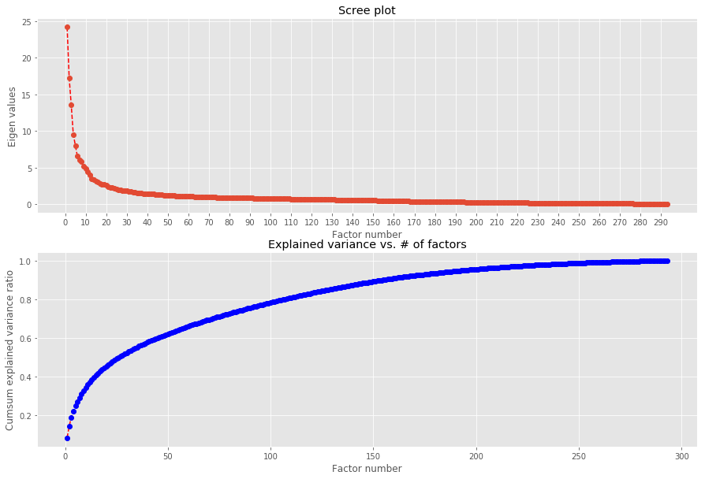

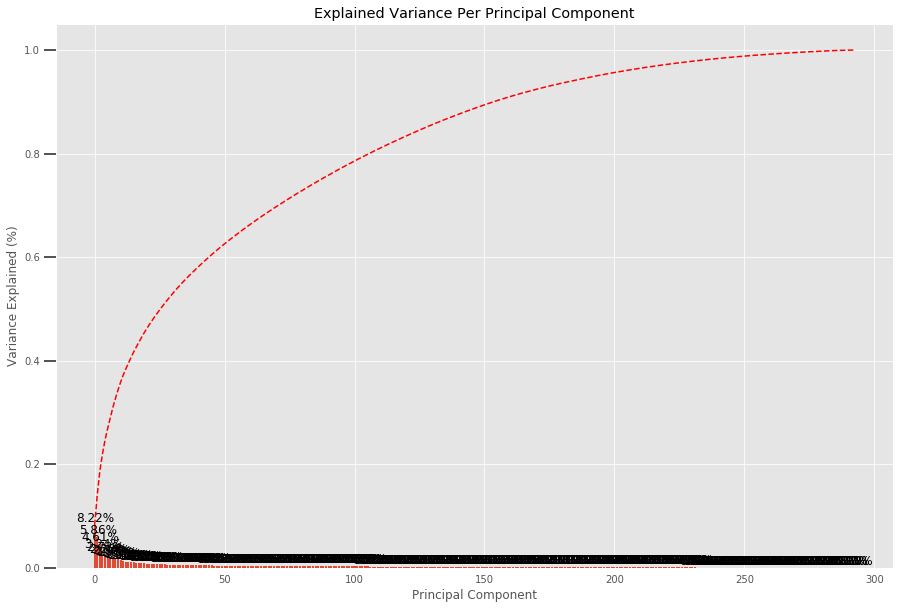

```python
scree_plot(azdias_pca, azdias_fit_pca)
scree_plot2(azdias_pca)
```

> In the first graph, we can see that the change of the eigenvalue curve is made from p= 12 principal components. But when we see variance cumulative curve we notice that with 12 principal components we capture less than 50 % on the variance. Later we will chose more than 12 compement to have at least 90 % of variance.

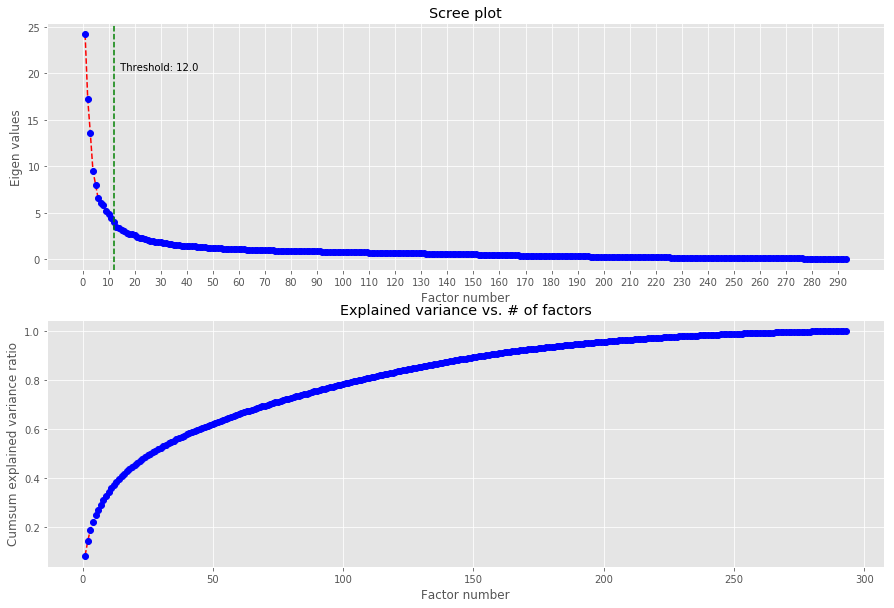

```python
scree_plot(azdias_pca, azdias_fit_pca, vline=12)
```

I we use the **`optimal_n_componemt`** I define above to target at least 90 % of cumulative variance and show how many componement to keep.

```python
def optimal_n_componemt(pca, min_variance):

    ''' return the minimal number of the first most important components that
        able to capture at least nin_variance

        INPUT: pca - the result of instantian of PCA in scikit learn
               min_variance: the minimum of cumulative variance we want to target

        OUTPUT: The optimal number of component

    '''
    cum_var=np.cumsum(pca.explained_variance_ratio_)
    L1=len(azdias_pca.explained_variance_ratio_)
    L2=len(azdias_pca.explained_variance_ratio_[cum_var > min_variance])
    return L1-L2 + 1
```

```python
# Apply optimal_n_componemt with nim_variance =90%
optim_component=optimal_n_componemt(azdias_pca, 0.90)
print(optim_component)
```

```
155
```

Let perform a 155 componemt PCA on the azdias dataset

```python
azdias_pca_155, azdias_fit_pca_155=make_pca(optim_component, clean_azdias)
```

```python
#=======================================================================================================
def get_important_features(transformed_features, components_, columns):
    """
    This function will return the most "important"
    features so we can determine which have the most
    effect on multi-dimensional scaling
    """
    num_columns = len(columns)

    # Scale the principal components by the max value in
    # the transformed set belonging to that component
    xvector = components_[0] * max(transformed_features[:,0])
    yvector = components_[1] * max(transformed_features[:,1])

    # Sort each column by it's length. These are your *original*
    # columns, not the principal components.
    important_features = { columns[i] : math.sqrt(xvector[i]**2 + yvector[i]**2) for i in range(num_columns) }
    important_features = sorted(zip(important_features.values(), important_features.keys()), reverse=True)
    print("Features by importance:\n", important_features)
    return important_features
```

##### Interpreting Components

Before the Kmeans clustering, I will try to find an interpretation of the components, at least the most important ones.

```python
main_features=get_important_features(azdias_fit_pca_155, azdias_pca_155.components_, clean_azdias.columns.values)
```

```
Features by importance:
 [(3.129090070729175, 'KBA13_HERST_BMW_BENZ'), (2.6842856091654017, 'KBA13_MERCEDES'), (2.6728354077317675, 'KBA13_SEG_OBEREMITTELKLASSE'), (2.6187585888080425, 'EWDICHTE'), (2.605511250972791, 'KBA13_BMW'), (2.5437577071785475, 'KBA13_SITZE_5'), (2.4832330185919966, 'ORTSGR_KLS9'), (2.4574916647013…
```

```python
# print the top 10 main features
L=[main_features[feature][1] for feature in range(10)]
print('The 10 main features are:\n')
for i in L:
    print(i)
```

```
The 10 main features are:

KBA13_HERST_BMW_BENZ
KBA13_MERCEDES
KBA13_SEG_OBEREMITTELKLASSE
EWDICHTE
KBA13_BMW
KBA13_SITZE_5
ORTSGR_KLS9
KBA13_SITZE_4
PLZ8_ANTG3
KBA13_ANTG3
```

```python
#=================================================================================================================
# Map weights for the first principal component to corresponding feature names
# and then print the linked values, sorted by weight.
# The pca_results function was taken from the class notes and altered

def pca_results(clean_dataset, pca, component_number):
    '''
    Create a DataFrame of the PCA results
    Includes dimension feature weights and explained variance
    Visualizes the PCA results where figure 1 shows all features sorted
    and figure 2 shows the top 3 negative and positive features.
    '''

    # Dimension indexing
    dimensions = dimensions = ['Dimension {}'.format(i) for i in range(1,len(pca.components_)+1)]

    # PCA components
    components = pd.DataFrame(np.round(pca.components_, 4), columns = clean_dataset.keys())
    components.index = dimensions

    # PCA explained variance
    ratios = pca.explained_variance_ratio_.reshape(len(pca.components_), 1)
    variance_ratios = pd.DataFrame(np.round(ratios, 4), columns = ['Explained Variance'])
    variance_ratios.index = dimensions

    # Create a bar plot visualization for 1st figure (all columns sorted)
    fig1, ax1 = plt.subplots(figsize = (15,8))

    # Plot the feature weights as a function of the components
    components.iloc[component_number-1, :].sort_values().plot(ax = ax1, kind = 'bar');
    ax1.set_ylabel("Feature Weights")
    ax1.set_xticklabels(components.iloc[component_number-1, :].sort_values().index, rotation=90)

    # Create a bar plot visualization for 2nd figure (top and bottom 3 columns)
    fig2, ax2 = plt.subplots(figsize = (6,3))

    # Plot the feature weights as a function of the components
    components.iloc[component_number-1, :].sort_values().iloc[[0, 1, 2, -3, -2, -1]].plot(ax = ax2, kind = 'bar');
    ax2.set_ylabel("Feature Weights")
    ax2.set_xticklabels(components.iloc[component_number-1, :].sort_values().index, rotation=90)

    # Return a concatenated DataFrame
    return pd.concat([variance_ratios, components], axis = 1)
```

|  | Explained Variance | LNR | AKT_DAT_KL | ANZ_HAUSHALTE_AKTIV | ANZ_HH_TITEL | ANZ_KINDER | ANZ_PERSONEN | ANZ_STATISTISCHE_HAUSHALTE | ANZ_TITEL | ARBEIT | BALLRAUM | CJT_KATALOGNUTZER | CJT_TYP_1 | CJT_TYP_2 | CJT_TYP_3 | CJT_TYP_4 | CJT_TYP_5 | CJT_TYP_6 | D19_BANKEN_DIREKT | D19_BANKEN_GROSS | D19_BANKEN_LOKAL | D19_BANKEN_REST | D19_BEKLEIDUNG_GEH | D19_BEKLEIDUNG_REST | D19_BILDUNG | D19_BIO_OEKO | D19_BUCH_CD | D19_DIGIT_SERV | D19_DROGERIEARTIKEL | … |
| --- | --- | --- | --- | --- | --- | --- | --- | --- | --- | --- | --- | --- | --- | --- | --- | --- | --- | --- | --- | --- | --- | --- | --- | --- | --- | --- | --- | --- | --- | --- |
| Dimension 1 | 0.0823 | -0.0311 | 0.0611 | 0.0848 | 0.0191 | -0.0213 | -0.0661 | 0.0835 | -0.0028 | 0.1076 | -0.0765 | 0.0187 | 0.0551 | 0.0782 | -0.0714 | -0.0349 | -0.0691 | -0.0531 | -0.0243 | -0.0149 | -0.0224 | -0.0266 | -0.0394 | -0.0454 | -0.0430 | -0.0345 | -0.0547 | -0.0148 | -0.0362 | … |
| Dimension 2 | 0.0587 | 0.0777 | 0.0127 | 0.0218 | 0.0274 | -0.0051 | -0.0145 | 0.0208 | 0.0113 | -0.0337 | -0.0906 | -0.0054 | 0.0106 | 0.0227 | -0.0276 | -0.0029 | -0.0098 | -0.0137 | -0.0082 | -0.0039 | -0.0087 | -0.0016 | 0.0142 | -0.0043 | -0.0101 | -0.0051 | -0.0134 | 0.0025 | -0.0064 | … |
| Dimension 3 | 0.0461 | -0.0266 | -0.0505 | 0.0169 | 0.0168 | -0.0742 | -0.0436 | 0.0199 | 0.0082 | 0.0425 | -0.0151 | 0.1530 | -0.2221 | -0.2167 | 0.1921 | 0.1959 | 0.2048 | 0.1909 | -0.0582 | -0.0477 | -0.0124 | -0.0373 | -0.0125 | -0.0365 | -0.0062 | -0.0122 | -0.0123 | -0.0251 | -0.0496 | … |
| Dimension 4 | 0.0325 | -0.0714 | -0.1167 | 0.0078 | 0.0108 | 0.0639 | 0.1427 | 0.0082 | 0.0106 | 0.0873 | -0.0473 | -0.0804 | -0.0057 | -0.0025 | -0.0106 | -0.0278 | -0.0035 | -0.0141 | 0.1146 | 0.0844 | 0.0399 | 0.0918 | 0.1012 | 0.1323 | 0.0942 | 0.0895 | 0.1408 | 0.0657 | 0.1243 | … |
| Dimension 5 | 0.0273 | -0.1082 | 0.0621 | 0.0126 | 0.0099 | -0.0214 | -0.0650 | 0.0154 | -0.0009 | 0.0628 | 0.0561 | 0.0030 | 0.0341 | 0.0299 | -0.0259 | -0.0222 | -0.0362 | -0.0184 | -0.0448 | -0.0334 | -0.0193 | -0.0400 | -0.0452 | -0.0512 | -0.0437 | -0.0443 | -0.0554 | -0.0313 | -0.0495 | … |
| Dimension 6 | 0.0222 | -0.0083 | -0.0207 | 0.0256 | 0.0054 | 0.0082 | 0.0261 | 0.0238 | 0.0004 | -0.0469 | 0.0242 | 0.0309 | -0.0329 | -0.0359 | 0.0385 | 0.0222 | 0.0336 | 0.0338 | 0.0062 | 0.0029 | 0.0127 | 0.0055 | 0.0004 | 0.0048 | 0.0149 | 0.0134 | 0.0077 | 0.0026 | 0.0049 | … |
| Dimension 7 | 0.0207 | -0.0226 | -0.0108 | -0.0169 | -0.0005 | -0.0314 | 0.0049 | -0.0178 | 0.0073 | -0.0090 | 0.0171 | 0.1799 | -0.0781 | -0.0202 | 0.0582 | 0.0066 | 0.0124 | 0.1205 | 0.0070 | 0.0077 | 0.0055 | 0.0026 | -0.0117 | -0.0253 | 0.0034 | -0.0030 | -0.0085 | 0.0019 | -0.0241 | … |
| Dimension 8 | 0.0198 | 0.0223 | 0.0193 | -0.0050 | -0.0041 | -0.0121 | -0.0144 | -0.0043 | -0.0001 | 0.0586 | -0.0439 | 0.0435 | -0.0033 | 0.0236 | -0.0229 | -0.0035 | -0.0250 | 0.0080 | -0.0204 | -0.0124 | -0.0202 | -0.0199 | -0.0250 | -0.0408 | -0.0335 | -0.0273 | -0.0333 | -0.0135 | -0.0356 | … |
| Dimension 9 | 0.0175 | -0.0894 | 0.0273 | -0.0692 | -0.0041 | -0.0058 | -0.0296 | -0.0680 | 0.0085 | 0.0274 | 0.0551 | -0.0390 | 0.0318 | 0.0095 | -0.0216 | -0.0132 | -0.0071 | -0.0322 | -0.0278 | -0.0241 | -0.0042 | -0.0197 | -0.0034 | -0.0089 | -0.0114 | -0.0188 | -0.0175 | -0.0124 | -0.0141 | … |
| Dimension 10 | 0.0166 | 0.0022 | 0.0137 | -0.0389 | 0.0018 | -0.0123 | -0.0266 | -0.0406 | 0.0040 | -0.0230 | -0.0207 | -0.0149 | 0.0052 | 0.0011 | -0.0258 | -0.0200 | 0.0076 | -0.0124 | -0.0290 | -0.0256 | -0.0088 | -0.0203 | -0.0047 | -0.0163 | -0.0152 | -0.0155 | -0.0247 | -0.0140 | -0.0222 | … |
| Dimension 11 | 0.0152 | -0.0220 | -0.0063 | 0.0467 | 0.0386 | 0.0037 | 0.0015 | 0.0481 | 0.0084 | 0.0023 | 0.0673 | 0.0145 | 0.0066 | 0.0023 | 0.0179 | -0.0007 | -0.0077 | 0.0064 | 0.0096 | 0.0100 | 0.0083 | 0.0077 | 0.0081 | 0.0138 | 0.0160 | 0.0128 | 0.0126 | 0.0053 | 0.0137 | … |
| Dimension 12 | 0.0135 | 0.0202 | -0.0009 | 0.0255 | 0.0172 | 0.0051 | 0.0009 | 0.0277 | 0.0015 | -0.0406 | 0.0526 | 0.0039 | 0.0010 | -0.0070 | 0.0131 | -0.0012 | -0.0100 | 0.0227 | 0.0014 | 0.0021 | 0.0055 | 0.0037 | 0.0097 | 0.0091 | 0.0055 | 0.0069 | 0.0086 | 0.0021 | 0.0084 | … |
| Dimension 13 | 0.0119 | -0.0946 | 0.0045 | 0.0375 | 0.0161 | -0.0002 | 0.0014 | 0.0373 | 0.0079 | 0.0113 | 0.0359 | 0.0085 | -0.0070 | -0.0092 | 0.0141 | 0.0111 | 0.0086 | 0.0007 | -0.0001 | 0.0001 | 0.0088 | 0.0007 | 0.0029 | 0.0020 | 0.0059 | 0.0053 | 0.0011 | 0.0032 | 0.0018 | … |
| Dimension 14 | 0.0113 | 0.0477 | -0.0031 | -0.0190 | -0.0133 | 0.0094 | 0.0039 | -0.0186 | -0.0077 | -0.0131 | -0.0442 | -0.0049 | -0.0027 | 0.0011 | -0.0082 | -0.0070 | 0.0036 | -0.0013 | -0.0001 | -0.0012 | -0.0067 | 0.0000 | -0.0073 | -0.0025 | -0.0052 | -0.0014 | -0.0043 | -0.0001 | -0.0016 | … |
| Dimension 15 | 0.0108 | -0.0406 | 0.0002 | 0.0829 | 0.0512 | -0.0048 | -0.0142 | 0.0840 | 0.0041 | -0.0649 | -0.0478 | 0.0214 | -0.0089 | 0.0012 | 0.0036 | -0.0110 | 0.0186 | 0.0122 | 0.0175 | 0.0151 | 0.0048 | 0.0104 | -0.0014 | 0.0059 | 0.0025 | 0.0049 | 0.0017 | 0.0094 | 0.0061 | … |
| Dimension 16 | 0.0103 | 0.0436 | -0.0034 | 0.1484 | 0.0924 | -0.0019 | -0.0241 | 0.1506 | 0.0055 | -0.1847 | 0.0086 | 0.0085 | -0.0007 | -0.0027 | 0.0175 | -0.0101 | 0.0157 | 0.0061 | 0.0162 | 0.0182 | 0.0087 | 0.0136 | 0.0053 | 0.0111 | 0.0046 | 0.0030 | 0.0008 | 0.0109 | 0.0121 | … |
| Dimension 17 | 0.0097 | -0.0207 | 0.0025 | 0.1254 | 0.0636 | -0.0093 | -0.0025 | 0.1249 | 0.0067 | -0.0142 | -0.0350 | 0.0105 | -0.0122 | -0.0006 | 0.0172 | 0.0070 | 0.0128 | 0.0055 | 0.0198 | 0.0177 | 0.0043 | 0.0150 | 0.0039 | 0.0055 | 0.0096 | 0.0119 | 0.0049 | 0.0128 | 0.0085 | … |
| Dimension 18 | 0.0092 | 0.0562 | -0.0046 | 0.0687 | 0.0372 | -0.0056 | -0.0226 | 0.0707 | -0.0030 | -0.0620 | 0.1671 | 0.0566 | 0.0091 | -0.0114 | 0.0637 | 0.0223 | -0.0207 | 0.0324 | 0.0356 | 0.0351 | 0.0230 | 0.0292 | 0.0091 | 0.0198 | 0.0147 | 0.0266 | 0.0121 | 0.0144 | 0.0291 | … |
| Dimension 19 | 0.0091 | 0.0342 | -0.0076 | -0.0396 | -0.0360 | -0.0065 | -0.0112 | -0.0401 | -0.0111 | 0.0294 | 0.0712 | -0.0103 | -0.0012 | -0.0067 | 0.0315 | 0.0163 | -0.0106 | 0.0119 | 0.0182 | 0.0197 | 0.0058 | 0.0127 | 0.0021 | 0.0080 | 0.0084 | 0.0142 | 0.0069 | 0.0075 | 0.0138 | … |
| Dimension 20 | 0.0089 | -0.1017 | -0.0132 | 0.1886 | 0.1134 | -0.0020 | -0.0283 | 0.1916 | 0.0157 | -0.0087 | -0.1411 | 0.0109 | -0.0113 | 0.0102 | -0.0171 | -0.0114 | 0.0223 | -0.0172 | 0.0062 | 0.0144 | -0.0080 | -0.0083 | -0.0071 | -0.0083 | -0.0137 | -0.0262 | -0.0112 | -0.0016 | -0.0009 | … |
| Dimension 21 | 0.0081 | 0.0028 | 0.0895 | 0.0923 | 0.0614 | -0.0296 | 0.1459 | 0.0947 | 0.0417 | -0.0275 | 0.0073 | -0.0088 | 0.0236 | 0.0156 | -0.0011 | 0.0527 | -0.0027 | -0.0510 | -0.1353 | -0.1604 | 0.0424 | -0.0467 | 0.0321 | 0.0073 | 0.1170 | 0.1007 | 0.0681 | -0.0311 | -0.0329 | … |
| Dimension 22 | 0.0079 | 0.0227 | -0.0270 | 0.0462 | -0.0036 | 0.0179 | -0.0194 | 0.0427 | -0.0213 | 0.0953 | -0.0510 | 0.0415 | -0.0241 | -0.0013 | 0.0168 | 0.0121 | 0.0107 | 0.0018 | 0.0592 | 0.0607 | -0.0093 | 0.0270 | -0.0221 | -0.0108 | -0.0365 | -0.0234 | -0.0266 | 0.0135 | 0.0176 | … |
| Dimension 23 | 0.0076 | 0.0232 | 0.0459 | -0.0258 | 0.0084 | -0.0602 | -0.0054 | -0.0250 | 0.0153 | 0.0351 | 0.0075 | 0.0252 | 0.0083 | 0.0127 | 0.0226 | 0.0347 | 0.0081 | 0.0218 | -0.0226 | -0.0401 | 0.0414 | 0.0133 | 0.0486 | 0.0329 | 0.0733 | 0.0885 | 0.0408 | 0.0189 | 0.0273 | … |
| Dimension 24 | 0.0072 | 0.0159 | -0.0001 | 0.0978 | 0.0390 | 0.0070 | 0.0183 | 0.0983 | -0.0008 | 0.0555 | -0.0504 | -0.0110 | -0.0041 | 0.0053 | -0.0139 | 0.0031 | -0.0140 | -0.0078 | 0.0075 | 0.0076 | -0.0133 | 0.0043 | -0.0074 | -0.0078 | -0.0125 | -0.0094 | -0.0055 | 0.0029 | -0.0021 | … |
| Dimension 25 | 0.0070 | 0.0327 | -0.0448 | 0.0969 | 0.0695 | 0.0532 | 0.0019 | 0.0986 | 0.0112 | -0.0825 | 0.1145 | -0.0407 | 0.0038 | -0.0240 | -0.0028 | -0.0055 | -0.0059 | -0.0224 | -0.0027 | 0.0167 | -0.0201 | -0.0187 | -0.0348 | -0.0224 | -0.0322 | -0.0553 | -0.0181 | -0.0217 | -0.0269 | … |
| Dimension 26 | 0.0068 | 0.0055 | 0.0088 | 0.0055 | -0.0115 | -0.0993 | -0.0682 | 0.0055 | -0.0243 | 0.0826 | -0.0420 | 0.0986 | 0.0000 | 0.0146 | 0.0365 | 0.0451 | 0.0076 | -0.0063 | 0.0329 | 0.0188 | 0.0437 | 0.0379 | 0.0359 | 0.0240 | 0.0381 | 0.0864 | 0.0185 | 0.0333 | 0.0415 | … |
| Dimension 27 | 0.0067 | -0.0114 | -0.0028 | 0.0889 | 0.0715 | -0.0709 | -0.0620 | 0.0914 | 0.0056 | 0.0426 | -0.0101 | 0.0251 | -0.0019 | 0.0037 | 0.0390 | 0.0443 | 0.0046 | -0.0105 | 0.0223 | 0.0231 | 0.0265 | 0.0203 | 0.0191 | 0.0135 | 0.0201 | 0.0422 | 0.0122 | 0.0137 | 0.0254 | … |
| Dimension 28 | 0.0064 | -0.0068 | 0.0383 | 0.1795 | 0.1213 | 0.1158 | 0.1050 | 0.1793 | 0.0301 | 0.0336 | 0.0346 | -0.0459 | 0.0070 | 0.0076 | -0.0492 | -0.0477 | -0.0315 | 0.0053 | 0.0005 | -0.0003 | -0.0200 | -0.0073 | -0.0421 | -0.0205 | -0.0229 | -0.0395 | -0.0208 | -0.0066 | -0.0102 | … |
| Dimension 29 | 0.0062 | -0.0286 | -0.0851 | 0.0669 | 0.0973 | 0.0919 | 0.0880 | 0.0707 | 0.0494 | 0.0390 | -0.0390 | -0.0610 | -0.0045 | -0.0028 | 0.0111 | -0.0118 | -0.0010 | -0.0441 | -0.0361 | -0.0021 | -0.1107 | -0.0777 | -0.0799 | -0.0276 | -0.0614 | -0.1851 | 0.0146 | -0.0616 | -0.0673 | … |
| Dimension 30 | 0.0061 | -0.0163 | 0.0375 | 0.2267 | 0.1870 | -0.0420 | -0.0205 | 0.2305 | 0.0374 | 0.0230 | 0.0246 | 0.0357 | 0.0231 | 0.0125 | -0.0182 | -0.0188 | -0.0247 | 0.0308 | 0.0042 | -0.0077 | 0.0319 | 0.0216 | 0.0287 | 0.0151 | 0.0191 | 0.0636 | 0.0017 | 0.0136 | 0.0161 | … |
| ... | ... | ... | ... | ... | ... | ... | ... | ... | ... | ... | ... | ... | ... | ... | ... | ... | ... | ... | ... | ... | ... | ... | ... | ... | ... | ... | ... | ... | ... | … |
| Dimension 126 | 0.0022 | -0.0077 | -0.1007 | -0.0089 | 0.0298 | 0.1231 | -0.0773 | -0.0073 | -0.0100 | 0.0079 | -0.0339 | -0.0005 | -0.0160 | -0.0132 | 0.0255 | -0.0170 | 0.0118 | -0.0256 | 0.0470 | -0.0152 | 0.0026 | 0.0093 | -0.0377 | 0.1653 | -0.1309 | 0.1177 | 0.1079 | -0.0341 | -0.1748 | … |
| Dimension 127 | 0.0022 | -0.0304 | 0.2623 | -0.0160 | 0.0711 | 0.0065 | 0.0184 | -0.0124 | -0.0617 | 0.0182 | -0.0677 | 0.0039 | -0.0793 | -0.0636 | 0.0125 | 0.0705 | 0.1118 | 0.0625 | 0.0155 | 0.0038 | 0.0300 | 0.0049 | 0.0107 | -0.0013 | 0.1100 | -0.0226 | 0.1144 | 0.0015 | 0.0871 | … |
| Dimension 128 | 0.0022 | -0.1288 | -0.2152 | -0.0329 | 0.1211 | 0.0289 | -0.0774 | -0.0268 | -0.0704 | 0.0199 | 0.0331 | 0.0094 | 0.0068 | -0.0017 | -0.0285 | -0.0251 | 0.0073 | 0.0133 | 0.0281 | -0.0229 | -0.0031 | 0.0075 | -0.0145 | 0.1698 | -0.0128 | 0.0282 | -0.1182 | 0.0058 | -0.0022 | … |
| Dimension 129 | 0.0021 | 0.0164 | 0.1724 | -0.0189 | 0.0964 | 0.0382 | 0.0559 | -0.0165 | -0.0454 | -0.0816 | -0.0131 | 0.0306 | 0.0540 | 0.0540 | -0.0726 | -0.0312 | -0.0883 | -0.0479 | 0.0125 | -0.0091 | -0.0277 | -0.0122 | -0.0204 | 0.0574 | -0.2306 | -0.0256 | -0.3385 | -0.0214 | -0.0378 | … |
| Dimension 130 | 0.0021 | 0.0664 | 0.1001 | 0.0024 | 0.0436 | 0.0885 | 0.0043 | 0.0037 | -0.0473 | -0.0298 | 0.0221 | 0.0197 | 0.0557 | 0.0548 | -0.0717 | -0.0248 | -0.0667 | -0.0491 | -0.0208 | 0.0248 | 0.0181 | -0.0248 | -0.0074 | -0.0792 | 0.2361 | -0.0528 | 0.4278 | -0.0025 | -0.0145 | … |
| Dimension 131 | 0.0021 | -0.0406 | 0.2451 | -0.0625 | 0.1588 | 0.0346 | 0.0367 | -0.0552 | -0.1000 | 0.0458 | -0.0154 | 0.0087 | -0.0070 | -0.0051 | -0.0524 | 0.0146 | 0.0462 | -0.0048 | 0.0135 | -0.0075 | -0.0033 | -0.0108 | 0.0036 | 0.0012 | -0.0975 | -0.0163 | -0.0996 | -0.0062 | 0.0088 | … |
| Dimension 132 | 0.0021 | 0.2368 | -0.1690 | -0.0762 | 0.1641 | -0.0193 | -0.0171 | -0.0686 | -0.0884 | -0.0148 | -0.1027 | -0.0143 | -0.0526 | -0.0256 | -0.0272 | -0.0079 | 0.0574 | 0.0526 | 0.0144 | -0.0098 | -0.0050 | 0.0129 | 0.0269 | 0.0195 | -0.0030 | -0.0106 | -0.0114 | 0.0109 | 0.0039 | … |
| Dimension 133 | 0.0021 | -0.2247 | -0.2769 | -0.0958 | 0.2444 | -0.0466 | -0.0158 | -0.0892 | -0.1258 | -0.0073 | -0.0056 | 0.0368 | 0.0130 | 0.0158 | -0.0144 | -0.0332 | -0.0429 | -0.0075 | -0.0338 | 0.0098 | 0.0016 | -0.0095 | 0.0218 | -0.0417 | 0.0513 | -0.0425 | 0.0254 | -0.0026 | -0.0110 | … |
| Dimension 134 | 0.0020 | 0.0744 | -0.0386 | -0.0470 | 0.1016 | 0.0138 | -0.0281 | -0.0414 | -0.0688 | -0.0038 | 0.0445 | -0.0367 | -0.0449 | -0.0479 | 0.0507 | 0.0151 | 0.0261 | 0.0447 | 0.0249 | -0.0065 | -0.0004 | 0.0072 | 0.0189 | 0.0246 | -0.0428 | 0.0002 | 0.0393 | -0.0025 | 0.0206 | … |
| Dimension 135 | 0.0020 | -0.0082 | 0.0116 | -0.0418 | 0.0969 | 0.0005 | 0.0027 | -0.0383 | -0.0538 | 0.0212 | -0.0039 | 0.0112 | 0.0021 | 0.0039 | -0.0066 | -0.0086 | 0.0042 | -0.0112 | 0.0088 | -0.0124 | 0.0037 | 0.0060 | 0.0061 | -0.0137 | 0.0020 | 0.0033 | -0.0057 | -0.0030 | -0.0019 | … |
| Dimension 136 | 0.0020 | 0.2834 | 0.0532 | -0.1345 | 0.3251 | 0.0346 | -0.0024 | -0.1226 | -0.1801 | -0.0149 | 0.0189 | 0.0077 | 0.0070 | 0.0119 | 0.0109 | -0.0234 | -0.0248 | -0.0096 | 0.0408 | -0.0247 | -0.0099 | 0.0007 | 0.0290 | -0.0167 | -0.0521 | 0.0134 | 0.0120 | -0.0100 | -0.0136 | … |
| Dimension 137 | 0.0020 | 0.0619 | 0.0964 | -0.0867 | 0.1926 | 0.0112 | 0.0226 | -0.0776 | -0.0846 | -0.0347 | -0.0451 | 0.0645 | 0.0758 | 0.0790 | -0.1139 | -0.1074 | -0.0784 | -0.0804 | -0.1281 | 0.1170 | 0.0300 | -0.0130 | -0.0780 | -0.0315 | 0.1320 | -0.0806 | -0.1936 | -0.0092 | -0.0208 | … |
| Dimension 138 | 0.0019 | 0.0263 | 0.0512 | 0.0124 | -0.0379 | 0.0171 | 0.0026 | 0.0110 | 0.0203 | 0.0136 | -0.0148 | 0.0440 | 0.0215 | 0.0141 | -0.0189 | -0.0532 | -0.0165 | -0.0228 | -0.0188 | 0.0249 | 0.0081 | -0.0006 | -0.0318 | -0.0183 | 0.0538 | -0.0282 | -0.1038 | -0.0011 | -0.0064 | … |
| Dimension 139 | 0.0019 | -0.1812 | 0.0150 | -0.0933 | 0.1760 | -0.0034 | -0.0124 | -0.0852 | -0.0940 | -0.0036 | 0.0924 | -0.0015 | 0.0218 | 0.0063 | 0.0255 | -0.0287 | -0.0576 | -0.0281 | -0.0255 | 0.0335 | -0.0035 | -0.0014 | -0.0058 | -0.0156 | 0.0136 | 0.0024 | -0.0008 | -0.0031 | 0.0077 | … |
| Dimension 140 | 0.0019 | 0.2078 | -0.0607 | 0.0003 | -0.0081 | -0.0204 | 0.0323 | 0.0004 | -0.0024 | -0.0190 | -0.0067 | -0.0219 | -0.0339 | -0.0203 | -0.0090 | 0.0526 | 0.0337 | 0.0280 | -0.0275 | 0.0404 | 0.0149 | -0.0033 | -0.0191 | 0.0362 | 0.0316 | -0.0378 | -0.0665 | 0.0064 | -0.0100 | … |
| Dimension 141 | 0.0019 | 0.0151 | -0.1130 | -0.0803 | 0.1567 | -0.0243 | 0.0312 | -0.0732 | -0.0701 | -0.0110 | -0.0194 | -0.0113 | 0.0185 | 0.0274 | -0.0545 | -0.0153 | -0.0199 | -0.0467 | -0.1102 | 0.0815 | -0.0079 | 0.0074 | 0.0637 | 0.0266 | -0.0226 | 0.0921 | 0.2872 | 0.0070 | 0.0109 | … |
| Dimension 142 | 0.0019 | -0.0018 | 0.1451 | 0.0145 | -0.0481 | 0.0604 | -0.0498 | 0.0139 | 0.0400 | -0.0142 | -0.0004 | 0.0217 | 0.0205 | 0.0114 | -0.0147 | -0.0531 | -0.0335 | -0.0269 | -0.4783 | 0.3910 | -0.0084 | 0.0037 | 0.0123 | -0.0156 | -0.0351 | 0.1075 | 0.1323 | -0.0051 | -0.0173 | … |
| Dimension 143 | 0.0019 | -0.0099 | -0.1741 | -0.0098 | 0.0321 | 0.0182 | 0.0079 | -0.0093 | -0.0073 | 0.0036 | 0.0071 | 0.0542 | 0.0369 | 0.0358 | -0.0743 | -0.0752 | -0.0623 | -0.0507 | 0.2382 | -0.1859 | -0.0082 | 0.0145 | 0.0609 | -0.0141 | 0.0068 | -0.0026 | 0.1525 | -0.0032 | 0.0477 | … |
| Dimension 144 | 0.0019 | -0.1418 | 0.0720 | -0.1079 | 0.1920 | -0.0821 | 0.0600 | -0.0995 | -0.0995 | 0.0655 | 0.0396 | -0.0729 | -0.0415 | -0.0570 | 0.0617 | 0.0188 | 0.0213 | 0.0393 | -0.0486 | 0.0283 | -0.0081 | -0.0064 | -0.0191 | -0.0086 | 0.0042 | -0.0245 | -0.0798 | 0.0133 | -0.0202 | … |
| Dimension 145 | 0.0018 | 0.0512 | 0.1370 | -0.0903 | 0.1824 | -0.0234 | -0.0102 | -0.0820 | -0.0963 | -0.0398 | -0.1248 | -0.0308 | 0.0120 | 0.0166 | -0.0009 | 0.0334 | 0.0488 | -0.0280 | 0.1913 | -0.1839 | 0.0041 | -0.0035 | -0.0009 | -0.0363 | -0.0114 | 0.0184 | 0.0607 | 0.0075 | -0.0240 | … |
| Dimension 146 | 0.0018 | -0.0224 | 0.1080 | -0.0077 | -0.0238 | -0.0328 | 0.0287 | -0.0076 | 0.0197 | 0.0072 | 0.0182 | -0.0141 | 0.0002 | -0.0181 | 0.0217 | -0.0096 | 0.0040 | -0.0147 | 0.2393 | -0.2063 | -0.0110 | -0.0018 | -0.0024 | -0.0271 | 0.0183 | -0.0070 | 0.0236 | 0.0082 | -0.0290 | … |
| Dimension 147 | 0.0018 | 0.0312 | -0.1130 | -0.0529 | 0.1387 | -0.0988 | 0.0654 | -0.0509 | -0.0769 | 0.0282 | -0.0060 | -0.0848 | -0.0346 | -0.0094 | 0.0583 | 0.1719 | 0.0664 | 0.0659 | -0.2930 | 0.2206 | 0.0096 | -0.0185 | -0.0051 | 0.0651 | -0.0103 | 0.0069 | -0.0130 | 0.0091 | 0.0255 | … |
| Dimension 148 | 0.0018 | 0.0832 | 0.0916 | -0.0597 | 0.0780 | -0.0432 | 0.0128 | -0.0540 | -0.0323 | -0.0287 | 0.0796 | 0.0140 | -0.0081 | -0.0399 | 0.0804 | -0.0030 | -0.0257 | 0.0257 | -0.0594 | 0.0307 | 0.0018 | 0.0022 | 0.0033 | -0.0131 | -0.0291 | 0.0117 | 0.0049 | -0.0061 | 0.0236 | … |
| Dimension 149 | 0.0018 | 0.0118 | -0.0197 | -0.0334 | 0.0594 | -0.0729 | 0.0707 | -0.0320 | -0.0067 | -0.0007 | 0.0491 | -0.0417 | -0.0135 | -0.0114 | 0.0410 | 0.0456 | -0.0106 | -0.0092 | 0.2218 | -0.1835 | -0.0326 | -0.0061 | 0.0027 | 0.0146 | 0.0884 | -0.0120 | 0.0703 | 0.0226 | -0.0493 | … |
| Dimension 150 | 0.0017 | 0.0792 | -0.1521 | 0.0056 | -0.0353 | 0.0488 | -0.0472 | 0.0065 | 0.0199 | -0.0121 | -0.0275 | 0.0082 | -0.0011 | -0.0230 | 0.0104 | -0.0713 | 0.0175 | -0.0067 | -0.0867 | 0.0847 | -0.0053 | -0.0014 | -0.0030 | -0.0168 | 0.0502 | -0.0182 | 0.0115 | -0.0074 | 0.0327 | … |
| Dimension 151 | 0.0017 | -0.0872 | -0.0914 | -0.0246 | 0.0568 | -0.0242 | 0.0259 | -0.0212 | -0.0354 | -0.0098 | 0.0540 | -0.0333 | 0.0038 | -0.0122 | -0.0026 | -0.0147 | -0.0020 | -0.0092 | 0.0085 | -0.0029 | -0.0053 | -0.0039 | -0.0055 | -0.0167 | 0.0107 | -0.0175 | -0.0049 | 0.0016 | 0.0029 | … |
| Dimension 152 | 0.0017 | 0.1272 | -0.0047 | 0.0187 | -0.0304 | -0.0421 | 0.0518 | 0.0163 | 0.0267 | 0.0088 | -0.0225 | -0.0106 | 0.0045 | 0.0189 | -0.0233 | 0.0173 | -0.0157 | 0.0155 | 0.0104 | -0.0120 | -0.0019 | -0.0014 | 0.0074 | 0.0077 | -0.0007 | 0.0044 | 0.0147 | 0.0067 | -0.0094 | … |
| Dimension 153 | 0.0017 | -0.2367 | -0.0750 | -0.0126 | 0.0148 | -0.0323 | 0.0666 | -0.0117 | -0.0058 | 0.0455 | -0.0111 | -0.0382 | -0.0340 | -0.0303 | -0.0251 | 0.0311 | 0.0449 | 0.0263 | -0.0288 | 0.0129 | -0.0038 | -0.0062 | 0.0128 | -0.0265 | -0.0015 | -0.0103 | 0.0148 | 0.0010 | 0.0088 | … |
| Dimension 154 | 0.0017 | -0.0409 | -0.0228 | 0.0045 | 0.0140 | 0.0556 | -0.0465 | 0.0058 | -0.0244 | 0.0145 | 0.1561 | 0.0222 | 0.0178 | -0.0046 | -0.0086 | -0.0480 | -0.0325 | -0.0032 | 0.0096 | 0.0104 | -0.0018 | -0.0001 | -0.0232 | 0.0032 | -0.0029 | -0.0047 | -0.0382 | 0.0041 | -0.0027 | … |
| Dimension 155 | 0.0017 | 0.1619 | -0.0990 | -0.0725 | 0.1089 | 0.0083 | 0.0219 | -0.0673 | -0.0603 | -0.0545 | -0.0611 | -0.0124 | -0.0119 | 0.0022 | -0.0449 | 0.0068 | -0.0104 | 0.0028 | -0.0008 | 0.0044 | -0.0035 | -0.0076 | 0.0022 | -0.0106 | 0.0021 | -0.0112 | -0.0242 | 0.0053 | 0.0111 | … |

155 rows × 295 columns

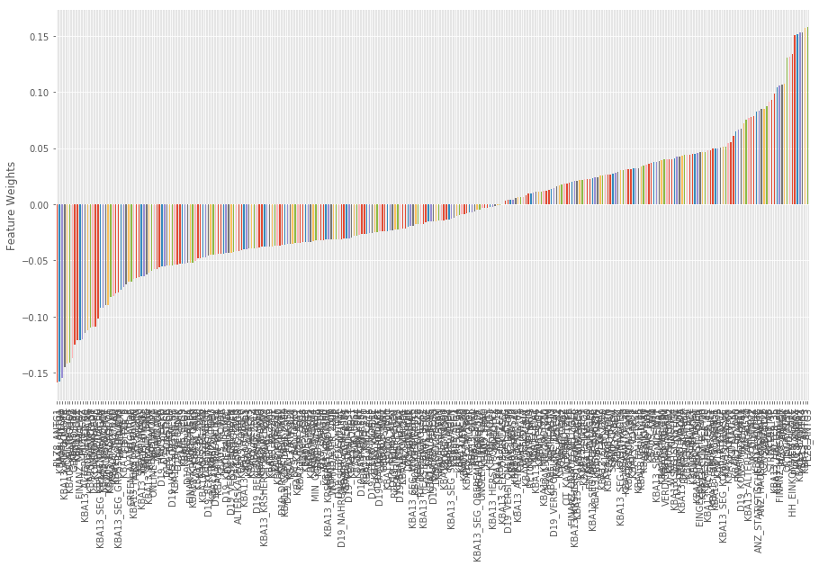

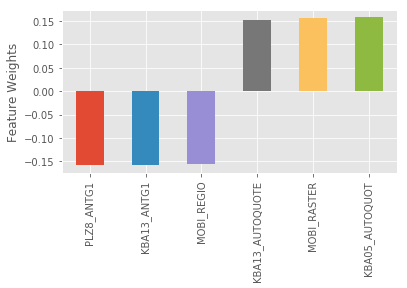

```python
# coordinates of the main variables on the first component
pca_results(clean_azdias, azdias_pca_155, 1)
```

|  | Explained Variance | LNR | AKT_DAT_KL | ANZ_HAUSHALTE_AKTIV | ANZ_HH_TITEL | ANZ_KINDER | ANZ_PERSONEN | ANZ_STATISTISCHE_HAUSHALTE | ANZ_TITEL | ARBEIT | BALLRAUM | CJT_KATALOGNUTZER | CJT_TYP_1 | CJT_TYP_2 | CJT_TYP_3 | CJT_TYP_4 | CJT_TYP_5 | CJT_TYP_6 | D19_BANKEN_DIREKT | D19_BANKEN_GROSS | D19_BANKEN_LOKAL | D19_BANKEN_REST | D19_BEKLEIDUNG_GEH | D19_BEKLEIDUNG_REST | D19_BILDUNG | D19_BIO_OEKO | D19_BUCH_CD | D19_DIGIT_SERV | D19_DROGERIEARTIKEL | … |
| --- | --- | --- | --- | --- | --- | --- | --- | --- | --- | --- | --- | --- | --- | --- | --- | --- | --- | --- | --- | --- | --- | --- | --- | --- | --- | --- | --- | --- | --- | --- |
| Dimension 1 | 0.0823 | -0.0311 | 0.0611 | 0.0848 | 0.0191 | -0.0213 | -0.0661 | 0.0835 | -0.0028 | 0.1076 | -0.0765 | 0.0187 | 0.0551 | 0.0782 | -0.0714 | -0.0349 | -0.0691 | -0.0531 | -0.0243 | -0.0149 | -0.0224 | -0.0266 | -0.0394 | -0.0454 | -0.0430 | -0.0345 | -0.0547 | -0.0148 | -0.0362 | … |
| Dimension 2 | 0.0587 | 0.0777 | 0.0127 | 0.0218 | 0.0274 | -0.0051 | -0.0145 | 0.0208 | 0.0113 | -0.0337 | -0.0906 | -0.0054 | 0.0106 | 0.0227 | -0.0276 | -0.0029 | -0.0098 | -0.0137 | -0.0082 | -0.0039 | -0.0087 | -0.0016 | 0.0142 | -0.0043 | -0.0101 | -0.0051 | -0.0134 | 0.0025 | -0.0064 | … |
| Dimension 3 | 0.0461 | -0.0266 | -0.0505 | 0.0169 | 0.0168 | -0.0742 | -0.0436 | 0.0199 | 0.0082 | 0.0425 | -0.0151 | 0.1530 | -0.2221 | -0.2167 | 0.1921 | 0.1959 | 0.2048 | 0.1909 | -0.0582 | -0.0477 | -0.0124 | -0.0373 | -0.0125 | -0.0365 | -0.0062 | -0.0122 | -0.0123 | -0.0251 | -0.0496 | … |
| Dimension 4 | 0.0325 | -0.0714 | -0.1167 | 0.0078 | 0.0108 | 0.0639 | 0.1427 | 0.0082 | 0.0106 | 0.0873 | -0.0473 | -0.0804 | -0.0057 | -0.0025 | -0.0106 | -0.0278 | -0.0035 | -0.0141 | 0.1146 | 0.0844 | 0.0399 | 0.0918 | 0.1012 | 0.1323 | 0.0942 | 0.0895 | 0.1408 | 0.0657 | 0.1243 | … |
| Dimension 5 | 0.0273 | -0.1082 | 0.0621 | 0.0126 | 0.0099 | -0.0214 | -0.0650 | 0.0154 | -0.0009 | 0.0628 | 0.0561 | 0.0030 | 0.0341 | 0.0299 | -0.0259 | -0.0222 | -0.0362 | -0.0184 | -0.0448 | -0.0334 | -0.0193 | -0.0400 | -0.0452 | -0.0512 | -0.0437 | -0.0443 | -0.0554 | -0.0313 | -0.0495 | … |
| Dimension 6 | 0.0222 | -0.0083 | -0.0207 | 0.0256 | 0.0054 | 0.0082 | 0.0261 | 0.0238 | 0.0004 | -0.0469 | 0.0242 | 0.0309 | -0.0329 | -0.0359 | 0.0385 | 0.0222 | 0.0336 | 0.0338 | 0.0062 | 0.0029 | 0.0127 | 0.0055 | 0.0004 | 0.0048 | 0.0149 | 0.0134 | 0.0077 | 0.0026 | 0.0049 | … |
| Dimension 7 | 0.0207 | -0.0226 | -0.0108 | -0.0169 | -0.0005 | -0.0314 | 0.0049 | -0.0178 | 0.0073 | -0.0090 | 0.0171 | 0.1799 | -0.0781 | -0.0202 | 0.0582 | 0.0066 | 0.0124 | 0.1205 | 0.0070 | 0.0077 | 0.0055 | 0.0026 | -0.0117 | -0.0253 | 0.0034 | -0.0030 | -0.0085 | 0.0019 | -0.0241 | … |
| Dimension 8 | 0.0198 | 0.0223 | 0.0193 | -0.0050 | -0.0041 | -0.0121 | -0.0144 | -0.0043 | -0.0001 | 0.0586 | -0.0439 | 0.0435 | -0.0033 | 0.0236 | -0.0229 | -0.0035 | -0.0250 | 0.0080 | -0.0204 | -0.0124 | -0.0202 | -0.0199 | -0.0250 | -0.0408 | -0.0335 | -0.0273 | -0.0333 | -0.0135 | -0.0356 | … |
| Dimension 9 | 0.0175 | -0.0894 | 0.0273 | -0.0692 | -0.0041 | -0.0058 | -0.0296 | -0.0680 | 0.0085 | 0.0274 | 0.0551 | -0.0390 | 0.0318 | 0.0095 | -0.0216 | -0.0132 | -0.0071 | -0.0322 | -0.0278 | -0.0241 | -0.0042 | -0.0197 | -0.0034 | -0.0089 | -0.0114 | -0.0188 | -0.0175 | -0.0124 | -0.0141 | … |
| Dimension 10 | 0.0166 | 0.0022 | 0.0137 | -0.0389 | 0.0018 | -0.0123 | -0.0266 | -0.0406 | 0.0040 | -0.0230 | -0.0207 | -0.0149 | 0.0052 | 0.0011 | -0.0258 | -0.0200 | 0.0076 | -0.0124 | -0.0290 | -0.0256 | -0.0088 | -0.0203 | -0.0047 | -0.0163 | -0.0152 | -0.0155 | -0.0247 | -0.0140 | -0.0222 | … |
| Dimension 11 | 0.0152 | -0.0220 | -0.0063 | 0.0467 | 0.0386 | 0.0037 | 0.0015 | 0.0481 | 0.0084 | 0.0023 | 0.0673 | 0.0145 | 0.0066 | 0.0023 | 0.0179 | -0.0007 | -0.0077 | 0.0064 | 0.0096 | 0.0100 | 0.0083 | 0.0077 | 0.0081 | 0.0138 | 0.0160 | 0.0128 | 0.0126 | 0.0053 | 0.0137 | … |
| Dimension 12 | 0.0135 | 0.0202 | -0.0009 | 0.0255 | 0.0172 | 0.0051 | 0.0009 | 0.0277 | 0.0015 | -0.0406 | 0.0526 | 0.0039 | 0.0010 | -0.0070 | 0.0131 | -0.0012 | -0.0100 | 0.0227 | 0.0014 | 0.0021 | 0.0055 | 0.0037 | 0.0097 | 0.0091 | 0.0055 | 0.0069 | 0.0086 | 0.0021 | 0.0084 | … |
| Dimension 13 | 0.0119 | -0.0946 | 0.0045 | 0.0375 | 0.0161 | -0.0002 | 0.0014 | 0.0373 | 0.0079 | 0.0113 | 0.0359 | 0.0085 | -0.0070 | -0.0092 | 0.0141 | 0.0111 | 0.0086 | 0.0007 | -0.0001 | 0.0001 | 0.0088 | 0.0007 | 0.0029 | 0.0020 | 0.0059 | 0.0053 | 0.0011 | 0.0032 | 0.0018 | … |
| Dimension 14 | 0.0113 | 0.0477 | -0.0031 | -0.0190 | -0.0133 | 0.0094 | 0.0039 | -0.0186 | -0.0077 | -0.0131 | -0.0442 | -0.0049 | -0.0027 | 0.0011 | -0.0082 | -0.0070 | 0.0036 | -0.0013 | -0.0001 | -0.0012 | -0.0067 | 0.0000 | -0.0073 | -0.0025 | -0.0052 | -0.0014 | -0.0043 | -0.0001 | -0.0016 | … |
| Dimension 15 | 0.0108 | -0.0406 | 0.0002 | 0.0829 | 0.0512 | -0.0048 | -0.0142 | 0.0840 | 0.0041 | -0.0649 | -0.0478 | 0.0214 | -0.0089 | 0.0012 | 0.0036 | -0.0110 | 0.0186 | 0.0122 | 0.0175 | 0.0151 | 0.0048 | 0.0104 | -0.0014 | 0.0059 | 0.0025 | 0.0049 | 0.0017 | 0.0094 | 0.0061 | … |
| Dimension 16 | 0.0103 | 0.0436 | -0.0034 | 0.1484 | 0.0924 | -0.0019 | -0.0241 | 0.1506 | 0.0055 | -0.1847 | 0.0086 | 0.0085 | -0.0007 | -0.0027 | 0.0175 | -0.0101 | 0.0157 | 0.0061 | 0.0162 | 0.0182 | 0.0087 | 0.0136 | 0.0053 | 0.0111 | 0.0046 | 0.0030 | 0.0008 | 0.0109 | 0.0121 | … |
| Dimension 17 | 0.0097 | -0.0207 | 0.0025 | 0.1254 | 0.0636 | -0.0093 | -0.0025 | 0.1249 | 0.0067 | -0.0142 | -0.0350 | 0.0105 | -0.0122 | -0.0006 | 0.0172 | 0.0070 | 0.0128 | 0.0055 | 0.0198 | 0.0177 | 0.0043 | 0.0150 | 0.0039 | 0.0055 | 0.0096 | 0.0119 | 0.0049 | 0.0128 | 0.0085 | … |
| Dimension 18 | 0.0092 | 0.0562 | -0.0046 | 0.0687 | 0.0372 | -0.0056 | -0.0226 | 0.0707 | -0.0030 | -0.0620 | 0.1671 | 0.0566 | 0.0091 | -0.0114 | 0.0637 | 0.0223 | -0.0207 | 0.0324 | 0.0356 | 0.0351 | 0.0230 | 0.0292 | 0.0091 | 0.0198 | 0.0147 | 0.0266 | 0.0121 | 0.0144 | 0.0291 | … |
| Dimension 19 | 0.0091 | 0.0342 | -0.0076 | -0.0396 | -0.0360 | -0.0065 | -0.0112 | -0.0401 | -0.0111 | 0.0294 | 0.0712 | -0.0103 | -0.0012 | -0.0067 | 0.0315 | 0.0163 | -0.0106 | 0.0119 | 0.0182 | 0.0197 | 0.0058 | 0.0127 | 0.0021 | 0.0080 | 0.0084 | 0.0142 | 0.0069 | 0.0075 | 0.0138 | … |
| Dimension 20 | 0.0089 | -0.1017 | -0.0132 | 0.1886 | 0.1134 | -0.0020 | -0.0283 | 0.1916 | 0.0157 | -0.0087 | -0.1411 | 0.0109 | -0.0113 | 0.0102 | -0.0171 | -0.0114 | 0.0223 | -0.0172 | 0.0062 | 0.0144 | -0.0080 | -0.0083 | -0.0071 | -0.0083 | -0.0137 | -0.0262 | -0.0112 | -0.0016 | -0.0009 | … |
| Dimension 21 | 0.0081 | 0.0028 | 0.0895 | 0.0923 | 0.0614 | -0.0296 | 0.1459 | 0.0947 | 0.0417 | -0.0275 | 0.0073 | -0.0088 | 0.0236 | 0.0156 | -0.0011 | 0.0527 | -0.0027 | -0.0510 | -0.1353 | -0.1604 | 0.0424 | -0.0467 | 0.0321 | 0.0073 | 0.1170 | 0.1007 | 0.0681 | -0.0311 | -0.0329 | … |
| Dimension 22 | 0.0079 | 0.0227 | -0.0270 | 0.0462 | -0.0036 | 0.0179 | -0.0194 | 0.0427 | -0.0213 | 0.0953 | -0.0510 | 0.0415 | -0.0241 | -0.0013 | 0.0168 | 0.0121 | 0.0107 | 0.0018 | 0.0592 | 0.0607 | -0.0093 | 0.0270 | -0.0221 | -0.0108 | -0.0365 | -0.0234 | -0.0266 | 0.0135 | 0.0176 | … |
| Dimension 23 | 0.0076 | 0.0232 | 0.0459 | -0.0258 | 0.0084 | -0.0602 | -0.0054 | -0.0250 | 0.0153 | 0.0351 | 0.0075 | 0.0252 | 0.0083 | 0.0127 | 0.0226 | 0.0347 | 0.0081 | 0.0218 | -0.0226 | -0.0401 | 0.0414 | 0.0133 | 0.0486 | 0.0329 | 0.0733 | 0.0885 | 0.0408 | 0.0189 | 0.0273 | … |
| Dimension 24 | 0.0072 | 0.0159 | -0.0001 | 0.0978 | 0.0390 | 0.0070 | 0.0183 | 0.0983 | -0.0008 | 0.0555 | -0.0504 | -0.0110 | -0.0041 | 0.0053 | -0.0139 | 0.0031 | -0.0140 | -0.0078 | 0.0075 | 0.0076 | -0.0133 | 0.0043 | -0.0074 | -0.0078 | -0.0125 | -0.0094 | -0.0055 | 0.0029 | -0.0021 | … |
| Dimension 25 | 0.0070 | 0.0327 | -0.0448 | 0.0969 | 0.0695 | 0.0532 | 0.0019 | 0.0986 | 0.0112 | -0.0825 | 0.1145 | -0.0407 | 0.0038 | -0.0240 | -0.0028 | -0.0055 | -0.0059 | -0.0224 | -0.0027 | 0.0167 | -0.0201 | -0.0187 | -0.0348 | -0.0224 | -0.0322 | -0.0553 | -0.0181 | -0.0217 | -0.0269 | … |
| Dimension 26 | 0.0068 | 0.0055 | 0.0088 | 0.0055 | -0.0115 | -0.0993 | -0.0682 | 0.0055 | -0.0243 | 0.0826 | -0.0420 | 0.0986 | 0.0000 | 0.0146 | 0.0365 | 0.0451 | 0.0076 | -0.0063 | 0.0329 | 0.0188 | 0.0437 | 0.0379 | 0.0359 | 0.0240 | 0.0381 | 0.0864 | 0.0185 | 0.0333 | 0.0415 | … |
| Dimension 27 | 0.0067 | -0.0114 | -0.0028 | 0.0889 | 0.0715 | -0.0709 | -0.0620 | 0.0914 | 0.0056 | 0.0426 | -0.0101 | 0.0251 | -0.0019 | 0.0037 | 0.0390 | 0.0443 | 0.0046 | -0.0105 | 0.0223 | 0.0231 | 0.0265 | 0.0203 | 0.0191 | 0.0135 | 0.0201 | 0.0422 | 0.0122 | 0.0137 | 0.0254 | … |
| Dimension 28 | 0.0064 | -0.0068 | 0.0383 | 0.1795 | 0.1213 | 0.1158 | 0.1050 | 0.1793 | 0.0301 | 0.0336 | 0.0346 | -0.0459 | 0.0070 | 0.0076 | -0.0492 | -0.0477 | -0.0315 | 0.0053 | 0.0005 | -0.0003 | -0.0200 | -0.0073 | -0.0421 | -0.0205 | -0.0229 | -0.0395 | -0.0208 | -0.0066 | -0.0102 | … |
| Dimension 29 | 0.0062 | -0.0286 | -0.0851 | 0.0669 | 0.0973 | 0.0919 | 0.0880 | 0.0707 | 0.0494 | 0.0390 | -0.0390 | -0.0610 | -0.0045 | -0.0028 | 0.0111 | -0.0118 | -0.0010 | -0.0441 | -0.0361 | -0.0021 | -0.1107 | -0.0777 | -0.0799 | -0.0276 | -0.0614 | -0.1851 | 0.0146 | -0.0616 | -0.0673 | … |
| Dimension 30 | 0.0061 | -0.0163 | 0.0375 | 0.2267 | 0.1870 | -0.0420 | -0.0205 | 0.2305 | 0.0374 | 0.0230 | 0.0246 | 0.0357 | 0.0231 | 0.0125 | -0.0182 | -0.0188 | -0.0247 | 0.0308 | 0.0042 | -0.0077 | 0.0319 | 0.0216 | 0.0287 | 0.0151 | 0.0191 | 0.0636 | 0.0017 | 0.0136 | 0.0161 | … |
| ... | ... | ... | ... | ... | ... | ... | ... | ... | ... | ... | ... | ... | ... | ... | ... | ... | ... | ... | ... | ... | ... | ... | ... | ... | ... | ... | ... | ... | ... | … |
| Dimension 126 | 0.0022 | -0.0077 | -0.1007 | -0.0089 | 0.0298 | 0.1231 | -0.0773 | -0.0073 | -0.0100 | 0.0079 | -0.0339 | -0.0005 | -0.0160 | -0.0132 | 0.0255 | -0.0170 | 0.0118 | -0.0256 | 0.0470 | -0.0152 | 0.0026 | 0.0093 | -0.0377 | 0.1653 | -0.1309 | 0.1177 | 0.1079 | -0.0341 | -0.1748 | … |
| Dimension 127 | 0.0022 | -0.0304 | 0.2623 | -0.0160 | 0.0711 | 0.0065 | 0.0184 | -0.0124 | -0.0617 | 0.0182 | -0.0677 | 0.0039 | -0.0793 | -0.0636 | 0.0125 | 0.0705 | 0.1118 | 0.0625 | 0.0155 | 0.0038 | 0.0300 | 0.0049 | 0.0107 | -0.0013 | 0.1100 | -0.0226 | 0.1144 | 0.0015 | 0.0871 | … |
| Dimension 128 | 0.0022 | -0.1288 | -0.2152 | -0.0329 | 0.1211 | 0.0289 | -0.0774 | -0.0268 | -0.0704 | 0.0199 | 0.0331 | 0.0094 | 0.0068 | -0.0017 | -0.0285 | -0.0251 | 0.0073 | 0.0133 | 0.0281 | -0.0229 | -0.0031 | 0.0075 | -0.0145 | 0.1698 | -0.0128 | 0.0282 | -0.1182 | 0.0058 | -0.0022 | … |
| Dimension 129 | 0.0021 | 0.0164 | 0.1724 | -0.0189 | 0.0964 | 0.0382 | 0.0559 | -0.0165 | -0.0454 | -0.0816 | -0.0131 | 0.0306 | 0.0540 | 0.0540 | -0.0726 | -0.0312 | -0.0883 | -0.0479 | 0.0125 | -0.0091 | -0.0277 | -0.0122 | -0.0204 | 0.0574 | -0.2306 | -0.0256 | -0.3385 | -0.0214 | -0.0378 | … |
| Dimension 130 | 0.0021 | 0.0664 | 0.1001 | 0.0024 | 0.0436 | 0.0885 | 0.0043 | 0.0037 | -0.0473 | -0.0298 | 0.0221 | 0.0197 | 0.0557 | 0.0548 | -0.0717 | -0.0248 | -0.0667 | -0.0491 | -0.0208 | 0.0248 | 0.0181 | -0.0248 | -0.0074 | -0.0792 | 0.2361 | -0.0528 | 0.4278 | -0.0025 | -0.0145 | … |
| Dimension 131 | 0.0021 | -0.0406 | 0.2451 | -0.0625 | 0.1588 | 0.0346 | 0.0367 | -0.0552 | -0.1000 | 0.0458 | -0.0154 | 0.0087 | -0.0070 | -0.0051 | -0.0524 | 0.0146 | 0.0462 | -0.0048 | 0.0135 | -0.0075 | -0.0033 | -0.0108 | 0.0036 | 0.0012 | -0.0975 | -0.0163 | -0.0996 | -0.0062 | 0.0088 | … |
| Dimension 132 | 0.0021 | 0.2368 | -0.1690 | -0.0762 | 0.1641 | -0.0193 | -0.0171 | -0.0686 | -0.0884 | -0.0148 | -0.1027 | -0.0143 | -0.0526 | -0.0256 | -0.0272 | -0.0079 | 0.0574 | 0.0526 | 0.0144 | -0.0098 | -0.0050 | 0.0129 | 0.0269 | 0.0195 | -0.0030 | -0.0106 | -0.0114 | 0.0109 | 0.0039 | … |
| Dimension 133 | 0.0021 | -0.2247 | -0.2769 | -0.0958 | 0.2444 | -0.0466 | -0.0158 | -0.0892 | -0.1258 | -0.0073 | -0.0056 | 0.0368 | 0.0130 | 0.0158 | -0.0144 | -0.0332 | -0.0429 | -0.0075 | -0.0338 | 0.0098 | 0.0016 | -0.0095 | 0.0218 | -0.0417 | 0.0513 | -0.0425 | 0.0254 | -0.0026 | -0.0110 | … |
| Dimension 134 | 0.0020 | 0.0744 | -0.0386 | -0.0470 | 0.1016 | 0.0138 | -0.0281 | -0.0414 | -0.0688 | -0.0038 | 0.0445 | -0.0367 | -0.0449 | -0.0479 | 0.0507 | 0.0151 | 0.0261 | 0.0447 | 0.0249 | -0.0065 | -0.0004 | 0.0072 | 0.0189 | 0.0246 | -0.0428 | 0.0002 | 0.0393 | -0.0025 | 0.0206 | … |
| Dimension 135 | 0.0020 | -0.0082 | 0.0116 | -0.0418 | 0.0969 | 0.0005 | 0.0027 | -0.0383 | -0.0538 | 0.0212 | -0.0039 | 0.0112 | 0.0021 | 0.0039 | -0.0066 | -0.0086 | 0.0042 | -0.0112 | 0.0088 | -0.0124 | 0.0037 | 0.0060 | 0.0061 | -0.0137 | 0.0020 | 0.0033 | -0.0057 | -0.0030 | -0.0019 | … |
| Dimension 136 | 0.0020 | 0.2834 | 0.0532 | -0.1345 | 0.3251 | 0.0346 | -0.0024 | -0.1226 | -0.1801 | -0.0149 | 0.0189 | 0.0077 | 0.0070 | 0.0119 | 0.0109 | -0.0234 | -0.0248 | -0.0096 | 0.0408 | -0.0247 | -0.0099 | 0.0007 | 0.0290 | -0.0167 | -0.0521 | 0.0134 | 0.0120 | -0.0100 | -0.0136 | … |
| Dimension 137 | 0.0020 | 0.0619 | 0.0964 | -0.0867 | 0.1926 | 0.0112 | 0.0226 | -0.0776 | -0.0846 | -0.0347 | -0.0451 | 0.0645 | 0.0758 | 0.0790 | -0.1139 | -0.1074 | -0.0784 | -0.0804 | -0.1281 | 0.1170 | 0.0300 | -0.0130 | -0.0780 | -0.0315 | 0.1320 | -0.0806 | -0.1936 | -0.0092 | -0.0208 | … |
| Dimension 138 | 0.0019 | 0.0263 | 0.0512 | 0.0124 | -0.0379 | 0.0171 | 0.0026 | 0.0110 | 0.0203 | 0.0136 | -0.0148 | 0.0440 | 0.0215 | 0.0141 | -0.0189 | -0.0532 | -0.0165 | -0.0228 | -0.0188 | 0.0249 | 0.0081 | -0.0006 | -0.0318 | -0.0183 | 0.0538 | -0.0282 | -0.1038 | -0.0011 | -0.0064 | … |
| Dimension 139 | 0.0019 | -0.1812 | 0.0150 | -0.0933 | 0.1760 | -0.0034 | -0.0124 | -0.0852 | -0.0940 | -0.0036 | 0.0924 | -0.0015 | 0.0218 | 0.0063 | 0.0255 | -0.0287 | -0.0576 | -0.0281 | -0.0255 | 0.0335 | -0.0035 | -0.0014 | -0.0058 | -0.0156 | 0.0136 | 0.0024 | -0.0008 | -0.0031 | 0.0077 | … |
| Dimension 140 | 0.0019 | 0.2078 | -0.0607 | 0.0003 | -0.0081 | -0.0204 | 0.0323 | 0.0004 | -0.0024 | -0.0190 | -0.0067 | -0.0219 | -0.0339 | -0.0203 | -0.0090 | 0.0526 | 0.0337 | 0.0280 | -0.0275 | 0.0404 | 0.0149 | -0.0033 | -0.0191 | 0.0362 | 0.0316 | -0.0378 | -0.0665 | 0.0064 | -0.0100 | … |
| Dimension 141 | 0.0019 | 0.0151 | -0.1130 | -0.0803 | 0.1567 | -0.0243 | 0.0312 | -0.0732 | -0.0701 | -0.0110 | -0.0194 | -0.0113 | 0.0185 | 0.0274 | -0.0545 | -0.0153 | -0.0199 | -0.0467 | -0.1102 | 0.0815 | -0.0079 | 0.0074 | 0.0637 | 0.0266 | -0.0226 | 0.0921 | 0.2872 | 0.0070 | 0.0109 | … |
| Dimension 142 | 0.0019 | -0.0018 | 0.1451 | 0.0145 | -0.0481 | 0.0604 | -0.0498 | 0.0139 | 0.0400 | -0.0142 | -0.0004 | 0.0217 | 0.0205 | 0.0114 | -0.0147 | -0.0531 | -0.0335 | -0.0269 | -0.4783 | 0.3910 | -0.0084 | 0.0037 | 0.0123 | -0.0156 | -0.0351 | 0.1075 | 0.1323 | -0.0051 | -0.0173 | … |
| Dimension 143 | 0.0019 | -0.0099 | -0.1741 | -0.0098 | 0.0321 | 0.0182 | 0.0079 | -0.0093 | -0.0073 | 0.0036 | 0.0071 | 0.0542 | 0.0369 | 0.0358 | -0.0743 | -0.0752 | -0.0623 | -0.0507 | 0.2382 | -0.1859 | -0.0082 | 0.0145 | 0.0609 | -0.0141 | 0.0068 | -0.0026 | 0.1525 | -0.0032 | 0.0477 | … |
| Dimension 144 | 0.0019 | -0.1418 | 0.0720 | -0.1079 | 0.1920 | -0.0821 | 0.0600 | -0.0995 | -0.0995 | 0.0655 | 0.0396 | -0.0729 | -0.0415 | -0.0570 | 0.0617 | 0.0188 | 0.0213 | 0.0393 | -0.0486 | 0.0283 | -0.0081 | -0.0064 | -0.0191 | -0.0086 | 0.0042 | -0.0245 | -0.0798 | 0.0133 | -0.0202 | … |
| Dimension 145 | 0.0018 | 0.0512 | 0.1370 | -0.0903 | 0.1824 | -0.0234 | -0.0102 | -0.0820 | -0.0963 | -0.0398 | -0.1248 | -0.0308 | 0.0120 | 0.0166 | -0.0009 | 0.0334 | 0.0488 | -0.0280 | 0.1913 | -0.1839 | 0.0041 | -0.0035 | -0.0009 | -0.0363 | -0.0114 | 0.0184 | 0.0607 | 0.0075 | -0.0240 | … |
| Dimension 146 | 0.0018 | -0.0224 | 0.1080 | -0.0077 | -0.0238 | -0.0328 | 0.0287 | -0.0076 | 0.0197 | 0.0072 | 0.0182 | -0.0141 | 0.0002 | -0.0181 | 0.0217 | -0.0096 | 0.0040 | -0.0147 | 0.2393 | -0.2063 | -0.0110 | -0.0018 | -0.0024 | -0.0271 | 0.0183 | -0.0070 | 0.0236 | 0.0082 | -0.0290 | … |
| Dimension 147 | 0.0018 | 0.0312 | -0.1130 | -0.0529 | 0.1387 | -0.0988 | 0.0654 | -0.0509 | -0.0769 | 0.0282 | -0.0060 | -0.0848 | -0.0346 | -0.0094 | 0.0583 | 0.1719 | 0.0664 | 0.0659 | -0.2930 | 0.2206 | 0.0096 | -0.0185 | -0.0051 | 0.0651 | -0.0103 | 0.0069 | -0.0130 | 0.0091 | 0.0255 | … |
| Dimension 148 | 0.0018 | 0.0832 | 0.0916 | -0.0597 | 0.0780 | -0.0432 | 0.0128 | -0.0540 | -0.0323 | -0.0287 | 0.0796 | 0.0140 | -0.0081 | -0.0399 | 0.0804 | -0.0030 | -0.0257 | 0.0257 | -0.0594 | 0.0307 | 0.0018 | 0.0022 | 0.0033 | -0.0131 | -0.0291 | 0.0117 | 0.0049 | -0.0061 | 0.0236 | … |
| Dimension 149 | 0.0018 | 0.0118 | -0.0197 | -0.0334 | 0.0594 | -0.0729 | 0.0707 | -0.0320 | -0.0067 | -0.0007 | 0.0491 | -0.0417 | -0.0135 | -0.0114 | 0.0410 | 0.0456 | -0.0106 | -0.0092 | 0.2218 | -0.1835 | -0.0326 | -0.0061 | 0.0027 | 0.0146 | 0.0884 | -0.0120 | 0.0703 | 0.0226 | -0.0493 | … |
| Dimension 150 | 0.0017 | 0.0792 | -0.1521 | 0.0056 | -0.0353 | 0.0488 | -0.0472 | 0.0065 | 0.0199 | -0.0121 | -0.0275 | 0.0082 | -0.0011 | -0.0230 | 0.0104 | -0.0713 | 0.0175 | -0.0067 | -0.0867 | 0.0847 | -0.0053 | -0.0014 | -0.0030 | -0.0168 | 0.0502 | -0.0182 | 0.0115 | -0.0074 | 0.0327 | … |
| Dimension 151 | 0.0017 | -0.0872 | -0.0914 | -0.0246 | 0.0568 | -0.0242 | 0.0259 | -0.0212 | -0.0354 | -0.0098 | 0.0540 | -0.0333 | 0.0038 | -0.0122 | -0.0026 | -0.0147 | -0.0020 | -0.0092 | 0.0085 | -0.0029 | -0.0053 | -0.0039 | -0.0055 | -0.0167 | 0.0107 | -0.0175 | -0.0049 | 0.0016 | 0.0029 | … |
| Dimension 152 | 0.0017 | 0.1272 | -0.0047 | 0.0187 | -0.0304 | -0.0421 | 0.0518 | 0.0163 | 0.0267 | 0.0088 | -0.0225 | -0.0106 | 0.0045 | 0.0189 | -0.0233 | 0.0173 | -0.0157 | 0.0155 | 0.0104 | -0.0120 | -0.0019 | -0.0014 | 0.0074 | 0.0077 | -0.0007 | 0.0044 | 0.0147 | 0.0067 | -0.0094 | … |
| Dimension 153 | 0.0017 | -0.2367 | -0.0750 | -0.0126 | 0.0148 | -0.0323 | 0.0666 | -0.0117 | -0.0058 | 0.0455 | -0.0111 | -0.0382 | -0.0340 | -0.0303 | -0.0251 | 0.0311 | 0.0449 | 0.0263 | -0.0288 | 0.0129 | -0.0038 | -0.0062 | 0.0128 | -0.0265 | -0.0015 | -0.0103 | 0.0148 | 0.0010 | 0.0088 | … |
| Dimension 154 | 0.0017 | -0.0409 | -0.0228 | 0.0045 | 0.0140 | 0.0556 | -0.0465 | 0.0058 | -0.0244 | 0.0145 | 0.1561 | 0.0222 | 0.0178 | -0.0046 | -0.0086 | -0.0480 | -0.0325 | -0.0032 | 0.0096 | 0.0104 | -0.0018 | -0.0001 | -0.0232 | 0.0032 | -0.0029 | -0.0047 | -0.0382 | 0.0041 | -0.0027 | … |
| Dimension 155 | 0.0017 | 0.1619 | -0.0990 | -0.0725 | 0.1089 | 0.0083 | 0.0219 | -0.0673 | -0.0603 | -0.0545 | -0.0611 | -0.0124 | -0.0119 | 0.0022 | -0.0449 | 0.0068 | -0.0104 | 0.0028 | -0.0008 | 0.0044 | -0.0035 | -0.0076 | 0.0022 | -0.0106 | 0.0021 | -0.0112 | -0.0242 | 0.0053 | 0.0111 | … |

155 rows × 295 columns

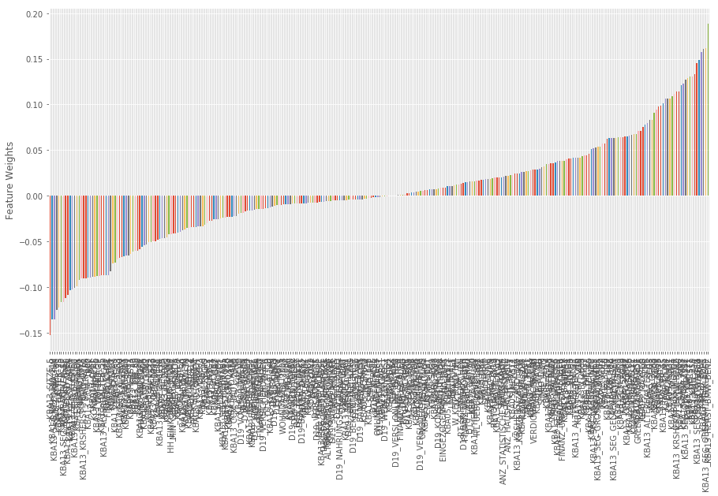

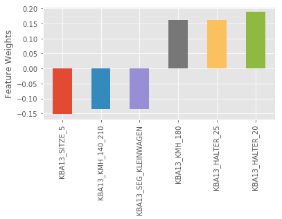

```python
# coordinates of the main variables on the  component 2
pca_results(clean_azdias, azdias_pca_155, 2)
```

|  | Explained Variance | LNR | AKT_DAT_KL | ANZ_HAUSHALTE_AKTIV | ANZ_HH_TITEL | ANZ_KINDER | ANZ_PERSONEN | ANZ_STATISTISCHE_HAUSHALTE | ANZ_TITEL | ARBEIT | BALLRAUM | CJT_KATALOGNUTZER | CJT_TYP_1 | CJT_TYP_2 | CJT_TYP_3 | CJT_TYP_4 | CJT_TYP_5 | CJT_TYP_6 | D19_BANKEN_DIREKT | D19_BANKEN_GROSS | D19_BANKEN_LOKAL | D19_BANKEN_REST | D19_BEKLEIDUNG_GEH | D19_BEKLEIDUNG_REST | D19_BILDUNG | D19_BIO_OEKO | D19_BUCH_CD | D19_DIGIT_SERV | D19_DROGERIEARTIKEL | … |
| --- | --- | --- | --- | --- | --- | --- | --- | --- | --- | --- | --- | --- | --- | --- | --- | --- | --- | --- | --- | --- | --- | --- | --- | --- | --- | --- | --- | --- | --- | --- |
| Dimension 1 | 0.0823 | -0.0311 | 0.0611 | 0.0848 | 0.0191 | -0.0213 | -0.0661 | 0.0835 | -0.0028 | 0.1076 | -0.0765 | 0.0187 | 0.0551 | 0.0782 | -0.0714 | -0.0349 | -0.0691 | -0.0531 | -0.0243 | -0.0149 | -0.0224 | -0.0266 | -0.0394 | -0.0454 | -0.0430 | -0.0345 | -0.0547 | -0.0148 | -0.0362 | … |
| Dimension 2 | 0.0587 | 0.0777 | 0.0127 | 0.0218 | 0.0274 | -0.0051 | -0.0145 | 0.0208 | 0.0113 | -0.0337 | -0.0906 | -0.0054 | 0.0106 | 0.0227 | -0.0276 | -0.0029 | -0.0098 | -0.0137 | -0.0082 | -0.0039 | -0.0087 | -0.0016 | 0.0142 | -0.0043 | -0.0101 | -0.0051 | -0.0134 | 0.0025 | -0.0064 | … |
| Dimension 3 | 0.0461 | -0.0266 | -0.0505 | 0.0169 | 0.0168 | -0.0742 | -0.0436 | 0.0199 | 0.0082 | 0.0425 | -0.0151 | 0.1530 | -0.2221 | -0.2167 | 0.1921 | 0.1959 | 0.2048 | 0.1909 | -0.0582 | -0.0477 | -0.0124 | -0.0373 | -0.0125 | -0.0365 | -0.0062 | -0.0122 | -0.0123 | -0.0251 | -0.0496 | … |
| Dimension 4 | 0.0325 | -0.0714 | -0.1167 | 0.0078 | 0.0108 | 0.0639 | 0.1427 | 0.0082 | 0.0106 | 0.0873 | -0.0473 | -0.0804 | -0.0057 | -0.0025 | -0.0106 | -0.0278 | -0.0035 | -0.0141 | 0.1146 | 0.0844 | 0.0399 | 0.0918 | 0.1012 | 0.1323 | 0.0942 | 0.0895 | 0.1408 | 0.0657 | 0.1243 | … |
| Dimension 5 | 0.0273 | -0.1082 | 0.0621 | 0.0126 | 0.0099 | -0.0214 | -0.0650 | 0.0154 | -0.0009 | 0.0628 | 0.0561 | 0.0030 | 0.0341 | 0.0299 | -0.0259 | -0.0222 | -0.0362 | -0.0184 | -0.0448 | -0.0334 | -0.0193 | -0.0400 | -0.0452 | -0.0512 | -0.0437 | -0.0443 | -0.0554 | -0.0313 | -0.0495 | … |
| Dimension 6 | 0.0222 | -0.0083 | -0.0207 | 0.0256 | 0.0054 | 0.0082 | 0.0261 | 0.0238 | 0.0004 | -0.0469 | 0.0242 | 0.0309 | -0.0329 | -0.0359 | 0.0385 | 0.0222 | 0.0336 | 0.0338 | 0.0062 | 0.0029 | 0.0127 | 0.0055 | 0.0004 | 0.0048 | 0.0149 | 0.0134 | 0.0077 | 0.0026 | 0.0049 | … |
| Dimension 7 | 0.0207 | -0.0226 | -0.0108 | -0.0169 | -0.0005 | -0.0314 | 0.0049 | -0.0178 | 0.0073 | -0.0090 | 0.0171 | 0.1799 | -0.0781 | -0.0202 | 0.0582 | 0.0066 | 0.0124 | 0.1205 | 0.0070 | 0.0077 | 0.0055 | 0.0026 | -0.0117 | -0.0253 | 0.0034 | -0.0030 | -0.0085 | 0.0019 | -0.0241 | … |
| Dimension 8 | 0.0198 | 0.0223 | 0.0193 | -0.0050 | -0.0041 | -0.0121 | -0.0144 | -0.0043 | -0.0001 | 0.0586 | -0.0439 | 0.0435 | -0.0033 | 0.0236 | -0.0229 | -0.0035 | -0.0250 | 0.0080 | -0.0204 | -0.0124 | -0.0202 | -0.0199 | -0.0250 | -0.0408 | -0.0335 | -0.0273 | -0.0333 | -0.0135 | -0.0356 | … |
| Dimension 9 | 0.0175 | -0.0894 | 0.0273 | -0.0692 | -0.0041 | -0.0058 | -0.0296 | -0.0680 | 0.0085 | 0.0274 | 0.0551 | -0.0390 | 0.0318 | 0.0095 | -0.0216 | -0.0132 | -0.0071 | -0.0322 | -0.0278 | -0.0241 | -0.0042 | -0.0197 | -0.0034 | -0.0089 | -0.0114 | -0.0188 | -0.0175 | -0.0124 | -0.0141 | … |
| Dimension 10 | 0.0166 | 0.0022 | 0.0137 | -0.0389 | 0.0018 | -0.0123 | -0.0266 | -0.0406 | 0.0040 | -0.0230 | -0.0207 | -0.0149 | 0.0052 | 0.0011 | -0.0258 | -0.0200 | 0.0076 | -0.0124 | -0.0290 | -0.0256 | -0.0088 | -0.0203 | -0.0047 | -0.0163 | -0.0152 | -0.0155 | -0.0247 | -0.0140 | -0.0222 | … |
| Dimension 11 | 0.0152 | -0.0220 | -0.0063 | 0.0467 | 0.0386 | 0.0037 | 0.0015 | 0.0481 | 0.0084 | 0.0023 | 0.0673 | 0.0145 | 0.0066 | 0.0023 | 0.0179 | -0.0007 | -0.0077 | 0.0064 | 0.0096 | 0.0100 | 0.0083 | 0.0077 | 0.0081 | 0.0138 | 0.0160 | 0.0128 | 0.0126 | 0.0053 | 0.0137 | … |
| Dimension 12 | 0.0135 | 0.0202 | -0.0009 | 0.0255 | 0.0172 | 0.0051 | 0.0009 | 0.0277 | 0.0015 | -0.0406 | 0.0526 | 0.0039 | 0.0010 | -0.0070 | 0.0131 | -0.0012 | -0.0100 | 0.0227 | 0.0014 | 0.0021 | 0.0055 | 0.0037 | 0.0097 | 0.0091 | 0.0055 | 0.0069 | 0.0086 | 0.0021 | 0.0084 | … |
| Dimension 13 | 0.0119 | -0.0946 | 0.0045 | 0.0375 | 0.0161 | -0.0002 | 0.0014 | 0.0373 | 0.0079 | 0.0113 | 0.0359 | 0.0085 | -0.0070 | -0.0092 | 0.0141 | 0.0111 | 0.0086 | 0.0007 | -0.0001 | 0.0001 | 0.0088 | 0.0007 | 0.0029 | 0.0020 | 0.0059 | 0.0053 | 0.0011 | 0.0032 | 0.0018 | … |
| Dimension 14 | 0.0113 | 0.0477 | -0.0031 | -0.0190 | -0.0133 | 0.0094 | 0.0039 | -0.0186 | -0.0077 | -0.0131 | -0.0442 | -0.0049 | -0.0027 | 0.0011 | -0.0082 | -0.0070 | 0.0036 | -0.0013 | -0.0001 | -0.0012 | -0.0067 | 0.0000 | -0.0073 | -0.0025 | -0.0052 | -0.0014 | -0.0043 | -0.0001 | -0.0016 | … |
| Dimension 15 | 0.0108 | -0.0406 | 0.0002 | 0.0829 | 0.0512 | -0.0048 | -0.0142 | 0.0840 | 0.0041 | -0.0649 | -0.0478 | 0.0214 | -0.0089 | 0.0012 | 0.0036 | -0.0110 | 0.0186 | 0.0122 | 0.0175 | 0.0151 | 0.0048 | 0.0104 | -0.0014 | 0.0059 | 0.0025 | 0.0049 | 0.0017 | 0.0094 | 0.0061 | … |
| Dimension 16 | 0.0103 | 0.0436 | -0.0034 | 0.1484 | 0.0924 | -0.0019 | -0.0241 | 0.1506 | 0.0055 | -0.1847 | 0.0086 | 0.0085 | -0.0007 | -0.0027 | 0.0175 | -0.0101 | 0.0157 | 0.0061 | 0.0162 | 0.0182 | 0.0087 | 0.0136 | 0.0053 | 0.0111 | 0.0046 | 0.0030 | 0.0008 | 0.0109 | 0.0121 | … |
| Dimension 17 | 0.0097 | -0.0207 | 0.0025 | 0.1254 | 0.0636 | -0.0093 | -0.0025 | 0.1249 | 0.0067 | -0.0142 | -0.0350 | 0.0105 | -0.0122 | -0.0006 | 0.0172 | 0.0070 | 0.0128 | 0.0055 | 0.0198 | 0.0177 | 0.0043 | 0.0150 | 0.0039 | 0.0055 | 0.0096 | 0.0119 | 0.0049 | 0.0128 | 0.0085 | … |
| Dimension 18 | 0.0092 | 0.0562 | -0.0046 | 0.0687 | 0.0372 | -0.0056 | -0.0226 | 0.0707 | -0.0030 | -0.0620 | 0.1671 | 0.0566 | 0.0091 | -0.0114 | 0.0637 | 0.0223 | -0.0207 | 0.0324 | 0.0356 | 0.0351 | 0.0230 | 0.0292 | 0.0091 | 0.0198 | 0.0147 | 0.0266 | 0.0121 | 0.0144 | 0.0291 | … |
| Dimension 19 | 0.0091 | 0.0342 | -0.0076 | -0.0396 | -0.0360 | -0.0065 | -0.0112 | -0.0401 | -0.0111 | 0.0294 | 0.0712 | -0.0103 | -0.0012 | -0.0067 | 0.0315 | 0.0163 | -0.0106 | 0.0119 | 0.0182 | 0.0197 | 0.0058 | 0.0127 | 0.0021 | 0.0080 | 0.0084 | 0.0142 | 0.0069 | 0.0075 | 0.0138 | … |
| Dimension 20 | 0.0089 | -0.1017 | -0.0132 | 0.1886 | 0.1134 | -0.0020 | -0.0283 | 0.1916 | 0.0157 | -0.0087 | -0.1411 | 0.0109 | -0.0113 | 0.0102 | -0.0171 | -0.0114 | 0.0223 | -0.0172 | 0.0062 | 0.0144 | -0.0080 | -0.0083 | -0.0071 | -0.0083 | -0.0137 | -0.0262 | -0.0112 | -0.0016 | -0.0009 | … |
| Dimension 21 | 0.0081 | 0.0028 | 0.0895 | 0.0923 | 0.0614 | -0.0296 | 0.1459 | 0.0947 | 0.0417 | -0.0275 | 0.0073 | -0.0088 | 0.0236 | 0.0156 | -0.0011 | 0.0527 | -0.0027 | -0.0510 | -0.1353 | -0.1604 | 0.0424 | -0.0467 | 0.0321 | 0.0073 | 0.1170 | 0.1007 | 0.0681 | -0.0311 | -0.0329 | … |
| Dimension 22 | 0.0079 | 0.0227 | -0.0270 | 0.0462 | -0.0036 | 0.0179 | -0.0194 | 0.0427 | -0.0213 | 0.0953 | -0.0510 | 0.0415 | -0.0241 | -0.0013 | 0.0168 | 0.0121 | 0.0107 | 0.0018 | 0.0592 | 0.0607 | -0.0093 | 0.0270 | -0.0221 | -0.0108 | -0.0365 | -0.0234 | -0.0266 | 0.0135 | 0.0176 | … |
| Dimension 23 | 0.0076 | 0.0232 | 0.0459 | -0.0258 | 0.0084 | -0.0602 | -0.0054 | -0.0250 | 0.0153 | 0.0351 | 0.0075 | 0.0252 | 0.0083 | 0.0127 | 0.0226 | 0.0347 | 0.0081 | 0.0218 | -0.0226 | -0.0401 | 0.0414 | 0.0133 | 0.0486 | 0.0329 | 0.0733 | 0.0885 | 0.0408 | 0.0189 | 0.0273 | … |
| Dimension 24 | 0.0072 | 0.0159 | -0.0001 | 0.0978 | 0.0390 | 0.0070 | 0.0183 | 0.0983 | -0.0008 | 0.0555 | -0.0504 | -0.0110 | -0.0041 | 0.0053 | -0.0139 | 0.0031 | -0.0140 | -0.0078 | 0.0075 | 0.0076 | -0.0133 | 0.0043 | -0.0074 | -0.0078 | -0.0125 | -0.0094 | -0.0055 | 0.0029 | -0.0021 | … |
| Dimension 25 | 0.0070 | 0.0327 | -0.0448 | 0.0969 | 0.0695 | 0.0532 | 0.0019 | 0.0986 | 0.0112 | -0.0825 | 0.1145 | -0.0407 | 0.0038 | -0.0240 | -0.0028 | -0.0055 | -0.0059 | -0.0224 | -0.0027 | 0.0167 | -0.0201 | -0.0187 | -0.0348 | -0.0224 | -0.0322 | -0.0553 | -0.0181 | -0.0217 | -0.0269 | … |
| Dimension 26 | 0.0068 | 0.0055 | 0.0088 | 0.0055 | -0.0115 | -0.0993 | -0.0682 | 0.0055 | -0.0243 | 0.0826 | -0.0420 | 0.0986 | 0.0000 | 0.0146 | 0.0365 | 0.0451 | 0.0076 | -0.0063 | 0.0329 | 0.0188 | 0.0437 | 0.0379 | 0.0359 | 0.0240 | 0.0381 | 0.0864 | 0.0185 | 0.0333 | 0.0415 | … |
| Dimension 27 | 0.0067 | -0.0114 | -0.0028 | 0.0889 | 0.0715 | -0.0709 | -0.0620 | 0.0914 | 0.0056 | 0.0426 | -0.0101 | 0.0251 | -0.0019 | 0.0037 | 0.0390 | 0.0443 | 0.0046 | -0.0105 | 0.0223 | 0.0231 | 0.0265 | 0.0203 | 0.0191 | 0.0135 | 0.0201 | 0.0422 | 0.0122 | 0.0137 | 0.0254 | … |
| Dimension 28 | 0.0064 | -0.0068 | 0.0383 | 0.1795 | 0.1213 | 0.1158 | 0.1050 | 0.1793 | 0.0301 | 0.0336 | 0.0346 | -0.0459 | 0.0070 | 0.0076 | -0.0492 | -0.0477 | -0.0315 | 0.0053 | 0.0005 | -0.0003 | -0.0200 | -0.0073 | -0.0421 | -0.0205 | -0.0229 | -0.0395 | -0.0208 | -0.0066 | -0.0102 | … |
| Dimension 29 | 0.0062 | -0.0286 | -0.0851 | 0.0669 | 0.0973 | 0.0919 | 0.0880 | 0.0707 | 0.0494 | 0.0390 | -0.0390 | -0.0610 | -0.0045 | -0.0028 | 0.0111 | -0.0118 | -0.0010 | -0.0441 | -0.0361 | -0.0021 | -0.1107 | -0.0777 | -0.0799 | -0.0276 | -0.0614 | -0.1851 | 0.0146 | -0.0616 | -0.0673 | … |
| Dimension 30 | 0.0061 | -0.0163 | 0.0375 | 0.2267 | 0.1870 | -0.0420 | -0.0205 | 0.2305 | 0.0374 | 0.0230 | 0.0246 | 0.0357 | 0.0231 | 0.0125 | -0.0182 | -0.0188 | -0.0247 | 0.0308 | 0.0042 | -0.0077 | 0.0319 | 0.0216 | 0.0287 | 0.0151 | 0.0191 | 0.0636 | 0.0017 | 0.0136 | 0.0161 | … |
| ... | ... | ... | ... | ... | ... | ... | ... | ... | ... | ... | ... | ... | ... | ... | ... | ... | ... | ... | ... | ... | ... | ... | ... | ... | ... | ... | ... | ... | ... | … |
| Dimension 126 | 0.0022 | -0.0077 | -0.1007 | -0.0089 | 0.0298 | 0.1231 | -0.0773 | -0.0073 | -0.0100 | 0.0079 | -0.0339 | -0.0005 | -0.0160 | -0.0132 | 0.0255 | -0.0170 | 0.0118 | -0.0256 | 0.0470 | -0.0152 | 0.0026 | 0.0093 | -0.0377 | 0.1653 | -0.1309 | 0.1177 | 0.1079 | -0.0341 | -0.1748 | … |
| Dimension 127 | 0.0022 | -0.0304 | 0.2623 | -0.0160 | 0.0711 | 0.0065 | 0.0184 | -0.0124 | -0.0617 | 0.0182 | -0.0677 | 0.0039 | -0.0793 | -0.0636 | 0.0125 | 0.0705 | 0.1118 | 0.0625 | 0.0155 | 0.0038 | 0.0300 | 0.0049 | 0.0107 | -0.0013 | 0.1100 | -0.0226 | 0.1144 | 0.0015 | 0.0871 | … |
| Dimension 128 | 0.0022 | -0.1288 | -0.2152 | -0.0329 | 0.1211 | 0.0289 | -0.0774 | -0.0268 | -0.0704 | 0.0199 | 0.0331 | 0.0094 | 0.0068 | -0.0017 | -0.0285 | -0.0251 | 0.0073 | 0.0133 | 0.0281 | -0.0229 | -0.0031 | 0.0075 | -0.0145 | 0.1698 | -0.0128 | 0.0282 | -0.1182 | 0.0058 | -0.0022 | … |
| Dimension 129 | 0.0021 | 0.0164 | 0.1724 | -0.0189 | 0.0964 | 0.0382 | 0.0559 | -0.0165 | -0.0454 | -0.0816 | -0.0131 | 0.0306 | 0.0540 | 0.0540 | -0.0726 | -0.0312 | -0.0883 | -0.0479 | 0.0125 | -0.0091 | -0.0277 | -0.0122 | -0.0204 | 0.0574 | -0.2306 | -0.0256 | -0.3385 | -0.0214 | -0.0378 | … |
| Dimension 130 | 0.0021 | 0.0664 | 0.1001 | 0.0024 | 0.0436 | 0.0885 | 0.0043 | 0.0037 | -0.0473 | -0.0298 | 0.0221 | 0.0197 | 0.0557 | 0.0548 | -0.0717 | -0.0248 | -0.0667 | -0.0491 | -0.0208 | 0.0248 | 0.0181 | -0.0248 | -0.0074 | -0.0792 | 0.2361 | -0.0528 | 0.4278 | -0.0025 | -0.0145 | … |
| Dimension 131 | 0.0021 | -0.0406 | 0.2451 | -0.0625 | 0.1588 | 0.0346 | 0.0367 | -0.0552 | -0.1000 | 0.0458 | -0.0154 | 0.0087 | -0.0070 | -0.0051 | -0.0524 | 0.0146 | 0.0462 | -0.0048 | 0.0135 | -0.0075 | -0.0033 | -0.0108 | 0.0036 | 0.0012 | -0.0975 | -0.0163 | -0.0996 | -0.0062 | 0.0088 | … |
| Dimension 132 | 0.0021 | 0.2368 | -0.1690 | -0.0762 | 0.1641 | -0.0193 | -0.0171 | -0.0686 | -0.0884 | -0.0148 | -0.1027 | -0.0143 | -0.0526 | -0.0256 | -0.0272 | -0.0079 | 0.0574 | 0.0526 | 0.0144 | -0.0098 | -0.0050 | 0.0129 | 0.0269 | 0.0195 | -0.0030 | -0.0106 | -0.0114 | 0.0109 | 0.0039 | … |
| Dimension 133 | 0.0021 | -0.2247 | -0.2769 | -0.0958 | 0.2444 | -0.0466 | -0.0158 | -0.0892 | -0.1258 | -0.0073 | -0.0056 | 0.0368 | 0.0130 | 0.0158 | -0.0144 | -0.0332 | -0.0429 | -0.0075 | -0.0338 | 0.0098 | 0.0016 | -0.0095 | 0.0218 | -0.0417 | 0.0513 | -0.0425 | 0.0254 | -0.0026 | -0.0110 | … |
| Dimension 134 | 0.0020 | 0.0744 | -0.0386 | -0.0470 | 0.1016 | 0.0138 | -0.0281 | -0.0414 | -0.0688 | -0.0038 | 0.0445 | -0.0367 | -0.0449 | -0.0479 | 0.0507 | 0.0151 | 0.0261 | 0.0447 | 0.0249 | -0.0065 | -0.0004 | 0.0072 | 0.0189 | 0.0246 | -0.0428 | 0.0002 | 0.0393 | -0.0025 | 0.0206 | … |
| Dimension 135 | 0.0020 | -0.0082 | 0.0116 | -0.0418 | 0.0969 | 0.0005 | 0.0027 | -0.0383 | -0.0538 | 0.0212 | -0.0039 | 0.0112 | 0.0021 | 0.0039 | -0.0066 | -0.0086 | 0.0042 | -0.0112 | 0.0088 | -0.0124 | 0.0037 | 0.0060 | 0.0061 | -0.0137 | 0.0020 | 0.0033 | -0.0057 | -0.0030 | -0.0019 | … |
| Dimension 136 | 0.0020 | 0.2834 | 0.0532 | -0.1345 | 0.3251 | 0.0346 | -0.0024 | -0.1226 | -0.1801 | -0.0149 | 0.0189 | 0.0077 | 0.0070 | 0.0119 | 0.0109 | -0.0234 | -0.0248 | -0.0096 | 0.0408 | -0.0247 | -0.0099 | 0.0007 | 0.0290 | -0.0167 | -0.0521 | 0.0134 | 0.0120 | -0.0100 | -0.0136 | … |
| Dimension 137 | 0.0020 | 0.0619 | 0.0964 | -0.0867 | 0.1926 | 0.0112 | 0.0226 | -0.0776 | -0.0846 | -0.0347 | -0.0451 | 0.0645 | 0.0758 | 0.0790 | -0.1139 | -0.1074 | -0.0784 | -0.0804 | -0.1281 | 0.1170 | 0.0300 | -0.0130 | -0.0780 | -0.0315 | 0.1320 | -0.0806 | -0.1936 | -0.0092 | -0.0208 | … |
| Dimension 138 | 0.0019 | 0.0263 | 0.0512 | 0.0124 | -0.0379 | 0.0171 | 0.0026 | 0.0110 | 0.0203 | 0.0136 | -0.0148 | 0.0440 | 0.0215 | 0.0141 | -0.0189 | -0.0532 | -0.0165 | -0.0228 | -0.0188 | 0.0249 | 0.0081 | -0.0006 | -0.0318 | -0.0183 | 0.0538 | -0.0282 | -0.1038 | -0.0011 | -0.0064 | … |
| Dimension 139 | 0.0019 | -0.1812 | 0.0150 | -0.0933 | 0.1760 | -0.0034 | -0.0124 | -0.0852 | -0.0940 | -0.0036 | 0.0924 | -0.0015 | 0.0218 | 0.0063 | 0.0255 | -0.0287 | -0.0576 | -0.0281 | -0.0255 | 0.0335 | -0.0035 | -0.0014 | -0.0058 | -0.0156 | 0.0136 | 0.0024 | -0.0008 | -0.0031 | 0.0077 | … |
| Dimension 140 | 0.0019 | 0.2078 | -0.0607 | 0.0003 | -0.0081 | -0.0204 | 0.0323 | 0.0004 | -0.0024 | -0.0190 | -0.0067 | -0.0219 | -0.0339 | -0.0203 | -0.0090 | 0.0526 | 0.0337 | 0.0280 | -0.0275 | 0.0404 | 0.0149 | -0.0033 | -0.0191 | 0.0362 | 0.0316 | -0.0378 | -0.0665 | 0.0064 | -0.0100 | … |
| Dimension 141 | 0.0019 | 0.0151 | -0.1130 | -0.0803 | 0.1567 | -0.0243 | 0.0312 | -0.0732 | -0.0701 | -0.0110 | -0.0194 | -0.0113 | 0.0185 | 0.0274 | -0.0545 | -0.0153 | -0.0199 | -0.0467 | -0.1102 | 0.0815 | -0.0079 | 0.0074 | 0.0637 | 0.0266 | -0.0226 | 0.0921 | 0.2872 | 0.0070 | 0.0109 | … |
| Dimension 142 | 0.0019 | -0.0018 | 0.1451 | 0.0145 | -0.0481 | 0.0604 | -0.0498 | 0.0139 | 0.0400 | -0.0142 | -0.0004 | 0.0217 | 0.0205 | 0.0114 | -0.0147 | -0.0531 | -0.0335 | -0.0269 | -0.4783 | 0.3910 | -0.0084 | 0.0037 | 0.0123 | -0.0156 | -0.0351 | 0.1075 | 0.1323 | -0.0051 | -0.0173 | … |
| Dimension 143 | 0.0019 | -0.0099 | -0.1741 | -0.0098 | 0.0321 | 0.0182 | 0.0079 | -0.0093 | -0.0073 | 0.0036 | 0.0071 | 0.0542 | 0.0369 | 0.0358 | -0.0743 | -0.0752 | -0.0623 | -0.0507 | 0.2382 | -0.1859 | -0.0082 | 0.0145 | 0.0609 | -0.0141 | 0.0068 | -0.0026 | 0.1525 | -0.0032 | 0.0477 | … |
| Dimension 144 | 0.0019 | -0.1418 | 0.0720 | -0.1079 | 0.1920 | -0.0821 | 0.0600 | -0.0995 | -0.0995 | 0.0655 | 0.0396 | -0.0729 | -0.0415 | -0.0570 | 0.0617 | 0.0188 | 0.0213 | 0.0393 | -0.0486 | 0.0283 | -0.0081 | -0.0064 | -0.0191 | -0.0086 | 0.0042 | -0.0245 | -0.0798 | 0.0133 | -0.0202 | … |
| Dimension 145 | 0.0018 | 0.0512 | 0.1370 | -0.0903 | 0.1824 | -0.0234 | -0.0102 | -0.0820 | -0.0963 | -0.0398 | -0.1248 | -0.0308 | 0.0120 | 0.0166 | -0.0009 | 0.0334 | 0.0488 | -0.0280 | 0.1913 | -0.1839 | 0.0041 | -0.0035 | -0.0009 | -0.0363 | -0.0114 | 0.0184 | 0.0607 | 0.0075 | -0.0240 | … |
| Dimension 146 | 0.0018 | -0.0224 | 0.1080 | -0.0077 | -0.0238 | -0.0328 | 0.0287 | -0.0076 | 0.0197 | 0.0072 | 0.0182 | -0.0141 | 0.0002 | -0.0181 | 0.0217 | -0.0096 | 0.0040 | -0.0147 | 0.2393 | -0.2063 | -0.0110 | -0.0018 | -0.0024 | -0.0271 | 0.0183 | -0.0070 | 0.0236 | 0.0082 | -0.0290 | … |
| Dimension 147 | 0.0018 | 0.0312 | -0.1130 | -0.0529 | 0.1387 | -0.0988 | 0.0654 | -0.0509 | -0.0769 | 0.0282 | -0.0060 | -0.0848 | -0.0346 | -0.0094 | 0.0583 | 0.1719 | 0.0664 | 0.0659 | -0.2930 | 0.2206 | 0.0096 | -0.0185 | -0.0051 | 0.0651 | -0.0103 | 0.0069 | -0.0130 | 0.0091 | 0.0255 | … |
| Dimension 148 | 0.0018 | 0.0832 | 0.0916 | -0.0597 | 0.0780 | -0.0432 | 0.0128 | -0.0540 | -0.0323 | -0.0287 | 0.0796 | 0.0140 | -0.0081 | -0.0399 | 0.0804 | -0.0030 | -0.0257 | 0.0257 | -0.0594 | 0.0307 | 0.0018 | 0.0022 | 0.0033 | -0.0131 | -0.0291 | 0.0117 | 0.0049 | -0.0061 | 0.0236 | … |
| Dimension 149 | 0.0018 | 0.0118 | -0.0197 | -0.0334 | 0.0594 | -0.0729 | 0.0707 | -0.0320 | -0.0067 | -0.0007 | 0.0491 | -0.0417 | -0.0135 | -0.0114 | 0.0410 | 0.0456 | -0.0106 | -0.0092 | 0.2218 | -0.1835 | -0.0326 | -0.0061 | 0.0027 | 0.0146 | 0.0884 | -0.0120 | 0.0703 | 0.0226 | -0.0493 | … |
| Dimension 150 | 0.0017 | 0.0792 | -0.1521 | 0.0056 | -0.0353 | 0.0488 | -0.0472 | 0.0065 | 0.0199 | -0.0121 | -0.0275 | 0.0082 | -0.0011 | -0.0230 | 0.0104 | -0.0713 | 0.0175 | -0.0067 | -0.0867 | 0.0847 | -0.0053 | -0.0014 | -0.0030 | -0.0168 | 0.0502 | -0.0182 | 0.0115 | -0.0074 | 0.0327 | … |
| Dimension 151 | 0.0017 | -0.0872 | -0.0914 | -0.0246 | 0.0568 | -0.0242 | 0.0259 | -0.0212 | -0.0354 | -0.0098 | 0.0540 | -0.0333 | 0.0038 | -0.0122 | -0.0026 | -0.0147 | -0.0020 | -0.0092 | 0.0085 | -0.0029 | -0.0053 | -0.0039 | -0.0055 | -0.0167 | 0.0107 | -0.0175 | -0.0049 | 0.0016 | 0.0029 | … |
| Dimension 152 | 0.0017 | 0.1272 | -0.0047 | 0.0187 | -0.0304 | -0.0421 | 0.0518 | 0.0163 | 0.0267 | 0.0088 | -0.0225 | -0.0106 | 0.0045 | 0.0189 | -0.0233 | 0.0173 | -0.0157 | 0.0155 | 0.0104 | -0.0120 | -0.0019 | -0.0014 | 0.0074 | 0.0077 | -0.0007 | 0.0044 | 0.0147 | 0.0067 | -0.0094 | … |
| Dimension 153 | 0.0017 | -0.2367 | -0.0750 | -0.0126 | 0.0148 | -0.0323 | 0.0666 | -0.0117 | -0.0058 | 0.0455 | -0.0111 | -0.0382 | -0.0340 | -0.0303 | -0.0251 | 0.0311 | 0.0449 | 0.0263 | -0.0288 | 0.0129 | -0.0038 | -0.0062 | 0.0128 | -0.0265 | -0.0015 | -0.0103 | 0.0148 | 0.0010 | 0.0088 | … |
| Dimension 154 | 0.0017 | -0.0409 | -0.0228 | 0.0045 | 0.0140 | 0.0556 | -0.0465 | 0.0058 | -0.0244 | 0.0145 | 0.1561 | 0.0222 | 0.0178 | -0.0046 | -0.0086 | -0.0480 | -0.0325 | -0.0032 | 0.0096 | 0.0104 | -0.0018 | -0.0001 | -0.0232 | 0.0032 | -0.0029 | -0.0047 | -0.0382 | 0.0041 | -0.0027 | … |
| Dimension 155 | 0.0017 | 0.1619 | -0.0990 | -0.0725 | 0.1089 | 0.0083 | 0.0219 | -0.0673 | -0.0603 | -0.0545 | -0.0611 | -0.0124 | -0.0119 | 0.0022 | -0.0449 | 0.0068 | -0.0104 | 0.0028 | -0.0008 | 0.0044 | -0.0035 | -0.0076 | 0.0022 | -0.0106 | 0.0021 | -0.0112 | -0.0242 | 0.0053 | 0.0111 | … |

155 rows × 295 columns

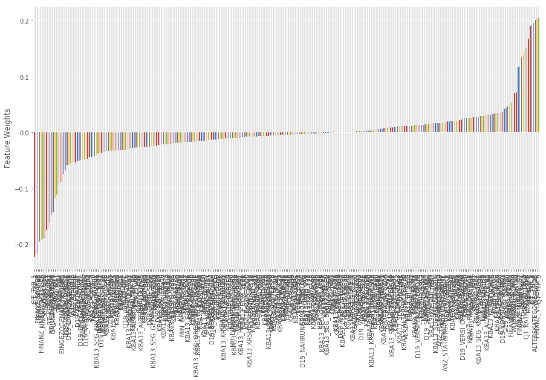

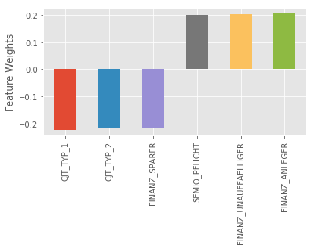

```python
# coordinates of the main variables on the component 3
pca_results(clean_azdias, azdias_pca_155, 3)
```

```python
# List of the 6 features with high cordinates in absolute value in the component 3
L3=['CJT_TYP_1','CJT_TYP_2','FINANZ_SPARER','SEMIO_PFLICHT','FINANZ_UNAUFFAELLIGER','FINANZ_ANLEGER']
map3=levels_infos.loc[levels_infos.Attribute.isin(L3),:]
del map3['Unnamed: 0']
map3
```

|  | Information level | Attribute | Description | Additional notes |
| --- | --- | --- | --- | --- |
| 5 | NaN | FINANZ_SPARER | financial typology: money saver | NaN |
| 7 | NaN | FINANZ_ANLEGER | financial typology: investor | NaN |
| 8 | NaN | FINANZ_UNAUFFAELLIGER | financial typology: unremarkable | NaN |
| 36 | NaN | SEMIO_PFLICHT | affinity indicating in what way the person is ... | NaN |

```python
# List of the 6 features with high cordinates in absolute value in the component 2
L2=['KBA13_SIZE_5','KBA13_KMH_140_210','KBA13_SEG_KLEINWAGEN','KBA13_KMH_180','KBA13_HALTER_25','KBA13_HALTER_20']
map2=levels_infos.loc[levels_infos.Attribute.isin(L2),:]
del map2['Unnamed: 0']
map2
```

|  | Information level | Attribute | Description | Additional notes |
| --- | --- | --- | --- | --- |
| 223 | NaN | KBA13_HALTER_20 | share of car owners below 21 within the PLZ8 | NaN |
| 224 | NaN | KBA13_HALTER_25 | share of car owners between 21 and 25 within t... | NaN |
| 242 | NaN | KBA13_KMH_180 | share of cars with max speed between 110 km/h ... | NaN |
| 244 | NaN | KBA13_KMH_140_210 | share of cars with max speed between 140 and 2... | NaN |
| 278 | NaN | KBA13_SEG_KLEINWAGEN | share of small and very small cars (Ford Fiest... | NaN |

```python
# List of the 6 features with high cordinates in absolute value in the component 1
L1=['PLZ8_ANTG1','KBA13_ANTG1','MOBI_REGIO','KBA13_AUTOQUOTE','MOBI_RASTER','KBA05_AUTOQUOT']
map1=levels_infos.loc[levels_infos.Attribute.isin(L1),:]
del map1['Unnamed: 0']
map1
```

|  | Information level | Attribute | Description | Additional notes |
| --- | --- | --- | --- | --- |
| 97 | Microcell (RR3_ID) | KBA05_AUTOQUOT | share of cars per household | NaN |
| 191 | NaN | MOBI_REGIO | moving patterns | NaN |
| 200 | NaN | KBA13_AUTOQUOTE | share of cars per household within the PLZ8 | NaN |
| 301 | NaN | PLZ8_ANTG1 | number of 1-2 family houses in the PLZ8 | NaN |

##### Interpretation of the first 3 component

Let's now interrupt the main components in the light of the results we have just displayed with the function pca_results

The above results allow us to interpret the main components 1, 2 and 3 from the data. For each of the principal components cited, we took the three variables with positive and highest coordinates on that component and the three variables with negative and highest absolute coordinates on that component. We then linked these variables to the information contained in the descriptive file of the various variables in the data sets provided to us. For unknown reasons, some variables are not present in the descriptive file.

The analysis of the results indicates that:

- `component 1` is mainly related to movement and cars, more precisely to high movement and a greater number of cars.
- `Component 2` is related to the characteristics of the cars owned by customers. These characteristics are essentially the speed and size of the car.
- `Component 3` is more related to finance. It describes people who are investor-minded.

#### Kmeans

> Let start by fitting the 155 pca model on the customer dataset then building an elbow graph function to determine the optimal number of cluster to take in account in the Kmeans alogorithm

```python
## Fit the the azdias_pca_155 to customers data
customers_pca_155,customers_fit_pca_155= azdias_pca_155, azdias_pca_155.fit_transform(clean_customers)
```

```python
#function to fit the kmeans model
def kmeans(data, centers):
    '''
    returns the kmeans score regarding SSE for points to centers
    INPUT:
        data - the dataset you want to fit kmeans to
        center - the number of centers you want (the k value)
    OUTPUT:
        score - the SSE score for the kmeans model fit to the data

    '''
    kmeans = KMeans(centers)
    model = kmeans.fit(data)

    # SSE score for kmeans model
    score = np.abs(model.score(data))
    return score
```

```python
def elbow(pca_fit_data):
    scores = []
    centers = list(range(1,20))
    i = 0
    for center in centers:
        i += 1
        print(i)
        scores.append(kmeans(pca_fit_data, center))

    # Investigate the change in within-cluster distance across number of clusters.
    # Plot the original data with clusters
    plt.plot(centers, scores, linestyle='--', marker='o', color='b')
    plt.ylabel('SSE score')
    plt.xlabel('K')
    plt.title('SSE vs K')
```

```
1
2
3
4
5
6
7
8
9
10
11
12
13
14
15
16
17
18
19
```

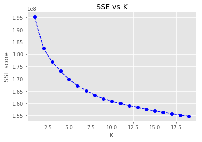

```python
elbow(azdias_fit_pca_155)
```

> According to the resultats displayed in the `elbow` plot I decide to chose **`6 clusters`**.

```python
# Fit the k-means model on the azdias data using the selected clusters number
kmeans = KMeans(6)
azdias_kmodel = kmeans.fit(azdias_fit_pca_155)
azdias_labels = azdias_kmodel.predict(azdias_fit_pca_155)
```

```python
# display the 20 first predicted labels
azdias_labels[:20]
```

```
array([2, 2, 5, 1, 5, 2, 2, 1, 1, 5, 2, 2, 1, 4, 2, 2, 1, 5, 5, 4], dtype=int32)
```

```python
# I use the azdias_kmodel to predict custommers classes
customers_labels=azdias_kmodel.predict(customers_fit_pca_155)
```

```python
# display 20 first custommers classes
customers_labels[:20]
```

```
array([0, 4, 0, 1, 3, 0, 3, 4, 5, 5, 0, 4, 5, 3, 5, 4, 5, 4, 0, 4], dtype=int32)
```

> Now let compare the customers data clusters with the demographics data clusters.

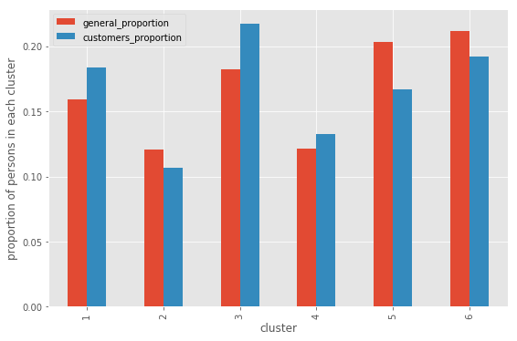

```python
# Compare the proportion of data in each cluster for the customer data to the
# proportion of data in each cluster for the general population.
general_pop = []
customers_pop = []
x = [i+1 for i in range(6)]
for i in range(6):
    general_pop.append((azdias_labels == i).sum()/len(azdias_labels))
    customers_pop.append((customers_labels == i).sum()/len(customers_labels))


df_general = pd.DataFrame({'cluster' : x, 'general_proportion' : general_pop, 'customers_proportion':customers_pop})

df_general.plot(x='cluster', y = ['general_proportion', 'customers_proportion'], kind='bar', figsize=(9,6))
plt.ylabel('proportion of persons in each cluster')
plt.show()
```

> As we can see, the `cluster 3` is the most overrepresented cluster in the customer data. This segment should be the company's target market in the general population

## Part 2: Supervised Learning Model

Now that you've found which parts of the population are more likely to be customers of the mail-order company, it's time to build a prediction model. Each of the rows in the "MAILOUT" data files represents an individual that was targeted for a mailout campaign. Ideally, we should be able to use the demographics information from each individual to decide whether or not it will be worth it to include that person in the campaign.

The "MAILOUT" data has been split into two approximately equal parts, each with almost 43 000 data rows. In this part, you can verify your model with the "TRAIN" partition, which includes a column, "RESPONSE", that states whether or not a person became a customer of the company following the campaign. In the next part, you'll need to create predictions on the "TEST" partition, where the "RESPONSE" column has been withheld.

```python
mailout_train = pd.read_csv('../../data/Term2/capstone/arvato_data/Udacity_MAILOUT_052018_TRAIN.csv', sep=';')
```

```python
# Use the data_cleaning function to perform the cleaning and features engineering
train = data_cleaning(mailout_train, df_unknowns)
```

```python
train.head()
```

|  | LNR | AKT_DAT_KL | ANZ_HAUSHALTE_AKTIV | ANZ_HH_TITEL | ANZ_KINDER | ANZ_PERSONEN | ANZ_STATISTISCHE_HAUSHALTE | ANZ_TITEL | ARBEIT | BALLRAUM | CAMEO_DEUG_2015 | CAMEO_INTL_2015 | CJT_GESAMTTYP | CJT_KATALOGNUTZER | CJT_TYP_1 | CJT_TYP_2 | CJT_TYP_3 | CJT_TYP_4 | CJT_TYP_5 | CJT_TYP_6 | D19_BANKEN_DIREKT | D19_BANKEN_GROSS | D19_BANKEN_LOKAL | D19_BANKEN_REST | D19_BEKLEIDUNG_GEH | D19_BEKLEIDUNG_REST | D19_BILDUNG | D19_BIO_OEKO | D19_BUCH_CD | … |
| --- | --- | --- | --- | --- | --- | --- | --- | --- | --- | --- | --- | --- | --- | --- | --- | --- | --- | --- | --- | --- | --- | --- | --- | --- | --- | --- | --- | --- | --- | --- |
| 0 | 1763.0 | 1.0 | 15.0 | 0.0 | 0.0 | 1.0 | 13.0 | 0.0 | 3.0 | 5.0 | 5 | 34 | 2.0 | 5.0 | 2.0 | 2.0 | 5.0 | 5.0 | 5.0 | 5.0 | 0.0 | 0.0 | 0.0 | 0.0 | 0.0 | 0.0 | 0.0 | 0.0 | 0.0 | … |
| 1 | 1771.0 | 4.0 | 1.0 | 0.0 | 0.0 | 2.0 | 1.0 | 0.0 | 2.0 | 5.0 | 5 | 32 | 2.0 | 2.0 | 2.0 | 2.0 | 4.0 | 3.0 | 5.0 | 4.0 | 0.0 | 0.0 | 3.0 | 0.0 | 0.0 | 6.0 | 0.0 | 0.0 | 0.0 | … |
| 2 | 1776.0 | 1.0 | 0.0 | NaN | 0.0 | 0.0 | 1.0 | 0.0 | 4.0 | 1.0 | 2 | 14 | 4.0 | 5.0 | 1.0 | 1.0 | 5.0 | 5.0 | 5.0 | 5.0 | 0.0 | 0.0 | 0.0 | 5.0 | 0.0 | 0.0 | 0.0 | 0.0 | 0.0 | … |
| 3 | 1460.0 | 1.0 | 4.0 | 0.0 | 0.0 | 2.0 | 4.0 | 0.0 | 4.0 | 2.0 | 2 | 14 | 2.0 | 5.0 | 2.0 | 2.0 | 5.0 | 5.0 | 5.0 | 4.0 | 0.0 | 0.0 | 0.0 | 0.0 | 0.0 | 6.0 | 0.0 | 0.0 | 6.0 | … |
| 4 | 1783.0 | 1.0 | 53.0 | 0.0 | 0.0 | 1.0 | 44.0 | 0.0 | 3.0 | 4.0 | 7 | 41 | 6.0 | 5.0 | 1.0 | 2.0 | 5.0 | 5.0 | 5.0 | 5.0 | 0.0 | 0.0 | 0.0 | 0.0 | 5.0 | 0.0 | 7.0 | 0.0 | 0.0 | … |

```python
train_y=train['RESPONSE']
train_x=train.loc[:, train.columns != 'RESPONSE']
print(f'shape of the train target: {train_y.shape} \nshape of train_x: {train_x.shape}')
```

```
shape of the train target: (33931,)
shape of train_x: (33931, 312)
```

```python
count=train_y.value_counts()
prop_0= count[0]/train_y.shape[0]
prop_1= count[1]/train_y.shape[0]
print(f'The proportion of 0 class is :  {prop_0}\nThe proportion of 1 class is:  {prop_1}')
```

```
The proportion of 0 class is :  0.9876514102148478
The proportion of 1 class is:  0.012348589785152221
```

> We are in front of an imbalanced classification problem. The distribution accros the two class is not equal That's why the choice of the `AUC` as better suited here compared to others such as the `accuracy`. For more details see [David S. Batista](http://www.davidsbatista.net/blog/2018/08/19/NLP_Metrics/) post

```python
# Remove the three columns containing 'X' and 'XX'
for col in ['CAMEO_DEUG_2015','CAMEO_INTL_2015','EINGEFUEGT_AM']:
    if col in train_x.columns:
        del train_x[col]
```

```python
## Impute missing value
imputer = Imputer(strategy='mean')
train_X = pd.DataFrame(imputer.fit_transform(train_x), columns = train_x.columns)
train_X.head()
```

|  | LNR | AKT_DAT_KL | ANZ_HAUSHALTE_AKTIV | ANZ_HH_TITEL | ANZ_KINDER | ANZ_PERSONEN | ANZ_STATISTISCHE_HAUSHALTE | ANZ_TITEL | ARBEIT | BALLRAUM | CJT_GESAMTTYP | CJT_KATALOGNUTZER | CJT_TYP_1 | CJT_TYP_2 | CJT_TYP_3 | CJT_TYP_4 | CJT_TYP_5 | CJT_TYP_6 | D19_BANKEN_DIREKT | D19_BANKEN_GROSS | D19_BANKEN_LOKAL | D19_BANKEN_REST | D19_BEKLEIDUNG_GEH | D19_BEKLEIDUNG_REST | D19_BILDUNG | D19_BIO_OEKO | D19_BUCH_CD | D19_DIGIT_SERV | D19_DROGERIEARTIKEL | … |
| --- | --- | --- | --- | --- | --- | --- | --- | --- | --- | --- | --- | --- | --- | --- | --- | --- | --- | --- | --- | --- | --- | --- | --- | --- | --- | --- | --- | --- | --- | --- |
| 0 | 1763.0 | 1.0 | 15.0 | 0.000000 | 0.0 | 1.0 | 13.0 | 0.0 | 3.0 | 5.0 | 2.0 | 5.0 | 2.0 | 2.0 | 5.0 | 5.0 | 5.0 | 5.0 | 0.0 | 0.0 | 0.0 | 0.0 | 0.0 | 0.0 | 0.0 | 0.0 | 0.0 | 0.0 | 0.0 | … |
| 1 | 1771.0 | 4.0 | 1.0 | 0.000000 | 0.0 | 2.0 | 1.0 | 0.0 | 2.0 | 5.0 | 2.0 | 2.0 | 2.0 | 2.0 | 4.0 | 3.0 | 5.0 | 4.0 | 0.0 | 0.0 | 3.0 | 0.0 | 0.0 | 6.0 | 0.0 | 0.0 | 0.0 | 0.0 | 6.0 | … |
| 2 | 1776.0 | 1.0 | 0.0 | 0.048078 | 0.0 | 0.0 | 1.0 | 0.0 | 4.0 | 1.0 | 4.0 | 5.0 | 1.0 | 1.0 | 5.0 | 5.0 | 5.0 | 5.0 | 0.0 | 0.0 | 0.0 | 5.0 | 0.0 | 0.0 | 0.0 | 0.0 | 0.0 | 0.0 | 0.0 | … |
| 3 | 1460.0 | 1.0 | 4.0 | 0.000000 | 0.0 | 2.0 | 4.0 | 0.0 | 4.0 | 2.0 | 2.0 | 5.0 | 2.0 | 2.0 | 5.0 | 5.0 | 5.0 | 4.0 | 0.0 | 0.0 | 0.0 | 0.0 | 0.0 | 6.0 | 0.0 | 0.0 | 6.0 | 0.0 | 0.0 | … |
| 4 | 1783.0 | 1.0 | 53.0 | 0.000000 | 0.0 | 1.0 | 44.0 | 0.0 | 3.0 | 4.0 | 6.0 | 5.0 | 1.0 | 2.0 | 5.0 | 5.0 | 5.0 | 5.0 | 0.0 | 0.0 | 0.0 | 0.0 | 5.0 | 0.0 | 7.0 | 0.0 | 0.0 | 0.0 | 0.0 | … |

```python
# scaling features
scaler = StandardScaler()
train_XX = pd.DataFrame(scaler.fit_transform(train_X), columns = train_X.columns)
train_XX.head()
print()
print(train_XX.shape)
```

```
(33931, 309)
```

```python
def supervised_classifier(clf, param_grid, X=train_XX, y=train_y):
    """
    Fit a classifier using GridSearchCV and calculates ROC AUC

    INPUT:
    - clf (model): classifier to fit
    - param_grid (dict): classifier parameters used with GridSearchCV
    - X (DataFrame): features of the training dataframe
    - y (DataFrame): labels of the training dataframe

    OUTPUT:
    - classifier: fitted classifier
    - prints elapsed time and ROX AUC
    """

    # cv uses StratifiedKFold
    # scoring roc_auc available as parameter

    start = time.time()
    grid = GridSearchCV(estimator=clf, param_grid=param_grid, scoring='roc_auc', cv=10)
    grid.fit(X, y)
    print('Time', (time.time()- start), 'seconds')

    print(grid.best_score_)

    return grid.best_estimator_
```

#### Logistic regression

> I will begin with a logistic regression

```python
logistic_model = LogisticRegression(random_state=10, solver='lbfgs', class_weight={0: 0.98, 1: 0.012})
print(supervised_classifier(logistic_model,{}))
```

[output not shown]

#### Random Forest

```python
rf_model= RandomForestClassifier()

print(supervised_classifier(rf_model,{}))
```

[output not shown]

#### Adaboost classifier

```python
adaBoost_model = AdaBoostClassifier()
print(supervised_classifier(adaBoost_model, {}))
```

```
Time 146.25855922698975 seconds
0.688883387635
AdaBoostClassifier(algorithm='SAMME.R', base_estimator=None,
          learning_rate=1.0, n_estimators=50, random_state=None)
```

#### Gradient boosting classifier

```python
gb_model = GradientBoostingClassifier()
print(supervised_classifier(gb_model, {}))
```

```
Time 393.4369041919708 seconds
0.700244118201
GradientBoostingClassifier(criterion='friedman_mse', init=None,
              learning_rate=0.1, loss='deviance', max_depth=3,
              max_features=None, max_leaf_nodes=None,
              min_impurity_decrease=0.0, min_impurity_split=None,
              min_samples_leaf=1, min_samples_split=2,
              min_weight_fraction_leaf=0.0, n_estimators=100,
              presort='auto', random_state=None, subsample=1.0, verbose=0,
              warm_start=False)
```

#### SVM classifier

```python
svc_model = LinearSVC(loss='hinge')
print(supervised_classifier(svc_model, {}))
```

```
Time 401.3666834831238 seconds
0.494935695079
LinearSVC(C=1.0, class_weight=None, dual=True, fit_intercept=True,
     intercept_scaling=1, loss='hinge', max_iter=1000, multi_class='ovr',
     penalty='l2', random_state=None, tol=0.0001, verbose=0)
```

#### Stochastic Gradient Descent **`SGDClassifier`**

```python
SGD_model=SGDClassifier(loss='hinge')
print(supervised_classifier(SGD_model, {}))
```

```
Time 3.358182907104492 seconds
0.633240257345
SGDClassifier(alpha=0.0001, average=False, class_weight=None, epsilon=0.1,
       eta0=0.0, fit_intercept=True, l1_ratio=0.15,
       learning_rate='optimal', loss='hinge', max_iter=None, n_iter=None,
       n_jobs=1, penalty='l2', power_t=0.5, random_state=None,
       shuffle=True, tol=None, verbose=0, warm_start=False)
```

#### Extreme gradient boosting (XGboost)

> I first install the xgboost package. Then I use it paying attention to set the objective parameter to `'binary:logistic'`.

```python
X_train, X_val, y_train, y_val = train_test_split(train_XX, train_y, stratify=train_y, test_size=0.3, random_state=12)
```

```python
xg_cl = xgb.XGBClassifier(objective='binary:logistic', n_estimators=50, seed=123)
xg_cl.fit(X_train,y_train)
```

```
XGBClassifier(base_score=0.5, booster=None, colsample_bylevel=1,
       colsample_bynode=1, colsample_bytree=1, gamma=0, gpu_id=-1,
       importance_type='gain', interaction_constraints=None,
       learning_rate=0.300000012, max_delta_step=0, max_depth=6,
       min_child_weight=1, missing=nan, monotone_constraints=None,
       n_estimators=50, n_jobs=0, num_parallel_tree=1,
       objective='binary:logistic', random_state=123, reg_alpha=0,
       reg_lambda=1, scale_pos_weight=1, seed=123, subsample=1,
       tree_method=None, validate_parameters=False, verbosity=None)
```

```python
clf = xgb.XGBClassifier(n_estimators=10000)
eval_set  = [(X_train,y_train), (X_val,y_val)]
clf.fit(X_train, y_train, eval_set=eval_set, eval_metric="auc", early_stopping_rounds=30)
```

```
Multiple eval metrics have been passed: 'validation_1-auc' will be used for early stopping.

Will train until validation_1-auc hasn't improved in 30 rounds.
Stopping. Best iteration:
```

```
XGBClassifier(base_score=0.5, booster=None, colsample_bylevel=1,
       colsample_bynode=1, colsample_bytree=1, gamma=0, gpu_id=-1,
       importance_type='gain', interaction_constraints=None,
       learning_rate=0.300000012, max_delta_step=0, max_depth=6,
       min_child_weight=1, missing=nan, monotone_constraints=None,
       n_estimators=10000, n_jobs=0, num_parallel_tree=1,
       objective='binary:logistic', random_state=0, reg_alpha=0,
       reg_lambda=1, scale_pos_weight=1, subsample=1, tree_method=None,
       validate_parameters=False, verbosity=None)
```

```python
dtrain = xgb.DMatrix(X_train, y_train)
dvalid = xgb.DMatrix(X_val, y_val)
params = {
        "objective": "binary:logistic",
        "booster" : "gbtree",
        "eval_metric": "auc",
        "eta": 0.1,
        "tree_method": 'exact',
        "max_depth": 6,
        "subsample": 1,
        "colsample_bytree": 1,
        "silent": 1,
        "min_chil_weight":1,
        "seed": 123,
    }
num_boost_round = 500
early_stopping_rounds = 100
test_size = 0.3
watchlist = [(dtrain, 'train'), (dvalid, 'eval')]
gbm = xgb.train(params, dtrain, num_boost_round, evals=watchlist, early_stopping_rounds=early_stopping_rounds, verbose_eval=True)
```

```
Multiple eval metrics have been passed: 'eval-auc' will be used for early stopping.

Will train until eval-auc hasn't improved in 100 rounds.
Stopping. Best iteration:
```

```python
pred = gbm.predict(xgb.DMatrix(X_val), ntree_limit=gbm.best_iteration+1)
fpr, tpr, _ = roc_curve(y_val, pred)
roc_auc = auc(fpr, tpr)
roc_auc
```

```
0.71679320557876358
```

#### Summary : Results of the differents models

| Models | ROC AUC |
| --- | --- |
| Logistic regression | 0.66 |
| Random Forest | 0.596 |
| Adaboost classifier | 0.689 |
| Gradient boosting classifier(sklearn) | 0.70 |
| SVM | 0.495 |
| Stochastic Gradient Descent SGDClassifier | 0.63 |
| Extreme gradient boosting (XGboost) | 0.717 |

> I will try to tune the hyperparameters of the xgboost in particular its XGBClassifier variant present in sklearn in order to take advantage of sklearn's GridShearCV tuning method . Then I will use the best founded parameters for the final prediction as it as the best ROC AUC score.

```python
tuned_parameters = {'learning_rate': [0.4,0.5],
        'max_depth': [6,7]
    }

fit_params={
    "eval_set":[(X_train, y_train),(X_val,y_val)],
    "eval_metric": 'auc',
    "early_stopping_rounds":100,
    "verbose":True
}



model = xgb.XGBClassifier( objective ='binary:logistic',  seed=0,n_estimators=1000 )
gridsearch = GridSearchCV(model, tuned_parameters, verbose=999999 ,
    scoring='roc_auc',
    fit_params=fit_params
    )
gridsearch.fit(train_XX, train_y)

print (gridsearch.best_params_)
print (gridsearch.best_score_)
```

```
Fitting 3 folds for each of 4 candidates, totalling 12 fits
[CV] learning_rate=0.4, max_depth=6 ..................................
Multiple eval metrics have been passed: 'validation_1-auc' will be used for early stopping.

Will train until validation_1-auc hasn't improved in 100 rounds.
Stopping. Best iteration:

[CV]  learning_rate=0.4, max_depth=6, score=0.6475970945176925, total= 1.8min
[Parallel(n_jobs=1)]: Done   1 out of   1 | elapsed:  1.9min remaining:    0.0s
[CV] learning_rate=0.4, max_depth=6 ..................................
Multiple eval metrics have been passed: 'validation_1-auc' will be used for early stopping.

Will train until validation_1-auc hasn't improved in 100 rounds.
Stopping. Best iteration:

[CV]  learning_rate=0.4, max_depth=6, score=0.6829935931045947, total= 1.0min
[Parallel(n_jobs=1)]: Done   2 out of   2 | elapsed:  2.9min remaining:    0.0s
[CV] learning_rate=0.4, max_depth=6 ..................................
Multiple eval metrics have been passed: 'validation_1-auc' will be used for early stopping.

Will train until validation_1-auc hasn't improved in 100 rounds.
Stopping. Best iteration:

[CV]  learning_rate=0.4, max_depth=6, score=0.664789421819751, total= 1.8min
[Parallel(n_jobs=1)]: Done   3 out of   3 | elapsed:  4.7min remaining:    0.0s
[CV] learning_rate=0.4, max_depth=7 ..................................
Multiple eval metrics have been passed: 'validation_1-auc' will be used for early stopping.

Will train until validation_1-auc hasn't improved in 100 rounds.
Stopping. Best iteration:

[CV]  learning_rate=0.4, max_depth=7, score=0.6621465657250278, total= 1.0min
[Parallel(n_jobs=1)]: Done   4 out of   4 | elapsed:  5.7min remaining:    0.0s
[CV] learning_rate=0.4, max_depth=7 ..................................
Multiple eval metrics have been passed: 'validation_1-auc' will be used for early stopping.

Will train until validation_1-auc hasn't improved in 100 rounds.
Stopping. Best iteration:

[CV]  learning_rate=0.4, max_depth=7, score=0.7114058084069721, total=  59.8s
```

[output cut: 50 more lines]

```
Multiple eval metrics have been passed: 'validation_1-auc' will be used for early stopping.

Will train until validation_1-auc hasn't improved in 100 rounds.
Stopping. Best iteration:

[CV]  learning_rate=0.5, max_depth=7, score=0.6845906622955887, total= 1.7min
[Parallel(n_jobs=1)]: Done  12 out of  12 | elapsed: 16.6min remaining:    0.0s
[Parallel(n_jobs=1)]: Done  12 out of  12 | elapsed: 16.6min finished
Multiple eval metrics have been passed: 'validation_1-auc' will be used for early stopping.

Will train until validation_1-auc hasn't improved in 100 rounds.
Stopping. Best iteration:

{'learning_rate': 0.4, 'max_depth': 7}
0.683792932197
```

> The parameters tuning gives `'learning_rate': 0.4` and `'max_depth': 7` as the optimal parameters to use. I will train the final xgboost model with theses parameters

```python
## Optimal training model
optim_model = xgb.XGBClassifier(objective ='binary:logistic',  n_estimators=10000, seed=0,max_depth=7,learning_rate=0.4)
eval_set  = [(X_train,y_train), (X_val,y_val)]
optim_model.fit(X_train, y_train, eval_set=eval_set, eval_metric="auc", early_stopping_rounds=30)
```

```
Multiple eval metrics have been passed: 'validation_1-auc' will be used for early stopping.

Will train until validation_1-auc hasn't improved in 30 rounds.
Stopping. Best iteration:
```

```
XGBClassifier(base_score=0.5, booster=None, colsample_bylevel=1,
       colsample_bynode=1, colsample_bytree=1, gamma=0, gpu_id=-1,
       importance_type='gain', interaction_constraints=None,
       learning_rate=0.4, max_delta_step=0, max_depth=7,
       min_child_weight=1, missing=nan, monotone_constraints=None,
       n_estimators=10000, n_jobs=0, num_parallel_tree=1,
       objective='binary:logistic', random_state=0, reg_alpha=0,
       reg_lambda=1, scale_pos_weight=1, seed=0, subsample=1,
       tree_method=None, validate_parameters=False, verbosity=None)
```

Parameter tuning did not allow a substantial gain in AUC. We go from `0.717` AUC without tuning to `0.715` AUC with tuning. However, the optimal parameters found with tuning are interesting in that they avoid overfitting. Indeed we can see that with parameter tuning the AUC deviation between the training dataset and the validation dataset is very small(**training AUC: 0.71874**, **validation AUC:0.71569**). On the other hand, this difference is a little higher without the tuning (**training AUC: 0.94674**, **validation AUC:0.71646**)

## Part 3: Kaggle Competition

Now that you've created a model to predict which individuals are most likely to respond to a mailout campaign, it's time to test that model in competition through Kaggle. If you click on the link [here](http://www.kaggle.com/t/21e6d45d4c574c7fa2d868f0e8c83140), you'll be taken to the competition page where, if you have a Kaggle account, you can enter. If you're one of the top performers, you may have the chance to be contacted by a hiring manager from Arvato or Bertelsmann for an interview!

Your entry to the competition should be a CSV file with two columns. The first column should be a copy of "LNR", which acts as an ID number for each individual in the "TEST" partition. The second column, "RESPONSE", should be some measure of how likely each individual became a customer – this might not be a straightforward probability. As you should have found in Part 2, there is a large output class imbalance, where most individuals did not respond to the mailout. Thus, predicting individual classes and using accuracy does not seem to be an appropriate performance evaluation method. Instead, the competition will be using AUC to evaluate performance. The exact values of the "RESPONSE" column do not matter as much: only that the higher values try to capture as many of the actual customers as possible, early in the ROC curve sweep.

```python
mailout_test = pd.read_csv('../../data/Term2/capstone/arvato_data/Udacity_MAILOUT_052018_TEST.csv', sep=';')
mailout_test.shape
```

```
(42833, 366)
```

```python
mailout_test.head()
```

|  | LNR | AGER_TYP | AKT_DAT_KL | ALTER_HH | ALTER_KIND1 | ALTER_KIND2 | ALTER_KIND3 | ALTER_KIND4 | ALTERSKATEGORIE_FEIN | ANZ_HAUSHALTE_AKTIV | ANZ_HH_TITEL | ANZ_KINDER | ANZ_PERSONEN | ANZ_STATISTISCHE_HAUSHALTE | ANZ_TITEL | ARBEIT | BALLRAUM | CAMEO_DEU_2015 | CAMEO_DEUG_2015 | CAMEO_INTL_2015 | CJT_GESAMTTYP | CJT_KATALOGNUTZER | CJT_TYP_1 | CJT_TYP_2 | CJT_TYP_3 | CJT_TYP_4 | CJT_TYP_5 | CJT_TYP_6 | D19_BANKEN_ANZ_12 | … |
| --- | --- | --- | --- | --- | --- | --- | --- | --- | --- | --- | --- | --- | --- | --- | --- | --- | --- | --- | --- | --- | --- | --- | --- | --- | --- | --- | --- | --- | --- | --- |
| 0 | 1754 | 2 | 1.0 | 7.0 | NaN | NaN | NaN | NaN | 6.0 | 2.0 | 0.0 | 0.0 | 2.0 | 2.0 | 0.0 | 3.0 | 6.0 | 2B | 2 | 13 | 5.0 | 5.0 | 1.0 | 2.0 | 5.0 | 5.0 | 5.0 | 5.0 | 0 | … |
| 1 | 1770 | -1 | 1.0 | 0.0 | NaN | NaN | NaN | NaN | 0.0 | 20.0 | 0.0 | 0.0 | 1.0 | 21.0 | 0.0 | 4.0 | 7.0 | 5A | 5 | 31 | 1.0 | 5.0 | 2.0 | 2.0 | 5.0 | 5.0 | 4.0 | 5.0 | 0 | … |
| 2 | 1465 | 2 | 9.0 | 16.0 | NaN | NaN | NaN | NaN | 11.0 | 2.0 | 0.0 | 0.0 | 4.0 | 2.0 | 0.0 | 4.0 | 1.0 | 7A | 7 | 41 | 2.0 | 5.0 | 2.0 | 2.0 | 5.0 | 5.0 | 5.0 | 5.0 | 0 | … |
| 3 | 1470 | -1 | 7.0 | 0.0 | NaN | NaN | NaN | NaN | 0.0 | 1.0 | 0.0 | 0.0 | 0.0 | 1.0 | 0.0 | 4.0 | 1.0 | 2B | 2 | 13 | 4.0 | 5.0 | 2.0 | 1.0 | 5.0 | 5.0 | 5.0 | 5.0 | 0 | … |
| 4 | 1478 | 1 | 1.0 | 21.0 | NaN | NaN | NaN | NaN | 13.0 | 1.0 | 0.0 | 0.0 | 4.0 | 1.0 | 0.0 | 3.0 | 6.0 | 5A | 5 | 31 | 6.0 | 1.0 | 3.0 | 2.0 | 4.0 | 4.0 | 4.0 | 3.0 | 3 | … |

```python
## I define a test data cleaning because here I must notre remove individuals.
# I have to make prediction for all individuals
def test_data_cleaning(df_to_clean, df_vars_unknowns):
    """
    Perform feature trimming, re-encoding, and engineering for demographics
    data

    INPUT:
        df_to_clean: Customer demographics DataFrame
        df_vars_unknowns: Unknowns DataFrame
    OUTPUT: Trimmed and cleaned demographics DataFrame
    """
    for col in df_to_clean.columns:
        if df_to_clean[col].dtype == np.int64:
            df_to_clean[col] = df_to_clean[col].astype(np.float64)

    # convert missing value codes into NaNs, ...
    for row in df_vars_unknowns['Attribute']:
        if row in df_to_clean.columns:
            na_map = df_vars_unknowns.loc[df_vars_unknowns['Attribute'] == row, 'Unknown'].iloc[0]
            na_idx = df_to_clean.loc[:, row].isin(na_map)
            df_to_clean.loc[na_idx, row] = np.NaN
        else:
            continue

    # Remove columns which have more than 20 %  missing values in the azdias dataframe
    columns_to_drop = pd.read_csv('columns_to_drop.csv')
    cols_to_drop    =list(columns_to_drop['columns_to_drop'])
    for col in cols_to_drop:
        if col in df_to_clean.columns:
            del df_to_clean[col]

    # select, re-encode, and engineer column values
    df_to_clean['OST_WEST_KZ'].replace(['W', 'O'], [1, 0], inplace=True)

    cols_to_dummy = list(pd.read_csv('cols_to_dummy.csv').cols_to_dummy)

    for col in cols_to_dummy:
        dummy = pd.get_dummies(df_to_clean[col], prefix = col)
        df_to_clean = pd.concat([df_to_clean, dummy], axis = 1)

    df_to_clean.drop(cols_to_dummy, axis=1, inplace = True)
    return df_to_clean
```

```python
# Test data cleaning
test_clean= test_data_cleaning(mailout_test,df_unknowns)

LNR= test_clean['LNR']
```

```python
# Remove the three columns containing 'X' and 'XX'
for col in ['CAMEO_DEUG_2015','CAMEO_INTL_2015','EINGEFUEGT_AM']:
    if col in test_clean.columns:
        del test_clean[col]
```

```python
# Impute missing values
test_X = pd.DataFrame(imputer.transform(test_clean), columns = test_clean.columns)
test_X.head()
```

|  | LNR | AKT_DAT_KL | ANZ_HAUSHALTE_AKTIV | ANZ_HH_TITEL | ANZ_KINDER | ANZ_PERSONEN | ANZ_STATISTISCHE_HAUSHALTE | ANZ_TITEL | ARBEIT | BALLRAUM | CJT_GESAMTTYP | CJT_KATALOGNUTZER | CJT_TYP_1 | CJT_TYP_2 | CJT_TYP_3 | CJT_TYP_4 | CJT_TYP_5 | CJT_TYP_6 | D19_BANKEN_DIREKT | D19_BANKEN_GROSS | D19_BANKEN_LOKAL | D19_BANKEN_REST | D19_BEKLEIDUNG_GEH | D19_BEKLEIDUNG_REST | D19_BILDUNG | D19_BIO_OEKO | D19_BUCH_CD | D19_DIGIT_SERV | D19_DROGERIEARTIKEL | … |
| --- | --- | --- | --- | --- | --- | --- | --- | --- | --- | --- | --- | --- | --- | --- | --- | --- | --- | --- | --- | --- | --- | --- | --- | --- | --- | --- | --- | --- | --- | --- |
| 0 | 1754.0 | 1.0 | 2.0 | 0.0 | 0.0 | 2.0 | 2.0 | 0.0 | 3.0 | 6.0 | 5.0 | 5.0 | 1.0 | 2.0 | 5.0 | 5.0 | 5.0 | 5.0 | 0.0 | 0.0 | 0.0 | 0.0 | 3.0 | 6.0 | 0.0 | 0.0 | 0.0 | 0.0 | 6.0 | … |
| 1 | 1770.0 | 1.0 | 20.0 | 0.0 | 0.0 | 1.0 | 21.0 | 0.0 | 4.0 | 7.0 | 1.0 | 5.0 | 2.0 | 2.0 | 5.0 | 5.0 | 4.0 | 5.0 | 0.0 | 0.0 | 0.0 | 0.0 | 0.0 | 6.0 | 0.0 | 0.0 | 7.0 | 0.0 | 0.0 | … |
| 2 | 1465.0 | 9.0 | 2.0 | 0.0 | 0.0 | 4.0 | 2.0 | 0.0 | 4.0 | 1.0 | 2.0 | 5.0 | 2.0 | 2.0 | 5.0 | 5.0 | 5.0 | 5.0 | 0.0 | 0.0 | 0.0 | 0.0 | 0.0 | 0.0 | 0.0 | 0.0 | 6.0 | 0.0 | 0.0 | … |
| 3 | 1470.0 | 7.0 | 1.0 | 0.0 | 0.0 | 0.0 | 1.0 | 0.0 | 4.0 | 1.0 | 4.0 | 5.0 | 2.0 | 1.0 | 5.0 | 5.0 | 5.0 | 5.0 | 0.0 | 0.0 | 0.0 | 0.0 | 0.0 | 0.0 | 0.0 | 0.0 | 0.0 | 0.0 | 0.0 | … |
| 4 | 1478.0 | 1.0 | 1.0 | 0.0 | 0.0 | 4.0 | 1.0 | 0.0 | 3.0 | 6.0 | 6.0 | 1.0 | 3.0 | 2.0 | 4.0 | 4.0 | 4.0 | 3.0 | 2.0 | 2.0 | 0.0 | 6.0 | 6.0 | 6.0 | 5.0 | 0.0 | 3.0 | 0.0 | 2.0 | … |

```python
# Scaling
test_XX = pd.DataFrame(scaler.transform(test_X), columns = test_X.columns)
test_XX.head()
```

|  | LNR | AKT_DAT_KL | ANZ_HAUSHALTE_AKTIV | ANZ_HH_TITEL | ANZ_KINDER | ANZ_PERSONEN | ANZ_STATISTISCHE_HAUSHALTE | ANZ_TITEL | ARBEIT | BALLRAUM | CJT_GESAMTTYP | CJT_KATALOGNUTZER | CJT_TYP_1 | CJT_TYP_2 | CJT_TYP_3 | CJT_TYP_4 | CJT_TYP_5 | CJT_TYP_6 | D19_BANKEN_DIREKT | D19_BANKEN_GROSS | D19_BANKEN_LOKAL | D19_BANKEN_REST | D19_BEKLEIDUNG_GEH | D19_BEKLEIDUNG_REST | D19_BILDUNG | D19_BIO_OEKO | D19_BUCH_CD | D19_DIGIT_SERV | D19_DROGERIEARTIKEL | … |
| --- | --- | --- | --- | --- | --- | --- | --- | --- | --- | --- | --- | --- | --- | --- | --- | --- | --- | --- | --- | --- | --- | --- | --- | --- | --- | --- | --- | --- | --- | --- |
| 0 | -1.651325 | -0.291892 | -0.306990 | -0.130854 | -0.221209 | -0.024173 | -0.295013 | -0.091527 | -0.042065 | 0.793361 | 1.404993 | 0.873202 | -1.142786 | 0.142217 | 0.628161 | 0.649180 | 0.635214 | 0.645182 | -0.428600 | -0.342055 | -0.142965 | -0.290773 | 0.960778 | 1.451689 | -0.509085 | -0.375364 | -1.062426 | -0.214552 | 2.717766 | … |
| 1 | -1.650683 | -0.291892 | 0.900733 | -0.130854 | -0.221209 | -0.757150 | 1.067830 | -0.091527 | 0.926806 | 1.249238 | -1.246746 | 0.873202 | -0.140321 | 0.142217 | 0.628161 | 0.649180 | -0.377044 | 0.645182 | -0.428600 | -0.342055 | -0.142965 | -0.290773 | -0.465280 | 1.451689 | -0.509085 | -0.375364 | 1.391997 | -0.214552 | -0.426658 | … |
| 2 | -1.662922 | 4.436201 | -0.306990 | -0.130854 | -0.221209 | 1.441783 | -0.295013 | -0.091527 | 0.926806 | -1.486020 | -0.583811 | 0.873202 | -0.140321 | 0.142217 | 0.628161 | 0.649180 | 0.635214 | 0.645182 | -0.428600 | -0.342055 | -0.142965 | -0.290773 | -0.465280 | -0.715466 | -0.509085 | -0.375364 | 1.041365 | -0.214552 | -0.426658 | … |
| 3 | -1.662722 | 3.254178 | -0.374085 | -0.130854 | -0.221209 | -1.490128 | -0.366742 | -0.091527 | 0.926806 | -1.486020 | 0.742058 | 0.873202 | -0.140321 | -0.903122 | 0.628161 | 0.649180 | 0.635214 | 0.645182 | -0.428600 | -0.342055 | -0.142965 | -0.290773 | -0.465280 | -0.715466 | -0.509085 | -0.375364 | -1.062426 | -0.214552 | -0.426658 | … |
| 4 | -1.662401 | -0.291892 | -0.374085 | -0.130854 | -0.221209 | 1.441783 | -0.366742 | -0.091527 | -0.042065 | 0.793361 | 2.067928 | -1.855211 | 0.862145 | 0.142217 | -0.414856 | -0.254692 | -0.377044 | -1.322746 | 0.592882 | 0.904389 | -0.142965 | 3.625950 | 2.386835 | 1.451689 | 1.579286 | -0.375364 | -0.010530 | -0.214552 | 0.621483 | … |

```python
pred_proba= optim_model.predict_proba(
                                    test_XX,
                                    ntree_limit = optim_model.best_ntree_limit
                                )
```

```python
pred_proba[:15]
```

```
array([[ 0.78921902,  0.21078095],
       [ 0.78921902,  0.21078095],
       [ 0.79670972,  0.2032903 ],
       [ 0.79670972,  0.2032903 ],
       [ 0.79320455,  0.20679545],
       [ 0.79670972,  0.2032903 ],
       [ 0.78921902,  0.21078095],
       [ 0.64078093,  0.3592191 ],
       [ 0.78921902,  0.21078095],
       [ 0.79320455,  0.20679545],
       [ 0.79670972,  0.2032903 ],
       [ 0.78458071,  0.21541929],
       [ 0.79320455,  0.20679545],
       [ 0.78921902,  0.21078095],
       [ 0.78921902,  0.21078095]], dtype=float32)
```

#### Kaggle submission

```python
kaggle_submission = pd.DataFrame({'LNR':LNR.astype(np.int32), 'RESPONSE':pred_proba[:, 1]})
kaggle_submission.to_csv('kaggle.csv', index = False)
kaggle_submission.head()
```

|  | LNR | RESPONSE |
| --- | --- | --- |
| 0 | 1754 | 0.210781 |
| 1 | 1770 | 0.210781 |
| 2 | 1465 | 0.203290 |
| 3 | 1470 | 0.203290 |
| 4 | 1478 | 0.206795 |